# About the JavaScript reference

The JavaScript reference serves as a repository of facts about the JavaScript language. The entire language is described here in detail. As you write JavaScript code, you’ll refer to these pages often (thus the title "JavaScript reference”). If you’re learning JavaScript, or need help understanding some of its capabilities or features, check out the [JavaScript guide](https://developer.mozilla.org/en-US/docs/Web/JavaScript/Guide).

The JavaScript language is intended to be used within some larger environment, be it a browser, server-side scripts, or similar. For the most part, this reference attempts to be environment-agnostic and does not target a web browser environment.

## Where to find JavaScript information

JavaScript documentation of core language features (pure [ECMAScript](https://developer.mozilla.org/en-US/docs/Web/JavaScript/Language_Resources), for the most part) includes the following:

- The [JavaScript guide](https://developer.mozilla.org/en-US/docs/Web/JavaScript/Guide)
- The JavaScript reference

If you are new to JavaScript, start with the [guide](https://developer.mozilla.org/en-US/docs/Web/JavaScript/Guide). Once you have a firm grasp of the fundamentals, you can use the reference to get more details on individual objects and language constructs.

## Structure of the reference

In the JavaScript reference you can find the following chapters:

[Standard built-in objects](https://developer.mozilla.org/en-US/docs/Web/JavaScript/Reference/Global_Objects)  
This chapter documents all the JavaScript standard built-in objects, along with their methods and properties.

[Statements and declarations](https://developer.mozilla.org/en-US/docs/Web/JavaScript/Reference/Statements)  
JavaScript applications consist of statements with an appropriate syntax. A single statement may span multiple lines. Multiple statements may occur on a single line if each statement is separated by a semicolon. This isn’t a keyword, but a group of keywords.

[Expressions and operators](https://developer.mozilla.org/en-US/docs/Web/JavaScript/Reference/Operators)  
This chapter documents all the JavaScript language operators, expressions and keywords.

Functions  
Chapter about JavaScript functions.

Classes  
Chapter about JavaScript classes introduced in ECMAScript 2015.

Errors  
Chapter about specific errors, exceptions and warnings thrown by JavaScript.

[New in JavaScript](https://developer.mozilla.org/en-US/docs/Web/JavaScript/New_in_JavaScript)  
Chapter about JavaScript version history.

### More reference pages

- [Deprecated and obsolete features](https://developer.mozilla.org/en-US/docs/Web/JavaScript/Reference/Deprecated_and_obsolete_features)
- Lexical grammar
- [Data types and data structures](https://developer.mozilla.org/en-US/docs/Web/JavaScript/Data_structures)

About" About

# Math.abs()

The `Math.abs()` function returns the absolute value of a number. That is, it returns `x` if `x` is positive or zero, and the negation of `x` if `x` is negative.

## Syntax

```
Math.abs(x)
```

### Parameters

`x`  
A number.

### Return value

The absolute value of the given number.

## Description

Because `abs()` is a static method of `Math`, you always use it as `Math.abs()`, rather than as a method of a `Math` object you created (`Math` is not a constructor).

## Examples

### Behavior of Math.abs()

Passing an empty object, an array with more than one member, a non-numeric string or `undefined`/empty variable returns `NaN`. Passing `null`, an empty string or an empty array returns 0.

```
Math.abs('-1');     // 1
Math.abs(-2);       // 2
Math.abs(null);     // 0
Math.abs('');       // 0
Math.abs([]);       // 0
Math.abs([2]);      // 2
Math.abs([1,2]);    // NaN
Math.abs({});       // NaN
Math.abs('string'); // NaN
Math.abs();         // NaN
```

## Specifications

| Specification |
| --- |
| [ECMAScript (ECMA-262)](https://tc39.es/ecma262/#sec-math.abs) The definition of ‘Math.abs’ in that specification. |

`abs`

1

12

1

3

3

1

1

18

4

10.1

1

Global_Objects/Math/abs" Global_Objects/Math/abs

# Math.acos()

The `Math.acos()` function returns the arccosine (in radians) of a number, that is

∀*x* ∈ [ − 1; 1], `Math.acos` `` (``x``) `` = arccos (*x*) = the unique *y* ∈ [0; *π*] such that cos (*y*) = *x*

## Syntax

```
Math.acos(x)
```

### Parameters

`x`  
A number representing a cosine, where `x` is between `-1` and `1`.

### Return value

The arccosine (angle in radians) of the given number if it’s between `-1` and `1`; otherwise, `NaN`.

## Description

The `Math.acos()` method returns a numeric value between 0 and π radians for `x` between -1 and 1. If the value of `x` is outside this range, it returns `NaN`.

Because `acos()` is a static method of `Math`, you always use it as `Math.acos()`, rather than as a method of a `Math` object you created (`Math` is not a constructor).

## Examples

### Using Math.acos()

```
Math.acos(-2);  // NaN
Math.acos(-1);  // 3.141592653589793
Math.acos(0);   // 1.5707963267948966
Math.acos(0.5); // 1.0471975511965979
Math.acos(1);   // 0
Math.acos(2);   // NaN
```

For values less than -1 or greater than 1, `Math.acos()` returns `NaN`.

## Specifications

| Specification |
| --- |
| [ECMAScript Language Specification (ECMAScript)](https://tc39.es/ecma262/#sec-math.acos) #sec-math.acos |

`acos`

1

12

1

3

3

1

1

18

4

10.1

1

- `Math.asin()`
- `Math.atan()`
- `Math.atan2()`
- `Math.cos()`
- `Math.sin()`
- `Math.tan()`

Global_Objects/Math/acos" Global_Objects/Math/acos

# Math.acosh()

The `Math.acosh()` function returns the hyperbolic arc-cosine of a number, that is

∀*x* ≥ 1, `Math.acosh` `` (``x``) `` = arcosh (*x*) = the unique *y* ≥ 0 such that cosh (*y*) = *x*

## Syntax

```
Math.acosh(x)
```

### Parameters

`x`  
A number.

### Return value

The hyperbolic arc-cosine of the given number. If the number is less than **1**, `NaN`.

## Description

Because `acosh()` is a static method of `Math`, you always use it as `Math.acosh()`, rather than as a method of a `Math` object you created (`Math` is no constructor).

## Examples

### Using Math.acosh()

```
Math.acosh(-1);  // NaN
Math.acosh(0);   // NaN
Math.acosh(0.5); // NaN
Math.acosh(1);   // 0
Math.acosh(2);   // 1.3169578969248166
```

For values less than 1 `Math.acosh()` returns `NaN`.

## Polyfill

For all *x* ≥ 1, we have $\\operatorname{arcosh}(x) = \\ln\\left( {x + \\sqrt{x^{2} - 1}} \\right)$ and so this can be emulated with the following function:

```
Math.acosh = Math.acosh || function(x) {
  return Math.log(x + Math.sqrt(x * x - 1));
};
```

## Specifications

| Specification |
| --- |
| [ECMAScript Language Specification (ECMAScript)](https://tc39.es/ecma262/#sec-math.acosh) #sec-math.acosh |

`acosh`

38

12

25

No

25

8

38

38

25

25

8

3.0

## See also

- `Math.asinh()`
- `Math.atanh()`
- `Math.cosh()`
- `Math.sinh()`
- `Math.tanh()`

Global_Objects/Math/acosh" Global_Objects/Math/acosh

# Atomics.add()

The static `` Atomics``.add() `` method adds a given value at a given position in the array and returns the old value at that position. This atomic operation guarantees that no other write happens until the modified value is written back.

## Syntax

```
Atomics.add(typedArray, index, value)
```

### Parameters

`typedArray`  
An integer typed array. One of `Int8Array`, `Uint8Array`, `Int16Array`, `Uint16Array`, `Int32Array`, `Uint32Array`, `BigInt64Array`, or `BigUint64Array`.

`index`  
The position in the `typedArray` to add a `value` to.

`value`  
The number to add.

### Return value

The old value at the given position (`typedArray[index]`).

### Exceptions

- Throws a `TypeError`, if `typedArray` is not one of the allowed integer types.
- Throws a `RangeError`, if `index` is out of bounds in the `typedArray`.

## Examples

### Using add()

```
const sab = new SharedArrayBuffer(1024);
const ta = new Uint8Array(sab);

Atomics.add(ta, 0, 12); // returns 0, the old value
Atomics.load(ta, 0); // 12
```

## Specifications

| Specification |
| --- |
| [ECMAScript Language Specification (ECMAScript)](https://tc39.es/ecma262/#sec-atomics.add) #sec-atomics.add |

`add`

68

60-63

Chrome disabled `SharedArrayBuffer` on January 5, 2018 to help reduce the efficacy of [speculative side-channel attacks](https://www.chromium.org/Home/chromium-security/ssca). This was a temporary removal while mitigations were put in place.

79

16-17

Support was removed to mitigate [speculative execution side-channel attacks (Windows blog)](https://blogs.windows.com/msedgedev/2018/01/03/speculative-execution-mitigations-microsoft-edge-internet-explorer).

78

57

Support was disabled by default to mitigate [speculative execution side-channel attacks (Mozilla Security Blog)](https://blog.mozilla.org/security/2018/01/03/mitigations-landing-new-class-timing-attack/).

55-57

46-55

No

No

10.1-11.1

60-63

Chrome disabled `SharedArrayBuffer` on January 5, 2018 to help reduce the efficacy of [speculative side-channel attacks](https://www.chromium.org/Home/chromium-security/ssca). This is intended as a temporary measure until other mitigations are in place.

60-63

Chrome disabled `SharedArrayBuffer` on January 5, 2018 to help reduce the efficacy of [speculative side-channel attacks](https://www.chromium.org/Home/chromium-security/ssca). This is intended as a temporary measure until other mitigations are in place.

57

Support was disabled by default to mitigate [speculative execution side-channel attacks (Mozilla Security Blog)](https://blog.mozilla.org/security/2018/01/03/mitigations-landing-new-class-timing-attack/).

55-57

46-55

No

10.3-11.3

No

Chrome disabled `SharedArrayBuffer` on January 5, 2018 to help reduce the efficacy of [speculative side-channel attacks](https://www.chromium.org/Home/chromium-security/ssca). This is intended as a temporary measure until other mitigations are in place.

## See also

- `Atomics`
- `Atomics.sub()`

Global_Objects/Atomics/add" Global_Objects/Atomics/add

# Addition (+)

The addition operator (`+`) produces the sum of numeric operands or string concatenation.

## Syntax

```
Operator: x + y
```

## Examples

### Numeric addition

```
// Number + Number -> addition
1 + 2 // 3

// Boolean + Number -> addition
true + 1 // 2

// Boolean + Boolean -> addition
false + false // 0
```

### String concatenation

```
// String + String -> concatenation
'foo' + 'bar' // "foobar"

// Number + String -> concatenation
5 + 'foo' // "5foo"

// String + Boolean -> concatenation
'foo' + false // "foofalse"
```

## Specifications

| Specification |
| --- |
| [ECMAScript (ECMA-262)](https://tc39.es/ecma262/#sec-addition-operator-plus) The definition of ‘Addition operator’ in that specification. |

`Addition`

1

12

1

3

3

1

1

18

4

10.1

1

- Subtraction operator
- Division operator
- Multiplication operator
- Remainder operator
- Exponentiation operator
- Increment operator
- Decrement operator
- Unary negation operator
- Unary plus operator

Operators/Addition" Operators/Addition

# AggregateError

The `AggregateError` object represents an error when several errors need to be wrapped in a single error. It is thrown when multiple errors need to be reported by an operation, for example by `Promise.any()`, when all promises passed to it reject.

## Constructor

`AggregateError()`  
Creates a new `AggregateError` object.

## Instance properties

`AggregateError.prototype.message`  
Error message, defaults to `""`.

`AggregateError.prototype.name`  
Error name, defaults to `AggregateError`.

## Examples

### Catching an AggregateError

```
Promise.any([
  Promise.reject(new Error("some error")),
]).catch(e => {
  console.log(e instanceof AggregateError); // true
  console.log(e.message);                   // "All Promises rejected"
  console.log(e.name);                      // "AggregateError"
  console.log(e.errors);                    // [ Error: "some error" ]
});
```

### Creating an AggregateError

```
try {
  throw new AggregateError([
    new Error("some error"),
  ], 'Hello');
} catch (e) {
  console.log(e instanceof AggregateError); // true
  console.log(e.message);                   // "Hello"
  console.log(e.name);                      // "AggregateError"
  console.log(e.errors);                    // [ Error: "some error" ]
}
```

## Specifications

| Specification |
| --- |
| [ECMAScript Language Specification (ECMAScript)](https://tc39.es/ecma262/#sec-aggregate-error-objects) #sec-aggregate-error-objects |

`AggregateError`

85

85

79

No

No

14

85

85

79

No

14

No

`AggregateError`

85

85

79

No

No

14

85

85

79

No

14

No

## See also

- `Error`
- `Promise.any`

Global_Objects/AggregateError" Global_Objects/AggregateError

# Promise.all()

The `Promise.all()` method takes an iterable of promises as an input, and returns a single `Promise` that resolves to an array of the results of the input promises. This returned promise will resolve when all of the input’s promises have resolved, or if the input iterable contains no promises. It rejects immediately upon any of the input promises rejecting or non-promises throwing an error, and will reject with this first rejection message / error.

## Syntax

```
Promise.all(iterable);
```

### Parameters

`iterable`  
An iterable object such as an `Array`.

### Return value

- An **already resolved** `Promise` if the iterable passed is empty.
- An **asynchronously resolved** `Promise` if the iterable passed contains no promises. Note, Google Chrome 58 returns an **already resolved** promise in this case.
- A **pending** `Promise` in all other cases. This returned promise is then resolved/rejected **asynchronously** (as soon as the stack is empty) when all the promises in the given iterable have resolved, or if any of the promises reject. See the example about "Asynchronicity or synchronicity of Promise.all” below. Returned values will be in order of the Promises passed, regardless of completion order.

## Description

This method can be useful for aggregating the results of multiple promises. It is typically used when there are multiple related asynchronous tasks that the overall code relies on to work successfully — all of whom we want to fulfill before the code execution continues.

`Promise.all()` will reject immediately upon **any** of the input promises rejecting. In comparison, the promise returned by `Promise.allSettled()` will wait for all input promises to complete, regardless of whether or not one rejects. Consequently, it will always return the final result of every promise and function from the input iterable.

### Fulfillment

The returned promise is fulfilled with an array containing **all** the resolved values (including non-promise values) in the iterable passed as the argument.

- If an empty iterable is passed, then the promise returned by this method is fulfilled synchronously. The resolved value is an empty array.
- If a nonempty *iterable* is passed, and **all** of the promises fulfill, or are not promises, then the promise returned by this method is fulfilled asynchronously.

### Rejection

If any of the passed-in promises reject, `Promise.all` asynchronously rejects with the value of the promise that rejected, whether or not the other promises have resolved.

## Examples

### Using `Promise.all`

`Promise.all` waits for all fulfillments (or the first rejection).

```
var p1 = Promise.resolve(3);
var p2 = 1337;
var p3 = new Promise((resolve, reject) => {
  setTimeout(() => {
    resolve("foo");
  }, 100);
});

Promise.all([p1, p2, p3]).then(values => {
  console.log(values); // [3, 1337, "foo"]
});
```

If the iterable contains non-promise values, they will be ignored, but still counted in the returned promise array value (if the promise is fulfilled):

```
// this will be counted as if the iterable passed is empty, so it gets fulfilled
var p = Promise.all([1,2,3]);
// this will be counted as if the iterable passed contains only the resolved promise with value "444", so it gets fulfilled
var p2 = Promise.all([1,2,3, Promise.resolve(444)]);
// this will be counted as if the iterable passed contains only the rejected promise with value "555", so it gets rejected
var p3 = Promise.all([1,2,3, Promise.reject(555)]);

// using setTimeout we can execute code after the stack is empty
setTimeout(function() {
    console.log(p);
    console.log(p2);
    console.log(p3);
});

// logs
// Promise { <state>: "fulfilled", <value>: Array[3] }
// Promise { <state>: "fulfilled", <value>: Array[4] }
// Promise { <state>: "rejected", <reason>: 555 }
```

### Asynchronicity or synchronicity of `Promise.all`

This following example demonstrates the asynchronicity (or synchronicity, if the iterable passed is empty) of `Promise.all`:

```
// we are passing as argument an array of promises that are already resolved,
// to trigger Promise.all as soon as possible
var resolvedPromisesArray = [Promise.resolve(33), Promise.resolve(44)];

var p = Promise.all(resolvedPromisesArray);
// immediately logging the value of p
console.log(p);

// using setTimeout we can execute code after the stack is empty
setTimeout(function() {
    console.log('the stack is now empty');
    console.log(p);
});

// logs, in order:
// Promise { <state>: "pending" }
// the stack is now empty
// Promise { <state>: "fulfilled", <value>: Array[2] }
```

The same thing happens if `Promise.all` rejects:

```
var mixedPromisesArray = [Promise.resolve(33), Promise.reject(44)];
var p = Promise.all(mixedPromisesArray);
console.log(p);
setTimeout(function() {
    console.log('the stack is now empty');
    console.log(p);
});

// logs
// Promise { <state>: "pending" }
// the stack is now empty
// Promise { <state>: "rejected", <reason>: 44 }
```

But, `Promise.all` resolves synchronously **if and only if** the iterable passed is empty:

```
var p = Promise.all([]); // will be immediately resolved
var p2 = Promise.all([1337, "hi"]); // non-promise values will be ignored, but the evaluation will be done asynchronously
console.log(p);
console.log(p2)
setTimeout(function() {
    console.log('the stack is now empty');
    console.log(p2);
});

// logs
// Promise { <state>: "fulfilled", <value>: Array[0] }
// Promise { <state>: "pending" }
// the stack is now empty
// Promise { <state>: "fulfilled", <value>: Array[2] }
```

### `Promise.all` fail-fast behavior

`Promise.all` is rejected if any of the elements are rejected. For example, if you pass in four promises that resolve after a timeout and one promise that rejects immediately, then `Promise.all` will reject immediately.

```
var p1 = new Promise((resolve, reject) => {
  setTimeout(() => resolve('one'), 1000);
});
var p2 = new Promise((resolve, reject) => {
  setTimeout(() => resolve('two'), 2000);
});
var p3 = new Promise((resolve, reject) => {
  setTimeout(() => resolve('three'), 3000);
});
var p4 = new Promise((resolve, reject) => {
  setTimeout(() => resolve('four'), 4000);
});
var p5 = new Promise((resolve, reject) => {
  reject(new Error('reject'));
});

// Using .catch:
Promise.all([p1, p2, p3, p4, p5])
.then(values => {
  console.log(values);
})
.catch(error => {
  console.error(error.message)
});

//From console:
//"reject"
```

It is possible to change this behavior by handling possible rejections:

```
var p1 = new Promise((resolve, reject) => {
  setTimeout(() => resolve('p1_delayed_resolution'), 1000);
});

var p2 = new Promise((resolve, reject) => {
  reject(new Error('p2_immediate_rejection'));
});

Promise.all([
  p1.catch(error => { return error }),
  p2.catch(error => { return error }),
]).then(values => {
  console.log(values[0]) // "p1_delayed_resolution"
  console.error(values[1]) // "Error: p2_immediate_rejection"
})
```

## Specifications

| Specification |
| --- |
| [ECMAScript Language Specification (ECMAScript)](https://tc39.es/ecma262/#sec-promise.all) #sec-promise.all |

`all`

32

12

29

No

19

8

4.4.3

32

29

19

8

2.0

## See also

- `Promise`
- `Promise.race()`

Global_Objects/Promise/all" Global_Objects/Promise/all

# Promise.allSettled()

The `Promise.allSettled()` method returns a promise that resolves after all of the given promises have either fulfilled or rejected, with an array of objects that each describes the outcome of each promise.

It is typically used when you have multiple asynchronous tasks that are not dependent on one another to complete successfully, or you’d always like to know the result of each promise.

In comparison, the Promise returned by `Promise.all()` may be more appropriate if the tasks are dependent on each other / if you’d like to immediately reject upon any of them rejecting.

## Syntax

```
Promise.allSettled(iterable);
```

### Parameters

`iterable`  
An iterable object, such as an `Array`, in which each member is a `Promise`.

### Return value

A **pending** `Promise` that will be **asynchronously** fulfilled once every promise in the specified collection of promises has completed, either by successfully being fulfilled or by being rejected. At that time, the returned promise’s handler is passed as input an array containing the outcome of each promise in the original set of promises.

However, **if and only if** an empty iterable is passed as an argument, `Promise.allSettled()` returns a `Promise` object that has **already been resolved** as an empty array.

For each outcome object, a `status` string is present. If the status is `fulfilled`, then a `value` is present. If the status is `rejected`, then a `reason` is present. The value (or reason) reflects what value each promise was fulfilled (or rejected) with.

## Examples

### Using Promise.allSettled

```
Promise.allSettled([
  Promise.resolve(33),
  new Promise(resolve => setTimeout(() => resolve(66), 0)),
  99,
  Promise.reject(new Error('an error'))
])
.then(values => console.log(values));

// [
//   {status: "fulfilled", value: 33},
//   {status: "fulfilled", value: 66},
//   {status: "fulfilled", value: 99},
//   {status: "rejected",  reason: Error: an error}
// ]
```

## Specifications

| Specification |
| --- |
| [ECMAScript Language Specification (ECMAScript)](https://tc39.es/ecma262/#sec-promise.allsettled) #sec-promise.allsettled |

`allSettled`

76

79

71

No

63

13

76

76

79

54

13

12.0

## See also

- Promises
- [Using promises](https://developer.mozilla.org/en-US/docs/Web/JavaScript/Guide/Using_promises)
- [Graceful asynchronous programming with promises](https://developer.mozilla.org/en-US/docs/Learn/JavaScript/Asynchronous/Promises)
- `Promise`
- `Promise.all()`

Global_Objects/Promise/allSettled" Global_Objects/Promise/allSettled

# Warning: -file- is being assigned a //# sourceMappingURL, but already has one

The JavaScript warning "-file- is being assigned a //# sourceMappingURL, but already has one.” occurs when a source map has been specified more than once for a given JavaScript source.

## Message

```
Warning: -file- is being assigned a //# sourceMappingURL, but already has one.
```

## Error type

A warning. JavaScript execution won’t be halted.

## What went wrong?

A source map has been specified more than once for a given JavaScript source.

JavaScript sources are often combined and minified to make delivering them from the server more efficient. With [source maps](https://www.html5rocks.com/en/tutorials/developertools/sourcemaps/), the debugger can map the code being executed to the original source files. There are two ways to assign a source map, either by using a comment or by setting a header to the JavaScript file.

## Examples

### Setting source maps

Setting a source map by using a comment in the file:

```
//# sourceMappingURL=http://example.com/path/to/your/sourcemap.map
```

Or, alternatively, you can set a header to your JavaScript file:

```
X-SourceMap: /path/to/file.js.map
```

## See also

- [How to use a source map - Firefox Tools documentation](https://developer.mozilla.org/en-US/docs/Tools/Debugger/How_to/Use_a_source_map)
- [Introduction to source maps - HTML5 rocks](https://www.html5rocks.com/en/tutorials/developertools/sourcemaps/)

Errors/Already_has_pragma" Errors/Already_has_pragma

# String.prototype.anchor()

**Deprecated**

This feature is no longer recommended. Though some browsers might still support it, it may have already been removed from the relevant web standards, may be in the process of being dropped, or may only be kept for compatibility purposes. Avoid using it, and update existing code if possible; see the compatibility table at the bottom of this page to guide your decision. Be aware that this feature may cease to work at any time.

The `anchor()` method creates a string beginning with an `<a name="...">` start tag, then some text, and then an `</a>` end tag.

**Warning:** Don’t use this method. Use [DOM APIs](https://developer.mozilla.org/en-US/docs/Web/API/Document_Object_Model) instead. Also, the HTML specification no longer allows the [`<a>`](https://developer.mozilla.org/en-US/docs/Web/HTML/Element/a) element to have a `name` attribute, so this method doesn’t even create valid markup.

## Syntax

```
anchor(name)
```

### Parameters

`name`  
A string representing a `name` value to put into the generated `<a name="...">` start tag.

### Return value

A string beginning with an `<a name="name">` start tag, then the text str, and then an `</a>` end tag.

## Description

Don’t use this method. Use [DOM APIs](https://developer.mozilla.org/en-US/docs/Web/API/Document_Object_Model) instead. Also, the HTML specification no longer allows the [`<a>`](https://developer.mozilla.org/en-US/docs/Web/HTML/Element/a) element to have a `name` attribute, so this method doesn’t even create valid markup.

## Examples

### Using anchor()

```
var myString = 'Table of Contents';

document.body.innerHTML = myString.anchor('contents_anchor');
```

will output the following HTML:

```
<a name="contents_anchor">Table of Contents</a>
```

## Specifications

| Specification |
| --- |
| [ECMAScript Language Specification (ECMAScript)](https://tc39.es/ecma262/#sec-string.prototype.anchor) #sec-string.prototype.anchor |

`anchor`

1

12

1

Starting with version 17, the quotation mark (") is replaced by its HTML reference character (`"`) in strings supplied for the `name` parameter.

No

3

1

1

18

4

10.1

1

- `String.prototype.link()`

Global_Objects/String/anchor" Global_Objects/String/anchor

# Atomics.and()

The static `` Atomics``.and() `` method computes a bitwise AND with a given value at a given position in the array, and returns the old value at that position. This atomic operation guarantees that no other write happens until the modified value is written back.

## Syntax

```
Atomics.and(typedArray, index, value)
```

### Parameters

`typedArray`  
An integer typed array. One of `Int8Array`, `Uint8Array`, `Int16Array`, `Uint16Array`, `Int32Array`, `Uint32Array`, `BigInt64Array`, or `BigUint64Array`.

`index`  
The position in the `typedArray` to compute the bitwise AND.

`value`  
The number to compute the bitwise AND with.

### Return value

The old value at the given position (`typedArray[index]`).

### Exceptions

- Throws a `TypeError`, if `typedArray` is not one of the allowed integer types.
- Throws a `RangeError`, if `index` is out of bounds in the `typedArray`.

## Description

The bitwise AND operation only yields 1, if both `a` and `b` are 1. The truth table for the AND operation is:

| `a` | `b` | `a & b` |
| --- | --- | --- |
| 0 | 0 | 0 |
| 0 | 1 | 0 |
| 1 | 0 | 0 |
| 1 | 1 | 1 |

For example, a bitwise AND of `5 & 1` results in `0001` which is 1 in decimal.

```
5  0101
1  0001
   ----
1  0001
```

## Examples

### Using and()

```
const sab = new SharedArrayBuffer(1024);
const ta = new Uint8Array(sab);
ta[0] = 5;

Atomics.and(ta, 0, 1); // returns 0, the old value
Atomics.load(ta, 0);  // 1
```

## Specifications

| Specification |
| --- |
| [ECMAScript Language Specification (ECMAScript)](https://tc39.es/ecma262/#sec-atomics.and) #sec-atomics.and |

`and`

68

60-63

Chrome disabled `SharedArrayBuffer` on January 5, 2018 to help reduce the efficacy of [speculative side-channel attacks](https://www.chromium.org/Home/chromium-security/ssca). This was a temporary removal while mitigations were put in place.

79

16-17

Support was removed to mitigate [speculative execution side-channel attacks (Windows blog)](https://blogs.windows.com/msedgedev/2018/01/03/speculative-execution-mitigations-microsoft-edge-internet-explorer).

78

57

Support was disabled by default to mitigate [speculative execution side-channel attacks (Mozilla Security Blog)](https://blog.mozilla.org/security/2018/01/03/mitigations-landing-new-class-timing-attack/).

55-57

46-55

No

No

10.1-11.1

60-63

Chrome disabled `SharedArrayBuffer` on January 5, 2018 to help reduce the efficacy of [speculative side-channel attacks](https://www.chromium.org/Home/chromium-security/ssca). This is intended as a temporary measure until other mitigations are in place.

60-63

Chrome disabled `SharedArrayBuffer` on January 5, 2018 to help reduce the efficacy of [speculative side-channel attacks](https://www.chromium.org/Home/chromium-security/ssca). This is intended as a temporary measure until other mitigations are in place.

57

Support was disabled by default to mitigate [speculative execution side-channel attacks (Mozilla Security Blog)](https://blog.mozilla.org/security/2018/01/03/mitigations-landing-new-class-timing-attack/).

55-57

46-55

No

10.3-11.3

No

Chrome disabled `SharedArrayBuffer` on January 5, 2018 to help reduce the efficacy of [speculative side-channel attacks](https://www.chromium.org/Home/chromium-security/ssca). This is intended as a temporary measure until other mitigations are in place.

## See also

- `Atomics`
- `Atomics.or()`
- `Atomics.xor()`

Global_Objects/Atomics/and" Global_Objects/Atomics/and

# Promise.any()

`Promise.any()` takes an iterable of `Promise` objects and, as soon as one of the promises in the iterable fulfills, returns a single promise that resolves with the value from that promise. If no promises in the iterable fulfill (if all of the given promises are rejected), then the returned promise is rejected with an `AggregateError`, a new subclass of `Error` that groups together individual errors. Essentially, this method is the opposite of `Promise.all()`.

## Syntax

```
Promise.any(iterable);
```

### Parameters

`iterable`  
An iterable object, such as an `Array`.

### Return value

- An **already rejected** `Promise` if the iterable passed is empty.
- An **asynchronously resolved** `Promise` if the iterable passed contains no promises.
- A **pending** `Promise` in all other cases. This returned promise is then resolved/rejected **asynchronously** (as soon as the stack is empty) when any of the promises in the given iterable resolve, or if all the promises have rejected.

## Description

This method is useful for returning the first promise that fulfills. It short-circuits after a promise fulfills, so it does not wait for the other promises to complete once it finds one. Unlike `Promise.all()`, which returns an *array* of fulfillment values, we only get one fulfillment value (assuming at least one promise fulfills). This can be beneficial if we need only one promise to fulfill but we do not care which one does. Note another difference: This method rejects upon receiving an *empty iterable*, since, truthfully, the iterable contains no items that fulfill.

Also, unlike `Promise.race()`, which returns the first *settled* value (either fulfillment or rejection), this method returns the first *fulfilled* value. This method will ignore all rejected promises up until the first promise that fulfils.

### Fulfillment

The returned promise is fulfilled with **the first** resolved value (or non-promise value) in the iterable passed as the argument, whether or not the other promises have rejected.

- If a nonempty *iterable* is passed, and **any** of the promises fulfill, or are not promises, then the promise returned by this method is fulfilled asynchronously.

### Rejection

If all of the passed-in promises reject, `Promise.any` asynchronously rejects with an `AggregateError` object, which extends `Error`, and contains an `errors` property with an array of rejection values.

- If an empty iterable is passed, then the promise returned by this method is rejected synchronously. The rejected reason is an `AggregateError` object whose `errors` property is an empty array.

## Examples

### First to fulfil

`Promise.any()` resolves with the first promise to fulfil, even if a promise rejects first. This is in contrast to `Promise.race()`, which resolves or rejects with the first promise to settle.

```
const pErr = new Promise((resolve, reject) => {
  reject("Always fails");
});

const pSlow = new Promise((resolve, reject) => {
  setTimeout(resolve, 500, "Done eventually");
});

const pFast = new Promise((resolve, reject) => {
  setTimeout(resolve, 100, "Done quick");
});

Promise.any([pErr, pSlow, pFast]).then((value) => {
  console.log(value);
  // pFast fulfils first
})
// expected output: "Done quick"
```

### Rejections with AggregateError

`Promise.any()` rejects with an `AggregateError` if no promise fulfils.

```
const pErr = new Promise((resolve, reject) => {
  reject('Always fails');
});

Promise.any([pErr]).catch((err) => {
  console.log(err);
})
// expected output: "AggregateError: No Promise in Promise.any was resolved"
```

### Displaying the first image loaded

In this example, we have a function that fetches an image and returns a blob. We use `Promise.any()` to fetch a couple of images and display the first one available (i.e. whose promise has resolved).

```
function fetchAndDecode(url) {
  return fetch(url).then(response => {
    if(!response.ok) {
      throw new Error(`HTTP error! status: ${response.status}`);
    } else {
      return response.blob();
    }
  })
}

let coffee = fetchAndDecode('coffee.jpg');
let tea = fetchAndDecode('tea.jpg');

Promise.any([coffee, tea]).then(value => {
  let objectURL = URL.createObjectURL(value);
  let image = document.createElement('img');
  image.src = objectURL;
  document.body.appendChild(image);
})
.catch(e => {
  console.log(e.message);
});
```

## Specifications

| Specification |
| --- |
| [ECMAScript Language Specification (ECMAScript)](https://tc39.es/ecma262/#sec-promise.any) #sec-promise.any |

`any`

85

85

79

No

No

14

85

85

79

No

14

No

## See also

- `Promise`
- `Promise.allSettled()`
- `Promise.all()`
- `Promise.race()`

Global_Objects/Promise/any" Global_Objects/Promise/any

# Function.prototype.apply()

The `apply()` method calls a function with a given `this` value, and `arguments` provided as an array (or an [array-like object](https://developer.mozilla.org/en-US/docs/Web/JavaScript/Guide/Indexed_collections#working_with_array-like_objects)).

## Syntax

```
apply(thisArg)
apply(thisArg, argsArray)
```

### Parameters

`thisArg`  
The value of `this` provided for the call to `func`.

Note that `this` may not be the actual value seen by the method: if the method is a function in non-strict mode code, `null` and `undefined` will be replaced with the global object, and primitive values will be boxed. This argument is required.

`argsArray` Optional  
An array-like object, specifying the arguments with which `func` should be called, or `null` or `undefined` if no arguments should be provided to the function.

Starting with ECMAScript 5 these arguments can be a generic array-like object instead of an array. See below for browser compatibility information.

### Return value

The result of calling the function with the specified `this` value and arguments.

## Description

**Note:** While the syntax of this function is almost identical to that of `call()`, the fundamental difference is that `call()` accepts an **argument list**, while `apply()` accepts a **single array of arguments**.

**Note:** When the first argument is undefined or null a similar outcome can be achieved using the array spread syntax.

You can assign a different `this` object when calling an existing function. `this` refers to the current object (the calling object). With `apply`, you can write a method once, and then inherit it in another object, without having to rewrite the method for the new object.

`apply` is very similar to `call()`, except for the type of arguments it supports. You use an arguments array instead of a list of arguments (parameters). With `apply`, you can also use an array literal, for example, `func.apply(this, ['eat', 'bananas'])`, or an `Array` object, for example, `func.apply(this, new Array('eat', 'bananas'))`.

You can also use `arguments` for the `argsArray` parameter. `arguments` is a local variable of a function. It can be used for all unspecified arguments of the called object. Thus, you do not have to know the arguments of the called object when you use the `apply` method. You can use `arguments` to pass all the arguments to the called object. The called object is then responsible for handling the arguments.

Since ECMAScript 5<sup>th</sup> Edition, you can also use any kind of object which is array-like. In practice, this means it’s going to have a `length` property, and integer ("index”) properties in the range `(0..length - 1)`. For example, you could use a [`NodeList`](https://developer.mozilla.org/en-US/docs/Web/API/NodeList), or a custom object like `{ 'length': 2, '0': 'eat', '1': 'bananas' }`.

**Note:** Many older browsers—including Chrome <17 and Internet Explorer <9—don’t accept array-like objects, and will throw an exception.

## Examples

### Using apply to append an array to another

You can use `push` to append an element to an array. And, because `push` accepts a variable number of arguments, you can also push multiple elements at once.

But, if you pass an array to `push`, it will actually add that array as a single element, instead of adding the elements individually. So you end up with an array inside an array.

What if that is not what you want? `concat` does have the desired behavior in this case, but it does not append to the *existing* array—it instead creates and returns a new array.

But you wanted to append to the existing array… So what now? Write a loop? Surely not?

`apply` to the rescue!

```
const array = ['a', 'b'];
const elements = [0, 1, 2];
array.push.apply(array, elements);
console.info(array); // ["a", "b", 0, 1, 2]
```

### Using apply and built-in functions

Clever usage of `apply` allows you to use built-in functions for some tasks that would probably have otherwise been written by looping over the array values.

As an example, here are `Math.max`/`Math.min`, used to find out the maximum/minimum value in an array.

```
// min/max number in an array
const numbers = [5, 6, 2, 3, 7];

// using Math.min/Math.max apply
let max = Math.max.apply(null, numbers);
// This about equal to Math.max(numbers[0], ...)
// or Math.max(5, 6, ...)

let min = Math.min.apply(null, numbers);

// vs. simple loop based algorithm
max = -Infinity, min = +Infinity;

for (let i = 0; i < numbers.length; i++) {
  if (numbers[i] > max) {
    max = numbers[i];
  }
  if (numbers[i] < min) {
    min = numbers[i];
  }
}
```

But beware: by using `apply` this way, you run the risk of exceeding the JavaScript engine’s argument length limit. The consequences of applying a function with too many arguments (that is, more than tens of thousands of arguments) varies across engines. (The JavaScriptCore engine has hard-coded [argument limit of 65536](https://bugs.webkit.org/show_bug.cgi?id=80797).

This is because the limit (and indeed, even the nature of any excessively-large-stack behavior) is unspecified. Some engines will throw an exception. More perniciously, others will arbitrarily limit the number of arguments actually passed to the applied function. To illustrate this latter case: if such an engine had a limit of four arguments (actual limits are of course significantly higher), it would be as if the arguments `5, 6, 2, 3` had been passed to `apply` in the examples above, rather than the full array.

If your value array might grow into the tens of thousands, use a hybrid strategy: apply your function to chunks of the array at a time:

```
function minOfArray(arr) {
  let min = Infinity;
  let QUANTUM = 32768;

  for (var i = 0, len = arr.length; i < len; i += QUANTUM) {
    var submin = Math.min.apply(null,
                                arr.slice(i, Math.min(i+QUANTUM, len)));
    min = Math.min(submin, min);
  }

  return min;
}

let min = minOfArray([5, 6, 2, 3, 7]);
```

### Using apply to chain constructors

You can use `apply` to chain constructors for an object (similar to Java).

In the following example we will create a global `Function` method called `construct`, which will enable you to use an array-like object with a constructor instead of an arguments list.

```
Function.prototype.construct = function(aArgs) {
  let oNew = Object.create(this.prototype);
  this.apply(oNew, aArgs);
  return oNew;
};
```

Example usage:

```
function MyConstructor() {
  for (let nProp = 0; nProp < arguments.length; nProp++) {
    this['property' + nProp] = arguments[nProp];
  }
}

let myArray = [4, 'Hello world!', false];
let myInstance = MyConstructor.construct(myArray);

console.log(myInstance.property1);                // logs 'Hello world!'
console.log(myInstance instanceof MyConstructor); // logs 'true'
console.log(myInstance.constructor);              // logs 'MyConstructor'
```

**Note:** This non-native `Function.construct` method will not work with some native constructors; like `Date`, for example. In these cases you have to use the `Function.prototype.bind` method.

For example, imagine having an array like the following, to be used with `Date` constructor: `[2012, 11, 4]`; in this case you have to write something like: `new (Function.prototype.bind.apply(Date, [null].concat([2012, 11, 4])))()`.

This is not the best way to do things, and probably not to be used in any production environment.

# The arguments object

`arguments` is an `Array`-like object accessible inside [functions](https://developer.mozilla.org/en-US/docs/Web/JavaScript/Guide/Functions) that contains the values of the arguments passed to that function.

## Description

**Note:** If you’re writing ES6 compatible code, then rest parameters should be preferred.

**Note:** "Array-like” means that `arguments` has a `length` property and properties indexed from zero, but it doesn’t have `Array`’s built-in methods like `forEach()` or `map()`. See §Description for details.

The `arguments` object is a local variable available within all non-arrow functions. You can refer to a function’s arguments inside that function by using its `arguments` object. It has entries for each argument the function was called with, with the first entry’s index at `0`.

For example, if a function is passed 3 arguments, you can access them as follows:

```
arguments[0] // first argument
arguments[1] // second argument
arguments[2] // third argument
```

Each argument can also be set or reassigned:

```
arguments[1] = 'new value';
```

The `arguments` object is not an `Array`. It is similar, but lacks all `Array` properties except `length`. For example, it does not have the `pop()` method.

However, it can be converted to a real `Array`:

```
var args = Array.prototype.slice.call(arguments);
// Using an array literal is shorter than above but allocates an empty array
var args = [].slice.call(arguments);
```

As you can do with any Array-like object, you can use ES2015’s `Array.from()` method or spread syntax to convert `arguments` to a real Array:

```
let args = Array.from(arguments);
// or
let args = [...arguments];
```

The `arguments` object is useful for functions called with more arguments than they are formally declared to accept. This technique is useful for functions that can be passed a variable number of arguments, such as `Math.min()`. This example function accepts any number of string arguments and returns the longest one:

```
function longestString() {
  var longest = '';
  for (var i=0; i < arguments.length; i++) {
    if (arguments[i].length > longest.length) {
      longest = arguments[i];
    }
  }
  return longest;
}
```

You can use `arguments.length` to count how many arguments the function was called with. If you instead want to count how many parameters a function is declared to accept, inspect that function’s `length` property.

### Using typeof with arguments

The `typeof` operator returns `'object'` when used with `arguments`

```
console.log(typeof arguments); // 'object'
```

The type of individual arguments can be determined by indexing `arguments`:

```
console.log(typeof arguments[0]); // returns the type of the first argument
```

## Properties

`arguments.callee`  
Reference to the currently executing function that the arguments belong to. Forbidden in strict mode.

`arguments.length`  
The number of arguments that were passed to the function.

`arguments[@@iterator]`  
Returns a new Array iterator object that contains the values for each index in `arguments`.

## Examples

### Defining a function that concatenates several strings

This example defines a function that concatenates several strings. The function’s only formal argument is a string containing the characters that separate the items to concatenate.

```
function myConcat(separator) {
  let args = Array.prototype.slice.call(arguments, 1);
  return args.join(separator);
}
```

You can pass as many arguments as you like to this function. It returns a string list using each argument in the list:

```
// returns "red, orange, blue"
myConcat(', ', 'red', 'orange', 'blue');

// returns "elephant; giraffe; lion; cheetah"
myConcat('; ', 'elephant', 'giraffe', 'lion', 'cheetah');

// returns "sage. basil. oregano. pepper. parsley"
myConcat('. ', 'sage', 'basil', 'oregano', 'pepper', 'parsley');
```

### Defining a function that creates HTML lists

This example defines a function that creates a string containing HTML for a list. The only formal argument for the function is a string that is "`u`” if the list is to be [unordered (bulleted)](https://developer.mozilla.org/en-US/docs/Web/HTML/Element/ul), or "`o`” if the list is to be [ordered (numbered)](https://developer.mozilla.org/en-US/docs/Web/HTML/Element/ol). The function is defined as follows:

```
function list(type) {
  var html = '<' + type + 'l><li>';
  var args = Array.prototype.slice.call(arguments, 1);
  html += args.join('</li><li>');
  html += '</li></' + type + 'l>'; // end list
  return html;
}
```

You can pass any number of arguments to this function, and it adds each argument as a list item to a list of the type indicated. For example:

```
let listHTML = list('u', 'One', 'Two', 'Three');

/* listHTML is:
"<ul><li>One</li><li>Two</li><li>Three</li></ul>"
*/
```

### Rest, default, and destructured parameters

The `arguments` object can be used in conjunction with rest, default, and destructured parameters.

```
function foo(...args) {
  return args;
}
foo(1, 2, 3); // [1, 2, 3]
```

While the presence of rest, default, or destructured parameters does not alter the behavior of the `arguments` object in strict mode code, there are subtle differences for non-strict code.

In strict-mode code, the `arguments` object behaves the same whether or not a function is passed rest, default, or destructured parameters. That is, assigning new values to variables in the body of the function will not affect the `arguments` object. Nor will assigning new variables to the `arguments` object affect the value of variables.

**Note:** You cannot write a `"use strict";` directive in the body of a function definition that accepts rest, default, or destructured parameters. Doing so will throw a syntax error.

Non-strict functions that are passed only simple parameters (that is, not rest, default, or restructured parameters) will sync the value of variables new values in the body of the function with the `arguments` object, and vice versa:

```
function func(a) {
  arguments[0] = 99; // updating arguments[0] also updates a
  console.log(a);
}
func(10); // 99
```

And also:

```
function func(a) {
  a = 99; // updating a also updates arguments[0]
  console.log(arguments[0]);
}
func(10); // 99
```

Conversely, non-strict functions that **are** passed rest, default, or destructured parameters **will not** sync new values assigned to argument variables in the function body with the `arguments` object. Instead, the `arguments` object in non-strict functions with complex parameters **will always** reflect the values passed to the function when the function was called (this is the same behavior as exhibited by all strict-mode functions, regardless of the type of variables they are passed):

```
function func(a = 55) {
  arguments[0] = 99; // updating arguments[0] does not also update a
  console.log(a);
}
func(10); // 10
```

And also:

```
function func(a = 55) {
  a = 99; // updating a does not also update arguments[0]
  console.log(arguments[0]);
}
func(10); // 10
```

And also:

```
// An untracked default parameter
function func(a = 55) {
  console.log(arguments[0]);
}
func(); // undefined
```

## Specifications

| Specification |
| --- |
| [ECMAScript Language Specification (ECMAScript)](https://tc39.es/ecma262/#sec-arguments-exotic-objects) #sec-arguments-exotic-objects |

`arguments`

1

12

1

3

3

1

1

18

4

10.1

1

1.0

`callee`

1

12

1

6

4

1

1

18

4

10.1

1

1.0

`length`

1

12

1

4

4

1

1

18

4

10.1

1

1.0

`@@iterator`

52

12

46

No

39

9

52

52

46

41

9

6.0

## See also

- `Function`
- Rest parameters

Functions/arguments" Functions/arguments

# Array

The JavaScript `Array` class is a global object that is used in the construction of arrays; which are high-level, list-like objects.

## Description

Arrays are list-like objects whose prototype has methods to perform traversal and mutation operations. Neither the length of a JavaScript array nor the types of its elements are fixed. Since an array’s length can change at any time, and data can be stored at non-contiguous locations in the array, JavaScript arrays are not guaranteed to be dense; this depends on how the programmer chooses to use them. In general, these are convenient characteristics; but if these features are not desirable for your particular use, you might consider using typed arrays.

Arrays cannot use strings as element indexes (as in an [associative array](https://en.wikipedia.org/wiki/Associative_array)) but must use integers. Setting or accessing via non-integers using [bracket notation](https://developer.mozilla.org/en-US/docs/Web/JavaScript/Guide/Working_with_Objects#objects_and_properties) (or dot notation) will not set or retrieve an element from the array list itself, but will set or access a variable associated with that array’s [object property collection](https://developer.mozilla.org/en-US/docs/Web/JavaScript/Data_structures#properties). The array’s object properties and list of array elements are separate, and the array’s [traversal and mutation operations](https://developer.mozilla.org/en-US/docs/Web/JavaScript/Guide/Indexed_collections#array_methods) cannot be applied to these named properties.

### Common operations

**Create an Array**

```
let fruits = ['Apple', 'Banana']

console.log(fruits.length)
// 2
```

**Access an Array item using the index position**

```
let first = fruits[0]
// Apple

let last = fruits[fruits.length - 1]
// Banana
```

**Loop over an Array**

```
fruits.forEach(function(item, index, array) {
  console.log(item, index)
})
// Apple 0
// Banana 1
```

**Add an item to the end of an Array**

```
let newLength = fruits.push('Orange')
// ["Apple", "Banana", "Orange"]
```

**Remove an item from the end of an Array**

```
let last = fruits.pop() // remove Orange (from the end)
// ["Apple", "Banana"]
```

**Remove an item from the beginning of an Array**

```
let first = fruits.shift() // remove Apple from the front
// ["Banana"]
```

**Add an item to the beginning of an Array**

```
let newLength = fruits.unshift('Strawberry') // add to the front
// ["Strawberry", "Banana"]
```

**Find the index of an item in the Array**

```
fruits.push('Mango')
// ["Strawberry", "Banana", "Mango"]

let pos = fruits.indexOf('Banana')
// 1
```

**Remove an item by index position**

```
let removedItem = fruits.splice(pos, 1) // this is how to remove an item

// ["Strawberry", "Mango"]
```

**Remove items from an index position**

```
let vegetables = ['Cabbage', 'Turnip', 'Radish', 'Carrot']
console.log(vegetables)
// ["Cabbage", "Turnip", "Radish", "Carrot"]

let pos = 1
let n = 2

let removedItems = vegetables.splice(pos, n)
// this is how to remove items, n defines the number of items to be removed,
// starting at the index position specified by pos and progressing toward the end of array.

console.log(vegetables)
// ["Cabbage", "Carrot"] (the original array is changed)

console.log(removedItems)
// ["Turnip", "Radish"]
```

**Copy an Array**

```
let shallowCopy = fruits.slice() // this is how to make a copy
// ["Strawberry", "Mango"]
```

### Accessing array elements

JavaScript arrays are zero-indexed. The first element of an array is at index `0`, and the last element is at the index value equal to the value of the array’s `length` property minus `1`.

Using an invalid index number returns `undefined`.

```
let arr = ['this is the first element', 'this is the second element', 'this is the last element']
console.log(arr[0])              // logs 'this is the first element'
console.log(arr[1])              // logs 'this is the second element'
console.log(arr[arr.length - 1]) // logs 'this is the last element'
```

Array elements are object properties in the same way that `toString` is a property (to be specific, however, `toString()` is a method). Nevertheless, trying to access an element of an array as follows throws a syntax error because the property name is not valid:

```
console.log(arr.0) // a syntax error
```

There is nothing special about JavaScript arrays and the properties that cause this. JavaScript properties that begin with a digit cannot be referenced with dot notation and must be accessed using bracket notation.

For example, if you had an object with a property named `3d`, it can only be referenced using bracket notation.

```
let years = [1950, 1960, 1970, 1980, 1990, 2000, 2010]
console.log(years.0)   // a syntax error
console.log(years[0])  // works properly

renderer.3d.setTexture(model, 'character.png')     // a syntax error
renderer['3d'].setTexture(model, 'character.png')  // works properly
```

In the `3d` example, `'3d'` *had* to be quoted (because it begins with a digit). But it’s also possible to quote the array indexes as well (e.g., `years['2']` instead of `years[2]`), although it’s not necessary.

The `2` in `years[2]` is coerced into a string by the JavaScript engine through an implicit `toString` conversion. As a result, `'2'` and `'02'` would refer to two different slots on the `years` object, and the following example could be `true`:

```
console.log(years['2'] != years['02'])
```

### Relationship between length and numerical properties

A JavaScript array’s `length` property and numerical properties are connected.

Several of the built-in array methods (e.g., `join()`, `slice()`, `indexOf()`, etc.) take into account the value of an array’s `length` property when they’re called.

Other methods (e.g., `push()`, `splice()`, etc.) also result in updates to an array’s `length` property.

```
const fruits = []
fruits.push('banana', 'apple', 'peach')

console.log(fruits.length) // 3
```

When setting a property on a JavaScript array when the property is a valid array index and that index is outside the current bounds of the array, the engine will update the array’s `length` property accordingly:

```
fruits[5] = 'mango'
console.log(fruits[5])            // 'mango'
console.log(Object.keys(fruits))  // ['0', '1', '2', '5']
console.log(fruits.length)        // 6
```

Increasing the `length`.

```
fruits.length = 10
console.log(fruits)              // ['banana', 'apple', 'peach', empty x 2, 'mango', empty x 4]
console.log(Object.keys(fruits)) // ['0', '1', '2', '5']
console.log(fruits.length)       // 10
console.log(fruits[8])           // undefined
```

Decreasing the `length` property does, however, delete elements.

```
fruits.length = 2
console.log(Object.keys(fruits)) // ['0', '1']
console.log(fruits.length)       // 2
```

This is explained further on the `Array.length` page.

### Creating an array using the result of a match

The result of a match between a `RegExp` and a string can create a JavaScript array. This array has properties and elements which provide information about the match. Such an array is returned by `RegExp.exec()`, `String.match()`, and `String.replace()`.

To help explain these properties and elements, see this example and then refer to the table below:

```
// Match one d followed by one or more b's followed by one d
// Remember matched b's and the following d
// Ignore case

const myRe = /d(b+)(d)/i
const myArray = myRe.exec('cdbBdbsbz')
```

The properties and elements returned from this match are as follows:

| Property/Element | Description | Example |
| --- | --- | --- |
| `input` Read only | The original string against which the regular expression was matched. | `"cdbBdbsbz”` |
| `index` Read only | The zero-based index of the match in the string. | `1` |
| `[0]` Read only | The last matched characters. | `"dbBd”` |
| `[1], …[n]` Read only | Elements that specify the parenthesized substring matches (if included) in the regular expression. The number of possible parenthesized substrings is unlimited. | `[1]: "bB” [2]: "d”` |

## Constructor

`Array()`  
Creates a new `Array` object.

## Static properties

`get Array[@@species]`  
The constructor function is used to create derived objects.

## Static methods

`Array.from()`  
Creates a new `Array` instance from an array-like or iterable object.

`Array.isArray()`  
Returns `true` if the argument is an array, or `false` otherwise.

`Array.of()`  
Creates a new `Array` instance with a variable number of arguments, regardless of number or type of the arguments.

## Instance properties

`Array.prototype.length`  
Reflects the number of elements in an array.

`Array.prototype[@@unscopables]`  
A symbol containing property names to exclude from a `with` binding scope.

## Instance methods

`Array.prototype.at()` This is an experimental API that should not be used in production code.  
Returns the array item at the given index. Accepts negative integers, which count back from the last item.

`Array.prototype.concat()`  
Returns a new array that is this array joined with other array(s) and/or value(s).

`Array.prototype.copyWithin()`  
Copies a sequence of array elements within the array.

`Array.prototype.entries()`  
Returns a new `Array Iterator` object that contains the key/value pairs for each index in the array.

`Array.prototype.every()`  
Returns `true` if every element in this array satisfies the testing function.

`Array.prototype.fill()`  
Fills all the elements of an array from a start index to an end index with a static value.

`Array.prototype.filter()`  
Returns a new array containing all elements of the calling array for which the provided filtering function returns `true`.

`Array.prototype.find()`  
Returns the found `element` in the array, if some element in the array satisfies the testing function, or `undefined` if not found.

`Array.prototype.findIndex()`  
Returns the found index in the array, if an element in the array satisfies the testing function, or `-1` if not found.

`Array.prototype.forEach()`  
Calls a function for each element in the array.

`Array.prototype.includes()`  
Determines whether the array contains a value, returning `true` or `false` as appropriate.

`Array.prototype.indexOf()`  
Returns the first (least) index of an element within the array equal to an element, or `-1` if none is found.

`Array.prototype.join()`  
Joins all elements of an array into a string.

`Array.prototype.keys()`  
Returns a new `Array Iterator` that contains the keys for each index in the array.

`Array.prototype.lastIndexOf()`  
Returns the last (greatest) index of an element within the array equal to an element, or `-1` if none is found.

`Array.prototype.map()`  
Returns a new array containing the results of calling a function on every element in this array.

`Array.prototype.pop()`  
Removes the last element from an array and returns that element.

`Array.prototype.push()`  
Adds one or more elements to the end of an array, and returns the new `length` of the array.

`Array.prototype.reduce()`  
Apply a function against an accumulator and each value of the array (from left-to-right) as to reduce it to a single value.

`Array.prototype.reduceRight()`  
Apply a function against an accumulator> and each value of the array (from right-to-left) as to reduce it to a single value.

`Array.prototype.reverse()`  
Reverses the order of the elements of an array *in place*. (First becomes the last, last becomes first.)

`Array.prototype.shift()`  
Removes the first element from an array and returns that element.

`Array.prototype.slice()`  
Extracts a section of the calling array and returns a new array.

`Array.prototype.some()`  
Returns `true` if at least one element in this array satisfies the provided testing function.

`Array.prototype.sort()`  
Sorts the elements of an array in place and returns the array.

`Array.prototype.splice()`  
Adds and/or removes elements from an array.

`Array.prototype.toLocaleString()`  
Returns a localized string representing the array and its elements. Overrides the `Object.prototype.toLocaleString()` method.

`Array.prototype.toString()`  
Returns a string representing the array and its elements. Overrides the `Object.prototype.toString()` method.

`Array.prototype.unshift()`  
Adds one or more elements to the front of an array, and returns the new `length` of the array.

`Array.prototype.values()`  
Returns a new `Array Iterator` object that contains the values for each index in the array.

`Array.prototype[@@iterator]()`  
Returns a new `Array Iterator` object that contains the values for each index in the array.

## Examples

### Creating an array

The following example creates an array, `msgArray`, with a length of `0`, then assigns values to `msgArray[0]` and `msgArray[99]`, changing the `length` of the array to `100`.

```
let msgArray = []
msgArray[0] = 'Hello'
msgArray[99] = 'world'

if (msgArray.length === 100) {
  console.log('The length is 100.')
}
```

### Creating a two-dimensional array

The following creates a chessboard as a two-dimensional array of strings. The first move is made by copying the `'p'` in `board[6][4]` to `board[4][4]`. The old position at `[6][4]` is made blank.

```
let board = [
  ['R','N','B','Q','K','B','N','R'],
  ['P','P','P','P','P','P','P','P'],
  [' ',' ',' ',' ',' ',' ',' ',' '],
  [' ',' ',' ',' ',' ',' ',' ',' '],
  [' ',' ',' ',' ',' ',' ',' ',' '],
  [' ',' ',' ',' ',' ',' ',' ',' '],
  ['p','p','p','p','p','p','p','p'],
  ['r','n','b','q','k','b','n','r'] ]

console.log(board.join('\n') + '\n\n')

// Move King's Pawn forward 2
board[4][4] = board[6][4]
board[6][4] = ' '
console.log(board.join('\n'))
```

Here is the output:

```
R,N,B,Q,K,B,N,R
P,P,P,P,P,P,P,P
 , , , , , , ,
 , , , , , , ,
 , , , , , , ,
 , , , , , , ,
p,p,p,p,p,p,p,p
r,n,b,q,k,b,n,r

R,N,B,Q,K,B,N,R
P,P,P,P,P,P,P,P
 , , , , , , ,
 , , , , , , ,
 , , , ,p, , ,
 , , , , , , ,
p,p,p,p, ,p,p,p
r,n,b,q,k,b,n,r
```

### Using an array to tabulate a set of values

```
values = []
for (let x = 0; x < 10; x++){
 values.push([
  2 ** x,
  2 * x ** 2
 ])
}
console.table(values)
```

Results in

```
// The first column is the index
0   1   0
1   2   2
2   4   8
3   8   18
4   16  32
5   32  50
6   64  72
7   128 98
8   256 128
9   512 162
```

# TypeError: invalid Array.prototype.sort argument

The JavaScript exception "invalid Array.prototype.sort argument” occurs when the argument of `Array.prototype.sort()` isn’t either `undefined` or a function which compares its operands.

## Message

```
TypeError: argument is not a function object (Edge)
TypeError: invalid Array.prototype.sort argument (Firefox)
```

## Error type

`TypeError`

## What went wrong?

The argument of `Array.prototype.sort()` is expected to be either `undefined` or a function which compares its operands.

## Examples

### Invalid cases

```
[1, 3, 2].sort(5);  // TypeError

var cmp = { asc: (x, y) => x >= y, dsc: (x, y) => x <= y };
[1, 3, 2].sort(cmp[this.key] || 'asc');  // TypeError
```

### Valid cases

```
[1, 3, 2].sort();   // [1, 2, 3]

var cmp = { asc: (x, y) => x >= y, dsc: (x, y) => x <= y };
[1, 3, 2].sort(cmp[this.key || 'asc']); // [1, 2, 3]
```

## See also

- `Array.prototype.sort()`

Errors/Array_sort_argument" Errors/Array_sort_argument

# ArrayBuffer

The `ArrayBuffer` object is used to represent a generic, fixed-length raw binary data buffer.

It is an array of bytes, often referred to in other languages as a "byte array”.You cannot directly manipulate the contents of an `ArrayBuffer`; instead, you create one of the typed array objects or a `DataView` object which represents the buffer in a specific format, and use that to read and write the contents of the buffer.

The `ArrayBuffer()` constructor creates a new `ArrayBuffer` of the given length in bytes. You can also get an array buffer from existing data, for example [from a Base64 string](https://developer.mozilla.org/en-US/docs/Glossary/Base64#appendix_to_solution_1_decode_a_base64_string_to_uint8array_or_arraybuffer) or [from a local file](https://developer.mozilla.org/en-US/docs/Web/API/FileReader/readAsArrayBuffer).

## Constructor

`ArrayBuffer()`  
Creates a new `ArrayBuffer` object.

## Static properties

`get ArrayBuffer[@@species]`  
The constructor function that is used to create derived objects.

## Static methods

`ArrayBuffer.isView(arg)`  
Returns `true` if `arg` is one of the ArrayBuffer views, such as typed array objects or a `DataView`. Returns `false` otherwise.

## Instance properties

`ArrayBuffer.prototype.byteLength`  
The read-only size, in bytes, of the `ArrayBuffer`. This is established when the array is constructed and cannot be changed.

## Instance methods

`ArrayBuffer.prototype.slice()`  
Returns a new `ArrayBuffer` whose contents are a copy of this `ArrayBuffer`’s bytes from `begin` (inclusive) up to `end` (exclusive). If either `begin` or `end` is negative, it refers to an index from the end of the array, as opposed to from the beginning.

## Examples

### Creating an ArrayBuffer

In this example, we create a 8-byte buffer with a `Int32Array` view referring to the buffer:

```
const buffer = new ArrayBuffer(8);
const view = new Int32Array(buffer);
```

## Specifications

| Specification |
| --- |
| [ECMAScript Language Specification (ECMAScript)](https://tc39.es/ecma262/#sec-arraybuffer-objects) #sec-arraybuffer-objects |

`ArrayBuffer`

7

12

4

10

11.6

5.1

4

18

4

12

4.2

1.0

`ArrayBuffer`

7

12

4

10

11.6

5.1

4

18

4

12

4.2

1.0

`byteLength`

7

12

4

10

11.6

5.1

4

18

4

12

4.2

1.0

`isView`

32

12

29

11

19

7

≤37

32

29

19

7

2.0

`slice`

17

12

12

The non-standard `ArrayBuffer.slice()` method has been removed in Firefox 53 (but the standardized version `ArrayBuffer.prototype.slice()` is kept.

11

12.1

6

≤37

18

14

The non-standard `ArrayBuffer.slice()` method has been removed in Firefox 53 (but the standardized version `ArrayBuffer.prototype.slice()` is kept.

12.1

6

1.0

`@@species`

51

13

48

No

38

10

51

51

48

41

10

5.0

## See also

- [JavaScript typed arrays](https://developer.mozilla.org/en-US/docs/Web/JavaScript/Typed_arrays)
- `SharedArrayBuffer`
- RangeError: invalid array length

Global_Objects/ArrayBuffer" Global_Objects/ArrayBuffer

# Arrow function expressions

An **arrow function expression** is a compact alternative to a traditional function expression, but is limited and can’t be used in all situations.

**Differences & Limitations:**

- Does not have its own bindings to `this` or `super`, and should not be used as `methods`.
- Does not have `arguments`, or `new.target` keywords.
- Not suitable for `call`, `apply` and `bind` methods, which generally rely on establishing a [scope](https://developer.mozilla.org/en-US/docs/Glossary/Scope).
- Can not be used as [constructors](https://developer.mozilla.org/en-US/docs/Glossary/Constructor).
- Can not use `yield`, within its body.

### Comparing traditional functions to arrow functions

Let’s decompose a "traditional function” down to the simplest "arrow function” step-by-step:  
NOTE: Each step along the way is a valid "arrow function”

```
// Traditional Function
function (a){
  return a + 100;
}

// Arrow Function Break Down

// 1. Remove the word "function" and place arrow between the argument and opening body bracket
(a) => {
  return a + 100;
}

// 2. Remove the body brackets and word "return" -- the return is implied.
(a) => a + 100;

// 3. Remove the argument parentheses
a => a + 100;
```

**Note:** As shown above, the { brackets } and ( parentheses ) and "return” are optional, but may be required.

For example, if you have **multiple arguments** or **no arguments**, you’ll need to re-introduce parentheses around the arguments:

```
// Traditional Function
function (a, b){
  return a + b + 100;
}

// Arrow Function
(a, b) => a + b + 100;

// Traditional Function (no arguments)
let a = 4;
let b = 2;
function (){
  return a + b + 100;
}

// Arrow Function (no arguments)
let a = 4;
let b = 2;
() => a + b + 100;
```

Likewise, if the body requires **additional lines** of processing, you’ll need to re-introduce brackets **PLUS the "return”** (arrow functions do not magically guess what or when you want to "return”):

```
// Traditional Function
function (a, b){
  let chuck = 42;
  return a + b + chuck;
}

// Arrow Function
(a, b) => {
  let chuck = 42;
  return a + b + chuck;
}
```

And finally, for **named functions** we treat arrow expressions like variables

```
// Traditional Function
function bob (a){
  return a + 100;
}

// Arrow Function
let bob = a => a + 100;
```

## Syntax

### Basic syntax

One param. With simple expression return is not needed:

```
param => expression
```

Multiple params require parentheses. With simple expression return is not needed:

```
(param1, paramN) => expression
```

Multiline statements require body brackets and return:

```
param => {
  let a = 1;
  return a + param;
}
```

Multiple params require parentheses. Multiline statements require body brackets and return:

```
(param1, paramN) => {
   let a = 1;
   return a + param1 + paramN;
}
```

### Advanced syntax

To return an object literal expression requires parentheses around expression:

```
params => ({foo: "a"}) // returning the object {foo: "a"}
```

Rest parameters are supported:

```
(a, b, ...r) => expression
```

Default parameters are supported:

```
(a=400, b=20, c) => expression
```

Destructuring within params supported:

```
([a, b] = [10, 20]) => a + b;  // result is 30
({ a, b } = { a: 10, b: 20 }) => a + b; // result is 30
```

## Description

### Arrow functions used as methods

As stated previously, arrow function expressions are best suited for non-method functions. Let’s see what happens when we try to use them as methods:

```
'use strict';

var obj = { // does not create a new scope
  i: 10,
  b: () => console.log(this.i, this),
  c: function() {
    console.log(this.i, this);
  }
}

obj.b(); // prints undefined, Window {...} (or the global object)
obj.c(); // prints 10, Object {...}
```

Arrow functions do not have their own `this`. Another example involving `Object.defineProperty()`:

```
'use strict';

var obj = {
  a: 10
};

Object.defineProperty(obj, 'b', {
  get: () => {
    console.log(this.a, typeof this.a, this); // undefined 'undefined' Window {...} (or the global object)
    return this.a + 10; // represents global object 'Window', therefore 'this.a' returns 'undefined'
  }
});
```

### call, apply and bind

The `call`, `apply` and `bind` methods are **NOT suitable** for Arrow functions – as they were designed to allow methods to execute within different scopes – because **Arrow functions establish "this” based on the scope the Arrow function is defined within.**

For example `call`, `apply` and `bind` work as expected with Traditional functions, because we establish the scope for each of the methods:

```
// ----------------------
// Traditional Example
// ----------------------
// A simplistic object with its very own "this".
var obj = {
    num: 100
}

// Setting "num" on window to show how it is NOT used.
window.num = 2020; // yikes!

// A simple traditional function to operate on "this"
var add = function (a, b, c) {
  return this.num + a + b + c;
}

// call
var result = add.call(obj, 1, 2, 3) // establishing the scope as "obj"
console.log(result) // result 106

// apply
const arr = [1, 2, 3]
var result = add.apply(obj, arr) // establishing the scope as "obj"
console.log(result) // result 106

// bind
var result = add.bind(obj) // establishing the scope as "obj"
console.log(result(1, 2, 3)) // result 106
```

With Arrow functions, since our `add` function is essentially created on the `window` (global) scope, it will assume `this` is the window.

```
// ----------------------
// Arrow Example
// ----------------------

// A simplistic object with its very own "this".
var obj = {
    num: 100
}

// Setting "num" on window to show how it gets picked up.
window.num = 2020; // yikes!

// Arrow Function
var add = (a, b, c) => this.num + a + b + c;

// call
console.log(add.call(obj, 1, 2, 3)) // result 2026

// apply
const arr = [1, 2, 3]
console.log(add.apply(obj, arr)) // result 2026

// bind
const bound = add.bind(obj)
console.log(bound(1, 2, 3)) // result 2026
```

Perhaps the greatest benefit of using Arrow functions is with DOM-level methods (setTimeout, setInterval, addEventListener) that usually required some kind of closure, call, apply or bind to ensure the function executed in the proper scope.

**Traditional Example:**

```
var obj = {
    count : 10,
    doSomethingLater : function (){
        setTimeout(function(){ // the function executes on the window scope
            this.count++;
            console.log(this.count);
        }, 300);
    }
}

obj.doSomethingLater(); // console prints "NaN", because the property "count" is not in the window scope.
```

**Arrow Example:**

```
var obj = {
    count : 10,
    doSomethingLater : function(){ // of course, arrow functions are not suited for methods
        setTimeout( () => { // since the arrow function was created within the "obj", it assumes the object's "this"
            this.count++;
            console.log(this.count);
        }, 300);
    }
}

obj.doSomethingLater();
```

### No binding of `arguments`

Arrow functions do not have their own `arguments` object. Thus, in this example, `arguments` is a reference to the arguments of the enclosing scope:

```
var arguments = [1, 2, 3];
var arr = () => arguments[0];

arr(); // 1

function foo(n) {
  var f = () => arguments[0] + n; // foo's implicit arguments binding. arguments[0] is n
  return f();
}

foo(3); // 3 + 3 = 6
```

In most cases, using rest parameters is a good alternative to using an `arguments` object.

```
function foo(n) {
  var f = (...args) => args[0] + n;
  return f(10);
}

foo(1); // 11
```

### Use of the `new` operator

Arrow functions cannot be used as constructors and will throw an error when used with `new`.

```
var Foo = () => {};
var foo = new Foo(); // TypeError: Foo is not a constructor
```

### Use of `prototype` property

Arrow functions do not have a `prototype` property.

```
var Foo = () => {};
console.log(Foo.prototype); // undefined
```

### Use of the `yield` keyword

The `yield` keyword may not be used in an arrow function’s body (except when permitted within functions further nested within it). As a consequence, arrow functions cannot be used as generators.

### Function body

Arrow functions can have either a "concise body” or the usual "block body”.

In a concise body, only an expression is specified, which becomes the implicit return value. In a block body, you must use an explicit `return` statement.

```
var func = x => x * x;
// concise body syntax, implied "return"

var func = (x, y) => { return x + y; };
// with block body, explicit "return" needed
```

### Returning object literals

Keep in mind that returning object literals using the concise body syntax `params => {object:literal}` will not work as expected.

```
var func = () => { foo: 1 };
// Calling func() returns undefined!

var func = () => { foo: function() {} };
// SyntaxError: function statement requires a name
```

This is because the code inside braces ({}) is parsed as a sequence of statements (i.e. `foo` is treated like a label, not a key in an object literal).

You must wrap the object literal in parentheses:

```
var func = () => ({ foo: 1 });
```

### Line breaks

An arrow function cannot contain a line break between its parameters and its arrow.

```
var func = (a, b, c)
  => 1;
// SyntaxError: expected expression, got '=>'
```

However, this can be amended by putting the line break after the arrow or using parentheses/braces as seen below to ensure that the code stays pretty and fluffy. You can also put line breaks between arguments.

```
var func = (a, b, c) =>
  1;

var func = (a, b, c) => (
  1
);

var func = (a, b, c) => {
  return 1
};

var func = (
  a,
  b,
  c
) => 1;

// no SyntaxError thrown
```

### Parsing order

Although the arrow in an arrow function is not an operator, arrow functions have special parsing rules that interact differently with operator precedence compared to regular functions.

```
let callback;

callback = callback || function() {}; // ok

callback = callback || () => {};
// SyntaxError: invalid arrow-function arguments

callback = callback || (() => {});    // ok
```

## Examples

### Basic usage

```
// An empty arrow function returns undefined
let empty = () => {};

(() => 'foobar')();
// Returns "foobar"
// (this is an Immediately Invoked Function Expression)

var simple = a => a > 15 ? 15 : a;
simple(16); // 15
simple(10); // 10

let max = (a, b) => a > b ? a : b;

// Easy array filtering, mapping, ...

var arr = [5, 6, 13, 0, 1, 18, 23];

var sum = arr.reduce((a, b) => a + b);
// 66

var even = arr.filter(v => v % 2 == 0);
// [6, 0, 18]

var double = arr.map(v => v * 2);
// [10, 12, 26, 0, 2, 36, 46]

// More concise promise chains
promise.then(a => {
  // ...
}).then(b => {
  // ...
});

// Parameterless arrow functions that are visually easier to parse
setTimeout( () => {
  console.log('I happen sooner');
  setTimeout( () => {
    // deeper code
    console.log('I happen later');
  }, 1);
}, 1);
```

## Specifications

| Specification |
| --- |
| [ECMAScript Language Specification (ECMAScript)](https://tc39.es/ecma262/#sec-arrow-function-definitions) #sec-arrow-function-definitions |

`Arrow_functions`

45

12

22

["The initial implementation of arrow functions in Firefox made them automatically strict. This has been changed as of Firefox 24. The use of `'use strict';` is now required.”, "Prior to Firefox 39, a line terminator (`\\n`) was incorrectly allowed after arrow function arguments. This has been fixed to conform to the ES2015 specification and code like `() \\n => {}` will now throw a `SyntaxError` in this and later versions.”]

No

32

10

45

45

22

["The initial implementation of arrow functions in Firefox made them automatically strict. This has been changed as of Firefox 24. The use of `'use strict';` is now required.”, "Prior to Firefox 39, a line terminator (`\\n`) was incorrectly allowed after arrow function arguments. This has been fixed to conform to the ES2015 specification and code like `() \\n => {}` will now throw a `SyntaxError` in this and later versions.”]

32

10

5.0

`trailing_comma`

58

12

52

No

45

10

58

58

52

43

10

7.0

## See also

- ["ES6 In Depth: Arrow functions” on hacks.mozilla.org](https://hacks.mozilla.org/2015/06/es6-in-depth-arrow-functions/)

Functions/Arrow_functions" Functions/Arrow_functions

# Math.asin()

The `Math.asin()` function returns the arcsine (in radians) of a number, that is

$$\\forall x \\in \\lbrack{- 1};1\\rbrack,\\;\\mathtt{\\operatorname{Math.asin}(x)} = \\arcsin(x) = \\text{the\\ unique}\\; y \\in \\left\\lbrack {- \\frac{\\pi}{2};\\frac{\\pi}{2}} \\right\\rbrack\\,\\text{such\\ that}\\;\\sin(y) = x$$

## Syntax

```
Math.asin(x)
```

### Parameters

`x`  
A number.

### Return value

The arcsine (in radians) of the given number if it’s between **-1** and **1**; otherwise, `NaN`.

## Description

The `Math.asin()` method returns a numeric value between $- \\frac{\\pi}{2}$ and $\\frac{\\pi}{2}$ radians for x between -1 and 1. If the value of x is outside this range, it returns `NaN`.

Because `asin()` is a static method of `Math`, you always use it as `Math.asin()`, rather than as a method of a `Math` object you created (`Math` is not a constructor).

## Examples

### Using Math.asin()

```
Math.asin(-2);  // NaN
Math.asin(-1);  // -1.5707963267948966 (-pi/2)
Math.asin(0);   // 0
Math.asin(0.5); // 0.5235987755982989
Math.asin(1);   // 1.5707963267948966 (pi/2)
Math.asin(2);   // NaN
```

For values less than -1 or greater than 1, `Math.asin()` returns `NaN`.

## Specifications

| Specification |
| --- |
| [ECMAScript Language Specification (ECMAScript)](https://tc39.es/ecma262/#sec-math.asin) #sec-math.asin |

`asin`

1

12

1

3

3

1

1

18

4

10.1

1

- `Math.acos()`
- `Math.atan()`
- `Math.atan2()`
- `Math.cos()`
- `Math.sin()`
- `Math.tan()`

Global_Objects/Math/asin" Global_Objects/Math/asin

# Math.asinh()

The `Math.asinh()` function returns the hyperbolic arcsine of a number, that is

`Math.asinh` `` (``x``) `` = arsinh (*x*) = the unique *y* such that sinh (*y*) = *x*

## Syntax

```
Math.asinh(x)
```

### Parameters

`x`  
A number.

### Return value

The hyperbolic arcsine of the given number.

## Description

Because `asinh()` is a static method of `Math`, you always use it as `Math.asinh()`, rather than as a method of a `Math` object you created (`Math` is not a constructor).

## Examples

### Using Math.asinh()

```
Math.asinh(1);  // 0.881373587019543
Math.asinh(0);  // 0
```

## Polyfill

`Math.asinh` can be emulated with the following function:

```
if (!Math.asinh) Math.asinh = function(x) {
    var absX = Math.abs(x), w
    if (absX < 3.725290298461914e-9) // |x| < 2^-28
        return x
    if (absX > 268435456) // |x| > 2^28
        w = Math.log(absX) + Math.LN2
    else if (absX > 2) // 2^28 >= |x| > 2
        w = Math.log(2 * absX + 1 / (Math.sqrt(x * x + 1) + absX))
    else
        var t = x * x, w = Math.log1p(absX + t / (1 + Math.sqrt(1 + t)))

    return x > 0 ? w : -w
}
```

`Math.log1p` may also have to be polyfilled; see Math.log1p for details.

## Specifications

| Specification |
| --- |
| [ECMAScript Language Specification (ECMAScript)](https://tc39.es/ecma262/#sec-math.asinh) #sec-math.asinh |

`asinh`

38

12

25

No

25

8

38

38

25

25

8

3.0

## See also

- `Math.acosh()`
- `Math.atanh()`
- `Math.cosh()`
- `Math.sinh()`
- `Math.tanh()`

Global_Objects/Math/asinh" Global_Objects/Math/asinh

# BigInt.asIntN()

The `BigInt.asIntN` static method clamps a BigInt value to a signed integer value, and returns that value.

## Syntax

```
BigInt.asIntN(bits, bigint);
```

### Parameters

`bits`  
The amount of bits available for the integer size.

`bigint`  
The BigInt value to clamp to fit into the supplied bits.

### Returns

The value of `bigint` modulo 2<sup>`bits`</sup>, as a signed integer.

## Examples

### Staying in 64-bit ranges

The `BigInt.asIntN()` method can be useful to stay in the range of 64-bit arithmetic.

```
const max = 2n ** (64n - 1n) - 1n;

BigInt.asIntN(64, max);
// ↪ 9223372036854775807n

BigInt.asIntN(64, max + 1n);
// ↪ -9223372036854775808n
// negative because of overflow
```

## Specifications

| Specification |
| --- |
| [ECMAScript Language Specification (ECMAScript)](https://tc39.es/ecma262/#sec-bigint.asintn) #sec-bigint.asintn |

`asIntN`

67

79

68

No

54

14

67

67

68

48

14

9.0

## See also

- `BigInt`
- `BigInt.asUintN()`

Global_Objects/BigInt/asIntN" Global_Objects/BigInt/asIntN

# Object.assign()

The `Object.assign()` method copies all enumerable own properties from one or more *source objects* to a *target object*. It returns the target object.

## Syntax

```
Object.assign(target, ...sources)
```

### Parameters

`target`  
The target object — what to apply the sources’ properties to, which is returned after it is modified.

`sources`  
The source object(s) — objects containing the properties you want to apply.

### Return value

The target object.

## Description

Properties in the target object are overwritten by properties in the sources if they have the same key. Later sources’ properties overwrite earlier ones.

The `Object.assign()` method only copies *enumerable* and *own* properties from a source object to a target object. It uses `[[Get]]` on the source and `[[Set]]` on the target, so it will invoke getters and setters. Therefore it *assigns* properties, versus copying or defining new properties. This may make it unsuitable for merging new properties into a prototype if the merge sources contain getters.

For copying property definitions (including their enumerability) into prototypes, use `Object.getOwnPropertyDescriptor()` and `Object.defineProperty()` instead.

Both `String` and `Symbol` properties are copied.

In case of an error, for example if a property is non-writable, a `TypeError` is raised, and the `target` object is changed if any properties are added before the error is raised.

**Note:** `Object.assign()` does not throw on `null` or `undefined` sources.

## Polyfill

This [polyfill](https://developer.mozilla.org/en-US/docs/Glossary/Polyfill) doesn’t support symbol properties, since ES5 doesn’t have symbols anyway:

```
if (typeof Object.assign !== 'function') {
  // Must be writable: true, enumerable: false, configurable: true
  Object.defineProperty(Object, "assign", {
    value: function assign(target, varArgs) { // .length of function is 2
      'use strict';
      if (target === null || target === undefined) {
        throw new TypeError('Cannot convert undefined or null to object');
      }

      var to = Object(target);

      for (var index = 1; index < arguments.length; index++) {
        var nextSource = arguments[index];

        if (nextSource !== null && nextSource !== undefined) {
          for (var nextKey in nextSource) {
            // Avoid bugs when hasOwnProperty is shadowed
            if (Object.prototype.hasOwnProperty.call(nextSource, nextKey)) {
              to[nextKey] = nextSource[nextKey];
            }
          }
        }
      }
      return to;
    },
    writable: true,
    configurable: true
  });
}
```

## Examples

### Cloning an object

```
const obj = { a: 1 };
const copy = Object.assign({}, obj);
console.log(copy); // { a: 1 }
```

### Warning for Deep Clone

For deep cloning, we need to use alternatives, because `Object.assign()` copies property values.

If the source value is a reference to an object, it only copies the reference value.

```
function test() {
  'use strict';

  let obj1 = { a: 0 , b: { c: 0}};
  let obj2 = Object.assign({}, obj1);
  console.log(JSON.stringify(obj2)); // { "a": 0, "b": { "c": 0}}

  obj1.a = 1;
  console.log(JSON.stringify(obj1)); // { "a": 1, "b": { "c": 0}}
  console.log(JSON.stringify(obj2)); // { "a": 0, "b": { "c": 0}}

  obj2.a = 2;
  console.log(JSON.stringify(obj1)); // { "a": 1, "b": { "c": 0}}
  console.log(JSON.stringify(obj2)); // { "a": 2, "b": { "c": 0}}

  obj2.b.c = 3;
  console.log(JSON.stringify(obj1)); // { "a": 1, "b": { "c": 3}}
  console.log(JSON.stringify(obj2)); // { "a": 2, "b": { "c": 3}}

  // Deep Clone
  obj1 = { a: 0 , b: { c: 0}};
  let obj3 = JSON.parse(JSON.stringify(obj1));
  obj1.a = 4;
  obj1.b.c = 4;
  console.log(JSON.stringify(obj3)); // { "a": 0, "b": { "c": 0}}
}

test();
```

### Merging objects

```
const o1 = { a: 1 };
const o2 = { b: 2 };
const o3 = { c: 3 };

const obj = Object.assign(o1, o2, o3);
console.log(obj); // { a: 1, b: 2, c: 3 }
console.log(o1);  // { a: 1, b: 2, c: 3 }, target object itself is changed.
```

### Merging objects with same properties

```
const o1 = { a: 1, b: 1, c: 1 };
const o2 = { b: 2, c: 2 };
const o3 = { c: 3 };

const obj = Object.assign({}, o1, o2, o3);
console.log(obj); // { a: 1, b: 2, c: 3 }
```

The properties are overwritten by other objects that have the same properties later in the parameters order.

### Copying symbol-typed properties

```
const o1 = { a: 1 };
const o2 = { [Symbol('foo')]: 2 };

const obj = Object.assign({}, o1, o2);
console.log(obj); // { a : 1, [Symbol("foo")]: 2 } (cf. bug 1207182 on Firefox)
Object.getOwnPropertySymbols(obj); // [Symbol(foo)]
```

### Properties on the prototype chain and non-enumerable properties cannot be copied

```
const obj = Object.create({ foo: 1 }, { // foo is on obj's prototype chain.
  bar: {
    value: 2  // bar is a non-enumerable property.
  },
  baz: {
    value: 3,
    enumerable: true  // baz is an own enumerable property.
  }
});

const copy = Object.assign({}, obj);
console.log(copy); // { baz: 3 }
```

### Primitives will be wrapped to objects

```
const v1 = 'abc';
const v2 = true;
const v3 = 10;
const v4 = Symbol('foo');

const obj = Object.assign({}, v1, null, v2, undefined, v3, v4);
// Primitives will be wrapped, null and undefined will be ignored.
// Note, only string wrappers can have own enumerable properties.
console.log(obj); // { "0": "a", "1": "b", "2": "c" }
```

### Exceptions will interrupt the ongoing copying task

```
const target = Object.defineProperty({}, 'foo', {
  value: 1,
  writable: false
}); // target.foo is a read-only property

Object.assign(target, { bar: 2 }, { foo2: 3, foo: 3, foo3: 3 }, { baz: 4 });
// TypeError: "foo" is read-only
// The Exception is thrown when assigning target.foo

console.log(target.bar);  // 2, the first source was copied successfully.
console.log(target.foo2); // 3, the first property of the second source was copied successfully.
console.log(target.foo);  // 1, exception is thrown here.
console.log(target.foo3); // undefined, assign method has finished, foo3 will not be copied.
console.log(target.baz);  // undefined, the third source will not be copied either.
```

### Copying accessors

```
const obj = {
  foo: 1,
  get bar() {
    return 2;
  }
};

let copy = Object.assign({}, obj);
console.log(copy);
// { foo: 1, bar: 2 }
// The value of copy.bar is obj.bar's getter's return value.

// This is an assign function that copies full descriptors
function completeAssign(target, ...sources) {
  sources.forEach(source => {
    let descriptors = Object.keys(source).reduce((descriptors, key) => {
      descriptors[key] = Object.getOwnPropertyDescriptor(source, key);
      return descriptors;
    }, {});

    // By default, Object.assign copies enumerable Symbols, too
    Object.getOwnPropertySymbols(source).forEach(sym => {
      let descriptor = Object.getOwnPropertyDescriptor(source, sym);
      if (descriptor.enumerable) {
        descriptors[sym] = descriptor;
      }
    });
    Object.defineProperties(target, descriptors);
  });
  return target;
}

copy = completeAssign({}, obj);
console.log(copy);
// { foo:1, get bar() { return 2 } }
```

## Specifications

| Specification |
| --- |
| [ECMAScript Language Specification (ECMAScript)](https://tc39.es/ecma262/#sec-object.assign) #sec-object.assign |

`assign`

45

12

34

No

32

9

45

45

34

32

9

5.0

## See also

- `Object.defineProperties()`
- [Enumerability and ownership of properties](https://developer.mozilla.org/en-US/docs/Web/JavaScript/Enumerability_and_ownership_of_properties)
- Spread in object literals

# BigInt.asUintN()

The `BigInt.asUintN` static method clamps a BigInt value to an unsigned integer value, and returns that value.

## Syntax

```
BigInt.asUintN(bits, bigint);
```

### Parameters

`bits`  
The amount of bits available for the integer size.

`bigint`  
The BigInt value to clamp to fit into the supplied bits.

### Returns

The value of `bigint` modulo 2<sup>`bits`</sup>, as an unsigned integer.

## Examples

### Staying in 64-bit ranges

The `BigInt.asUintN()` method can be useful to stay in the range of 64-bit arithmetic.

```
const max = 2n ** 64n - 1n;

BigInt.asUintN(64, max);
// ↪ 18446744073709551615n

BigInt.asUintN(64, max + 1n);
// ↪ 0n
// zero because of overflow
```

## Specifications

| Specification |
| --- |
| [ECMAScript Language Specification (ECMAScript)](https://tc39.es/ecma262/#sec-bigint.asuintn) #sec-bigint.asuintn |

`asUintN`

67

79

68

No

54

14

67

67

68

48

14

9.0

## See also

- `BigInt`
- `BigInt.asIntN()`

# async function

An async function is a function declared with the `async` keyword, and the `await` keyword is permitted within them. The `async` and `await` keywords enable asynchronous, promise-based behavior to be written in a cleaner style, avoiding the need to explicitly configure promise chains.

Async functions may also be defined as expressions.

## Syntax

```
async function name([param[, param[, ...param]]]) {
   statements
}
```

### Parameters

`name`  
The function’s name.

`param`  
The name of an argument to be passed to the function.

`statements`  
The statements comprising the body of the function. The `await` mechanism may be used.

### Return value

A `Promise` which will be resolved with the value returned by the async function, or rejected with an exception thrown from, or uncaught within, the async function.

## Description

Async functions can contain zero or more `await` expressions. Await expressions make promise-returning functions behave as though they’re synchronous by suspending execution until the returned promise is fulfilled or rejected. The resolved value of the promise is treated as the return value of the await expression. Use of `async` and `await` enables the use of ordinary `try` / `catch` blocks around asynchronous code.

**Note:** The `await` keyword is only valid inside async functions within regular JavaScript code. If you use it outside of an async function’s body, you will get a `SyntaxError`.

`await` can be used on its own with [JavaScript modules.](https://developer.mozilla.org/en-US/docs/Web/JavaScript/Guide/Modules)

**Note:** The purpose of `async`/`await` is to simplify the syntax necessary to consume promise-based APIs. The behavior of `async`/`await` is similar to combining [generators](https://developer.mozilla.org/en-US/docs/Web/JavaScript/Guide/Iterators_and_Generators) and promises.

Async functions always return a promise. If the return value of an async function is not explicitly a promise, it will be implicitly wrapped in a promise.

For example, the following:

```
async function foo() {
   return 1
}
```

…is similar to:

```
function foo() {
   return Promise.resolve(1)
}
```

**Checking equality with `Promise.resolve` vs `async` return**

Even though the return value of an async function behaves as if it’s wrapped in a `Promise.resolve`, they are not equivalent.

An async function will return a different *reference*, whereas `Promise.resolve` returns the same reference if the given value is a promise.

It can be a problem when you want to check the equality of a promise and a return value of an async function.

```
const p = new Promise((res, rej) => {
  res(1);
})

async function asyncReturn() {
  return p;
}

function basicReturn() {
  return Promise.resolve(p);
}

console.log(p === basicReturn()); // true
console.log(p === asyncReturn()); // false
```

The body of an async function can be thought of as being split by zero or more await expressions. Top-level code, up to and including the first await expression (if there is one), is run synchronously. In this way, an async function without an await expression will run synchronously. If there is an await expression inside the function body, however, the async function will always complete asynchronously.

For example:

```
async function foo() {
   await 1
}
```

…is equivalent to:

```
function foo() {
   return Promise.resolve(1).then(() => undefined)
}
```

Code after each await expression can be thought of as existing in a `.then` callback. In this way a promise chain is progressively constructed with each reentrant step through the function. The return value forms the final link in the chain.

In the following example, we successively await two promises. Progress moves through function `foo` in three stages.

1. The first line of the body of function `foo` is executed synchronously, with the await expression configured with the pending promise. Progress through `foo` is then suspended and control is yielded back to the function that called `foo`.
2. Some time later, when the first promise has either been fulfilled or rejected, control moves back into `foo`. The result of the first promise fulfillment (if it was not rejected) is returned from the await expression. Here `1` is assigned to `result1`. Progress continues, and the second await expression is evaluated. Again, progress through `foo` is suspended and control is yielded.
3. Some time later, when the second promise has either been fulfilled or rejected, control re-enters `foo`. The result of the second promise resolution is returned from the second await expression. Here `2` is assigned to `result2`. Control moves to the return expression (if any). The default return value of `undefined` is returned as the resolution value of the current promise.

```
async function foo() {
   const result1 = await new Promise((resolve) => setTimeout(() => resolve('1')))
   const result2 = await new Promise((resolve) => setTimeout(() => resolve('2')))
}
foo()
```

Note how the promise chain is not built-up in one go. Instead, the promise chain is constructed in stages as control is successively yielded from and returned to the async function. As a result, we must be mindful of error handling behavior when dealing with concurrent asynchronous operations.

For example, in the following code an unhandled promise rejection error will be thrown, even if a `.catch` handler has been configured further along the promise chain. This is because `p2` will not be "wired into” the promise chain until control returns from `p1`.

```
async function foo() {
   const p1 = new Promise((resolve) => setTimeout(() => resolve('1'), 1000))
   const p2 = new Promise((_,reject) => setTimeout(() => reject('2'), 500))
   const results = [await p1, await p2] // Do not do this! Use Promise.all or Promise.allSettled instead.
}
foo().catch(() => {}) // Attempt to swallow all errors...
```

## Examples

### Async functions and execution order

```
function resolveAfter2Seconds() {
  console.log("starting slow promise")
  return new Promise(resolve => {
    setTimeout(function() {
      resolve("slow")
      console.log("slow promise is done")
    }, 2000)
  })
}

function resolveAfter1Second() {
  console.log("starting fast promise")
  return new Promise(resolve => {
    setTimeout(function() {
      resolve("fast")
      console.log("fast promise is done")
    }, 1000)
  })
}

async function sequentialStart() {
  console.log('==SEQUENTIAL START==')

  // 1. Execution gets here almost instantly
  const slow = await resolveAfter2Seconds()
  console.log(slow) // 2. this runs 2 seconds after 1.

  const fast = await resolveAfter1Second()
  console.log(fast) // 3. this runs 3 seconds after 1.
}

async function concurrentStart() {
  console.log('==CONCURRENT START with await==');
  const slow = resolveAfter2Seconds() // starts timer immediately
  const fast = resolveAfter1Second() // starts timer immediately

  // 1. Execution gets here almost instantly
  console.log(await slow) // 2. this runs 2 seconds after 1.
  console.log(await fast) // 3. this runs 2 seconds after 1., immediately after 2., since fast is already resolved
}

function concurrentPromise() {
  console.log('==CONCURRENT START with Promise.all==')
  return Promise.all([resolveAfter2Seconds(), resolveAfter1Second()]).then((messages) => {
    console.log(messages[0]) // slow
    console.log(messages[1]) // fast
  })
}

async function parallel() {
  console.log('==PARALLEL with await Promise.all==')

  // Start 2 "jobs" in parallel and wait for both of them to complete
  await Promise.all([
      (async()=>console.log(await resolveAfter2Seconds()))(),
      (async()=>console.log(await resolveAfter1Second()))()
  ])
}

sequentialStart() // after 2 seconds, logs "slow", then after 1 more second, "fast"

// wait above to finish
setTimeout(concurrentStart, 4000) // after 2 seconds, logs "slow" and then "fast"

// wait again
setTimeout(concurrentPromise, 7000) // same as concurrentStart

// wait again
setTimeout(parallel, 10000) // truly parallel: after 1 second, logs "fast", then after 1 more second, "slow"
```

#### await and parallelism

In `sequentialStart`, execution suspends 2 seconds for the first `await`, and then another second for the second `await`. The second timer is not created until the first has already fired, so the code finishes after 3 seconds.

In `concurrentStart`, both timers are created and then `await`ed. The timers run concurrently, which means the code finishes in 2 rather than 3 seconds, i.e. the slowest timer.  
However, the `await` calls still run in series, which means the second `await` will wait for the first one to finish. In this case, the result of the fastest timer is processed after the slowest.

If you wish to safely perform two or more jobs in parallel, you must await a call to `Promise.all`, or `Promise.allSettled`.

**Warning:** The functions `concurrentStart` and `concurrentPromise` are not functionally equivalent.

In `concurrentStart`, if promise `fast` rejects before promise `slow` is fulfilled, then an unhandled promise rejection error will be raised, regardless of whether the caller has configured a catch clause.

In `concurrentPromise,` `Promise.all` wires up the promise chain in one go, meaning that the operation will fail-fast regardless of the order of rejection of the promises, and the error will always occur within the configured promise chain, enabling it to be caught in the normal way.

### Rewriting a Promise chain with an async function

An API that returns a `Promise` will result in a promise chain, and it splits the function into many parts. Consider the following code:

```
function getProcessedData(url) {
  return downloadData(url) // returns a promise
    .catch(e => {
      return downloadFallbackData(url)  // returns a promise
    })
    .then(v => {
      return processDataInWorker(v)  // returns a promise
    })
}
```

it can be rewritten with a single async function as follows:

```
async function getProcessedData(url) {
  let v
  try {
    v = await downloadData(url)
  } catch(e) {
    v = await downloadFallbackData(url)
  }
  return processDataInWorker(v)
}
```

In the above example, notice there is no `await` statement after the `return` keyword, although that would be valid too: The return value of an `async function` is implicitly wrapped in `Promise.resolve` - if it’s not already a promise itself (as in this example).

**Note:** The implicit wrapping of return values in `Promise.resolve` does not imply that `return await promiseValue` is functionally equivalent to `return promiseValue`.

Consider the following rewrite of the above code. It returns `null` if `processDataInWorker` rejects with an error:

```
async function getProcessedData(url) {
  let v
  try {
    v = await downloadData(url)
  } catch(e) {
    v = await downloadFallbackData(url)
  }
  try {
    return await processDataInWorker(v)  // Note the `return await` vs. just `return`
  } catch (e) {
    return null
  }
}
```

Writing `return processDataInWorker(v)` would have caused the `Promise` returned by the function to reject, instead of resolving to `null` if `processDataInWorker(v)` rejects.

This highlights the subtle difference between `return foo;` and `return await foo;` — `return foo` immediately returns `foo` and never throws, even if `foo` is a Promise that rejects. `return await foo` will *wait* for `foo` to resolve or reject if it’s a Promise, and throws **before returning** if it rejects.

## Specifications

| Specification |
| --- |
| [ECMAScript Language Specification (ECMAScript)](https://tc39.es/ecma262/#sec-async-function-definitions) #sec-async-function-definitions |

`async_function`

55

15

52

No

42

10.1

55

55

52

42

10.3

6.0

## See also

- `async function expression`
- `AsyncFunction` object
- `await`
- ["Decorating Async Javascript Functions” on "innolitics.com”](https://innolitics.com/10x/javascript-decorators-for-promise-returning-functions/)

# AsyncFunction

The `AsyncFunction` creates a new async function object. In JavaScript, every asynchronous function is actually an `AsyncFunction` object.

Note that `AsyncFunction` is *not* a global object. It can be obtained with the following code:

```
Object.getPrototypeOf(async function(){}).constructor
```

## Syntax

```
new AsyncFunction(arg0, functionBody)
new AsyncFunction(arg0, arg1, functionBody)
new AsyncFunction(arg0, arg1, ...argN, functionBody)
```

### Parameters

`arg1, arg2, ... argN`  
Names to be used by the function as formal argument names. Each must be a string that corresponds to a valid JavaScript identifier or a list of such strings separated with a comma; for example "`x`”, "`theValue`”, or "`a,b`”.

`functionBody`  
A string containing the JavaScript statements comprising the function definition.

## Description

`async function` objects created with the `AsyncFunction` constructor are parsed when the function is created. This is less efficient than declaring an async function with an `async function expression` and calling it within your code, because such functions are parsed with the rest of the code.

All arguments passed to the function are treated as the names of the identifiers of the parameters in the function to be created, in the order in which they are passed.

**Note:** async functions created with the `AsyncFunction` constructor do not create closures to their creation contexts; they are always created in the global scope.

When running them, they will only be able to access their own local variables and global ones, not the ones from the scope in which the `AsyncFunction` constructor was called.

This is different from using `eval` with code for an async function expression.

Invoking the `AsyncFunction` constructor as a function (without using the `new` operator) has the same effect as invoking it as a constructor.

## Examples

### Creating an async function from an AsyncFunction() constructor

```
function resolveAfter2Seconds(x) {
  return new Promise(resolve => {
    setTimeout(() => {
      resolve(x);
    }, 2000);
  });
}

let AsyncFunction = Object.getPrototypeOf(async function(){}).constructor

let a = new AsyncFunction('a',
                          'b',
                          'return await resolveAfter2Seconds(a) + await resolveAfter2Seconds(b);');

a(10, 20).then(v => {
  console.log(v); // prints 30 after 4 seconds
});
```

## Specifications

| Specification |
| --- |
| [ECMAScript Language Specification (ECMAScript)](https://tc39.es/ecma262/#sec-async-function-objects) #sec-async-function-objects |

`AsyncFunction`

55

15

52

No

42

10.1

55

55

52

42

10.3

6.0

## See also

- async function function
- async function expression
- `Function`
- function statement
- function expression
- Functions and function scope

# Symbol.asyncIterator

The `Symbol.asyncIterator` well-known symbol specifies the default AsyncIterator for an object. If this property is set on an object, it is an async iterable and can be used in a `for await...of` loop.

## Description

The `Symbol.asyncIterator` symbol is a builtin symbol that is used to access an object’s `@@asyncIterator` method. In order for an object to be async iterable, it must have a `Symbol.asyncIterator` key.

Property attributes of `Symbol.asyncIterator`

Writable

no

Enumerable

no

Configurable

no

## Examples

### User-defined Async Iterables

You can define your own async iterable by setting the `[Symbol.asyncIterator]` property on an object.

```
const myAsyncIterable = {
    async* [Symbol.asyncIterator]() {
        yield "hello";
        yield "async";
        yield "iteration!";
    }
};

(async () => {
    for await (const x of myAsyncIterable) {
        console.log(x);
        // expected output:
        //    "hello"
        //    "async"
        //    "iteration!"
    }
})();
```

When creating an API, remember that async iterables are designed to represent something *iterable* — like a stream of data or a list —, not to completely replace callbacks and events in most situations.

### Built-in Async Iterables

There are currently no built-in JavaScript objects that have the `[Symbol.asyncIterator]` key set by default. However, WHATWG Streams are set to be the first built-in object to be async iterable, with `[Symbol.asyncIterator]` recently landing in the spec.

## Specifications

| Specification |
| --- |
| [ECMAScript Language Specification (ECMAScript)](https://tc39.es/ecma262/#sec-symbol.asynciterator) #sec-symbol.asynciterator |

`asyncIterator`

63

79

57

No

50

11.1

63

63

57

46

No

8.0

## See also

- Iteration protocols
- for await… of

# Array.prototype.at()

The `at()` method takes an integer value and returns the item at that index, allowing for positive and negative integers. Negative integers count back from the last item in the array.

This is not to suggest there is anything wrong with using the square bracket notation. For example `array[0]` would return the first item. However instead of using `array.length` for latter items; e.g. `array[array.length-1]` for the last item, you can call `array.at(-1)`. (See the examples below)

## Syntax

```
at(index)
```

### Parameters

`index`  
The index (position) of the array element to be returned. Supports relative indexing from the end of the array when passed a negative index; i.e. if a negative number is used, the element returned will be found by counting back from the end of the array.

### Return value

The element in the array matching the given index. Returns `undefined` if the given index can not be found.

## Examples

### Return the last value of an array

The following example provides a function which returns the last element found in a specified array.

```
// Our array with items
const cart = ['apple', 'banana', 'pear'];

// A function which returns the last item of a given array
function returnLast(arr) {
  return arr.at(-1);
}

// Get the last item of our array 'cart'
const item1 = returnLast(cart);
console.log(item1); // Logs: 'pear'

// Add an item to our 'cart' array
cart.push('orange');
const item2 = returnLast(cart);
console.log(item2); // Logs: 'orange'
```

### Comparing methods

This example compares different ways to select the penultimate (last but one) item of an `Array`. While all the methods shown below are valid, this example highlights the succinctness and readability of the `at()` method.

```
// Our array with items
const colors = ['red', 'green', 'blue'];

// Using length property
const lengthWay = colors[colors.length-2];
console.log(lengthWay); // Logs: 'green'

// Using slice() method. Note an array is returned
const sliceWay = colors.slice(-2, -1);
console.log(sliceWay[0]); // Logs: 'green'

// Using at() method
const atWay = colors.at(-2);
console.log(atWay); // Logs: 'green'
```

# Math.atan()

The `Math.atan()` function returns the arctangent (in radians) of a number, that is

$$\\mathtt{\\operatorname{Math.atan}(x)} = \\arctan(x) = \\text{the\\ unique}\\; y \\in \\left\\lbrack {- \\frac{\\pi}{2};\\frac{\\pi}{2}} \\right\\rbrack\\,\\text{such\\ that}\\;\\tan(y) = x$$

## Syntax

```
Math.atan(x)
```

### Parameters

`x`  
A number.

### Return value

The arctangent (in radians) of the given number.

## Description

The `Math.atan()` method returns a numeric value between $- \\frac{\\pi}{2}$ and $\\frac{\\pi}{2}$ radians.

Because `atan()` is a static method of `Math`, you always use it as `Math.atan()`, rather than as a method of a `Math` object you created (`Math` is not a constructor).

## Examples

### Using Math.atan()

```
Math.atan(1);   // 0.7853981633974483
Math.atan(0);   // 0
Math.atan(-0);  // -0

Math.atan(Infinity);   //  1.5707963267948966
Math.atan(-Infinity);  // -1.5707963267948966

// The angle that the line [(0,0);(x,y)] forms with the x-axis in a Cartesian coordinate system
Math.atan(y / x);
```

Note that you may want to avoid using **±**`Infinity` for stylistic reasons. In this case, `Math.atan2()` with `0` as the second argument may be a better solution.

## Specifications

| Specification |
| --- |
| [ECMAScript Language Specification (ECMAScript)](https://tc39.es/ecma262/#sec-math.atan) #sec-math.atan |

`atan`

1

12

1

3

3

1

1

18

4

10.1

1

- `Math.acos()`
- `Math.asin()`
- `Math.atan2()`
- `Math.cos()`
- `Math.sin()`
- `Math.tan()`

# Math.atan2()

The `Math.atan2()` function returns the angle in the plane (in radians) between the positive x-axis and the ray from (0,0) to the point (x,y), for `Math.atan2(y,x)`.

## Syntax

```
Math.atan2(y, x)
```

### Parameters

`y`  
The y coordinate of the point.

`x`  
The x coordinate of the point

### Return value

The angle in radians (in [ − *π*, *π*]) between the positive x-axis and the ray from (0,0) to the point (x,y).

## Description

The `Math.atan2()` method returns a numeric value between -π and π representing the angle theta of an `(x, y)` point. This is the counterclockwise angle, measured in radians, between the positive X axis, and the point `(x, y)`. Note that the arguments to this function pass the y-coordinate first and the x-coordinate second.

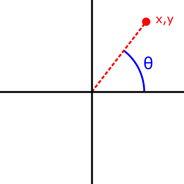

`Math.atan2()` is passed separate `x` and `y` arguments, and `Math.atan()` is passed the ratio of those two arguments.

Because `atan2()` is a static method of `Math`, you always use it as `Math.atan2()`, rather than as a method of a `Math` object you created (`Math` is not a constructor).

## Examples

### Using Math.atan2()

```
Math.atan2(90, 15); // 1.4056476493802699
Math.atan2(15, 90); // 0.16514867741462683

Math.atan2(±0, -0);               // ±PI.
Math.atan2(±0, +0);               // ±0.
Math.atan2(±0, -x);               // ±PI for x > 0.
Math.atan2(±0, x);                // ±0 for x > 0.
Math.atan2(-y, ±0);               // -PI/2 for y > 0.
Math.atan2(y, ±0);                // PI/2 for y > 0.
Math.atan2(±y, -Infinity);        // ±PI for finite y > 0.
Math.atan2(±y, +Infinity);        // ±0 for finite y > 0.
Math.atan2(±Infinity, x);         // ±PI/2 for finite x.
Math.atan2(±Infinity, -Infinity); // ±3*PI/4.
Math.atan2(±Infinity, +Infinity); // ±PI/4.
```

## Specifications

| Specification |
| --- |
| [ECMAScript Language Specification (ECMAScript)](https://tc39.es/ecma262/#sec-math.atan2) #sec-math.atan2 |

`atan2`

1

12

1

4

3

1

1

18

4

10.1

1

- `Math.acos()`
- `Math.asin()`
- `Math.atan()`
- `Math.cos()`
- `Math.sin()`
- `Math.tan()`

# Math.atanh()

The `Math.atanh()` function returns the hyperbolic arctangent of a number, that is

∀*x* ∈ (−1,1), `Math.atanh` `` (``x``) `` = arctanh (*x*) = the unique *y* such that tanh (*y*) = *x*

## Syntax

```
Math.atanh(x)
```

### Parameters

`x`  
A number.

### Return value

The hyperbolic arctangent of the given number.

## Description

Because `atanh()` is a static method of `Math`, you always use it as `Math.atanh()`, rather than as a method of a `Math` object you created (`Math` is not a constructor).

## Examples

### Using Math.atanh()

```
Math.atanh(-2);  // NaN
Math.atanh(-1);  // -Infinity
Math.atanh(0);   // 0
Math.atanh(0.5); // 0.5493061443340548
Math.atanh(1);   // Infinity
Math.atanh(2);   // NaN
```

For values greater than 1 or less than -1, `NaN` is returned.

## Polyfill

For |*x*| < 1, we have $\\operatorname{artanh}(x) = \\frac{1}{2}\\ln\\left( \\frac{1 + x}{1 - x} \\right)$ so this can be emulated by the following function:

```
Math.atanh = Math.atanh || function(x) {
  return Math.log((1+x)/(1-x)) / 2;
};
```

## Specifications

| Specification |
| --- |
| [ECMAScript Language Specification (ECMAScript)](https://tc39.es/ecma262/#sec-math.atanh) #sec-math.atanh |

`atanh`

38

12

25

No

25

8

38

38

25

25

8

3.0

## See also

- `Math.acosh()`
- `Math.asinh()`
- `Math.cosh()`
- `Math.sinh()`
- `Math.tanh()`

# Atomics

The `Atomics` object provides atomic operations as static methods. They are used with `SharedArrayBuffer` and `ArrayBuffer` objects.

## Description

The Atomic operations are installed on an `Atomics` module. Unlike the other global objects, `Atomics` is not a constructor. You cannot use it with a `new` operator or invoke the `Atomics` object as a function. All properties and methods of `Atomics` are static (as is the case with the `Math` object, for example).

### Atomic operations

When memory is shared, multiple threads can read and write the same data in memory. Atomic operations make sure that predictable values are written and read, that operations are finished before the next operation starts and that operations are not interrupted.

### Wait and notify

The `wait()` and `notify()` methods are modeled on Linux futexes ("fast user-space mutex”) and provide ways for waiting until a certain condition becomes true and are typically used as blocking constructs.

## Static methods

`Atomics.add()`  
Adds the provided value to the existing value at the specified index of the array. Returns the old value at that index.

`Atomics.and()`  
Computes a bitwise AND on the value at the specified index of the array with the provided value. Returns the old value at that index.

`Atomics.compareExchange()`  
Stores a value at the specified index of the array, if it equals a value. Returns the old value.

`Atomics.exchange()`  
Stores a value at the specified index of the array. Returns the old value.

`Atomics.isLockFree(size)`  
An optimization primitive that can be used to determine whether to use locks or atomic operations. Returns `true` if an atomic operation on arrays of the given element size will be implemented using a hardware atomic operation (as opposed to a lock). Experts only.

`Atomics.load()`  
Returns the value at the specified index of the array.

`Atomics.notify()`  
Notifies agents that are waiting on the specified index of the array. Returns the number of agents that were notified.

`Atomics.or()`  
Computes a bitwise OR on the value at the specified index of the array with the provided value. Returns the old value at that index.

`Atomics.store()`  
Stores a value at the specified index of the array. Returns the value.

`Atomics.sub()`  
Subtracts a value at the specified index of the array. Returns the old value at that index.

`Atomics.wait()`  
Verifies that the specified index of the array still contains a value and sleeps awaiting or times out. Returns either "`ok`”, "`not-equal`”, or "`timed-out`”. If waiting is not allowed in the calling agent then it throws an `Error` exception. (Most browsers will not allow `wait()` on the browser’s main thread.)

`Atomics.xor()`  
Computes a bitwise XOR on the value at the specified index of the array with the provided value. Returns the old value at that index.

## Examples

### Using Atomics

```
const sab = new SharedArrayBuffer(1024);
const ta = new Uint8Array(sab);

ta[0]; // 0
ta[0] = 5; // 5

Atomics.add(ta, 0, 12); // 5
Atomics.load(ta, 0); // 17

Atomics.and(ta, 0, 1); // 17
Atomics.load(ta, 0); // 1

Atomics.compareExchange(ta, 0, 5, 12); // 1
Atomics.load(ta, 0); // 1

Atomics.exchange(ta, 0, 12); // 1
Atomics.load(ta, 0); // 12

Atomics.isLockFree(1); // true
Atomics.isLockFree(2); // true
Atomics.isLockFree(3); // false
Atomics.isLockFree(4); // true

Atomics.or(ta, 0, 1); // 12
Atomics.load(ta, 0);  // 13

Atomics.store(ta, 0, 12); // 12

Atomics.sub(ta, 0, 2); // 12
Atomics.load(ta, 0); // 10

Atomics.xor(ta, 0, 1); // 10
Atomics.load(ta, 0); // 11
```

### Waiting and notifiying

Given a shared `Int32Array`:

```
const sab = new SharedArrayBuffer(1024);
const int32 = new Int32Array(sab);
```

A reading thread is sleeping and waiting on location 0 which is expected to be 0. As long as that is true, it will not go on. However, once the writing thread has stored a new value, it will be notified by the writing thread and return the new value (123).

```
Atomics.wait(int32, 0, 0);
console.log(int32[0]); // 123
```

A writing thread stores a new value and notifies the waiting thread once it has written:

```
console.log(int32[0]); // 0;
Atomics.store(int32, 0, 123);
Atomics.notify(int32, 0, 1);
```

## Specifications

| Specification |
| --- |
| [ECMAScript Language Specification (ECMAScript)](https://tc39.es/ecma262/#sec-atomics-object) #sec-atomics-object |

`Atomics`

68

60-63

Chrome disabled `SharedArrayBuffer` on January 5, 2018 to help reduce the efficacy of [speculative side-channel attacks](https://www.chromium.org/Home/chromium-security/ssca). This was a temporary removal while mitigations were put in place.

79

16-17

Support was removed to mitigate [speculative execution side-channel attacks (Windows blog)](https://blogs.windows.com/msedgedev/2018/01/03/speculative-execution-mitigations-microsoft-edge-internet-explorer).

78

57

Support was disabled by default to mitigate [speculative execution side-channel attacks (Mozilla Security Blog)](https://blog.mozilla.org/security/2018/01/03/mitigations-landing-new-class-timing-attack/).

55-57

46-55

No

No

10.1-11.1

60-63

Chrome disabled `SharedArrayBuffer` on January 5, 2018 to help reduce the efficacy of [speculative side-channel attacks](https://www.chromium.org/Home/chromium-security/ssca). This is intended as a temporary measure until other mitigations are in place.

60-63

Chrome disabled `SharedArrayBuffer` on January 5, 2018 to help reduce the efficacy of [speculative side-channel attacks](https://www.chromium.org/Home/chromium-security/ssca). This is intended as a temporary measure until other mitigations are in place.

57

Support was disabled by default to mitigate [speculative execution side-channel attacks (Mozilla Security Blog)](https://blog.mozilla.org/security/2018/01/03/mitigations-landing-new-class-timing-attack/).

55-57

46-55

No

10.3-11.3

No

Chrome disabled `SharedArrayBuffer` on January 5, 2018 to help reduce the efficacy of [speculative side-channel attacks](https://www.chromium.org/Home/chromium-security/ssca). This is intended as a temporary measure until other mitigations are in place.

`Atomic_operations_on_non-shared_buffers`

No

No

79

No

No

No

No

No

79

No

No

No

`add`

68

60-63

Chrome disabled `SharedArrayBuffer` on January 5, 2018 to help reduce the efficacy of [speculative side-channel attacks](https://www.chromium.org/Home/chromium-security/ssca). This was a temporary removal while mitigations were put in place.

79

16-17

Support was removed to mitigate [speculative execution side-channel attacks (Windows blog)](https://blogs.windows.com/msedgedev/2018/01/03/speculative-execution-mitigations-microsoft-edge-internet-explorer).

78

57

Support was disabled by default to mitigate [speculative execution side-channel attacks (Mozilla Security Blog)](https://blog.mozilla.org/security/2018/01/03/mitigations-landing-new-class-timing-attack/).

55-57

46-55

No

No

10.1-11.1

60-63

Chrome disabled `SharedArrayBuffer` on January 5, 2018 to help reduce the efficacy of [speculative side-channel attacks](https://www.chromium.org/Home/chromium-security/ssca). This is intended as a temporary measure until other mitigations are in place.

60-63

Chrome disabled `SharedArrayBuffer` on January 5, 2018 to help reduce the efficacy of [speculative side-channel attacks](https://www.chromium.org/Home/chromium-security/ssca). This is intended as a temporary measure until other mitigations are in place.

57

Support was disabled by default to mitigate [speculative execution side-channel attacks (Mozilla Security Blog)](https://blog.mozilla.org/security/2018/01/03/mitigations-landing-new-class-timing-attack/).

55-57

46-55

No

10.3-11.3

No

Chrome disabled `SharedArrayBuffer` on January 5, 2018 to help reduce the efficacy of [speculative side-channel attacks](https://www.chromium.org/Home/chromium-security/ssca). This is intended as a temporary measure until other mitigations are in place.

`and`

68

60-63

Chrome disabled `SharedArrayBuffer` on January 5, 2018 to help reduce the efficacy of [speculative side-channel attacks](https://www.chromium.org/Home/chromium-security/ssca). This was a temporary removal while mitigations were put in place.

79

16-17

Support was removed to mitigate [speculative execution side-channel attacks (Windows blog)](https://blogs.windows.com/msedgedev/2018/01/03/speculative-execution-mitigations-microsoft-edge-internet-explorer).

78

57

Support was disabled by default to mitigate [speculative execution side-channel attacks (Mozilla Security Blog)](https://blog.mozilla.org/security/2018/01/03/mitigations-landing-new-class-timing-attack/).

55-57

46-55

No

No

10.1-11.1

60-63

Chrome disabled `SharedArrayBuffer` on January 5, 2018 to help reduce the efficacy of [speculative side-channel attacks](https://www.chromium.org/Home/chromium-security/ssca). This is intended as a temporary measure until other mitigations are in place.

60-63

Chrome disabled `SharedArrayBuffer` on January 5, 2018 to help reduce the efficacy of [speculative side-channel attacks](https://www.chromium.org/Home/chromium-security/ssca). This is intended as a temporary measure until other mitigations are in place.

57

Support was disabled by default to mitigate [speculative execution side-channel attacks (Mozilla Security Blog)](https://blog.mozilla.org/security/2018/01/03/mitigations-landing-new-class-timing-attack/).

55-57

46-55

No

10.3-11.3

No

Chrome disabled `SharedArrayBuffer` on January 5, 2018 to help reduce the efficacy of [speculative side-channel attacks](https://www.chromium.org/Home/chromium-security/ssca). This is intended as a temporary measure until other mitigations are in place.

`compareExchange`

68

60-63

Chrome disabled `SharedArrayBuffer` on January 5, 2018 to help reduce the efficacy of [speculative side-channel attacks](https://www.chromium.org/Home/chromium-security/ssca). This was a temporary removal while mitigations were put in place.

79

16-17

Support was removed to mitigate [speculative execution side-channel attacks (Windows blog)](https://blogs.windows.com/msedgedev/2018/01/03/speculative-execution-mitigations-microsoft-edge-internet-explorer).

78

57

Support was disabled by default to mitigate [speculative execution side-channel attacks (Mozilla Security Blog)](https://blog.mozilla.org/security/2018/01/03/mitigations-landing-new-class-timing-attack/).

55-57

46-55

No

No

10.1-11.1

60-63

Chrome disabled `SharedArrayBuffer` on January 5, 2018 to help reduce the efficacy of [speculative side-channel attacks](https://www.chromium.org/Home/chromium-security/ssca). This is intended as a temporary measure until other mitigations are in place.

60-63

Chrome disabled `SharedArrayBuffer` on January 5, 2018 to help reduce the efficacy of [speculative side-channel attacks](https://www.chromium.org/Home/chromium-security/ssca). This is intended as a temporary measure until other mitigations are in place.

57

Support was disabled by default to mitigate [speculative execution side-channel attacks (Mozilla Security Blog)](https://blog.mozilla.org/security/2018/01/03/mitigations-landing-new-class-timing-attack/).

55-57

46-55

No

10.3-11.3

No

Chrome disabled `SharedArrayBuffer` on January 5, 2018 to help reduce the efficacy of [speculative side-channel attacks](https://www.chromium.org/Home/chromium-security/ssca). This is intended as a temporary measure until other mitigations are in place.

`exchange`

68

60-63

Chrome disabled `SharedArrayBuffer` on January 5, 2018 to help reduce the efficacy of [speculative side-channel attacks](https://www.chromium.org/Home/chromium-security/ssca). This was a temporary removal while mitigations were put in place.

79

16-17

Support was removed to mitigate [speculative execution side-channel attacks (Windows blog)](https://blogs.windows.com/msedgedev/2018/01/03/speculative-execution-mitigations-microsoft-edge-internet-explorer).

78

57

Support was disabled by default to mitigate [speculative execution side-channel attacks (Mozilla Security Blog)](https://blog.mozilla.org/security/2018/01/03/mitigations-landing-new-class-timing-attack/).

55-57

46-55

No

No

10.1-11.1

60-63

Chrome disabled `SharedArrayBuffer` on January 5, 2018 to help reduce the efficacy of [speculative side-channel attacks](https://www.chromium.org/Home/chromium-security/ssca). This is intended as a temporary measure until other mitigations are in place.

60-63

Chrome disabled `SharedArrayBuffer` on January 5, 2018 to help reduce the efficacy of [speculative side-channel attacks](https://www.chromium.org/Home/chromium-security/ssca). This is intended as a temporary measure until other mitigations are in place.

57

Support was disabled by default to mitigate [speculative execution side-channel attacks (Mozilla Security Blog)](https://blog.mozilla.org/security/2018/01/03/mitigations-landing-new-class-timing-attack/).

55-57

46-55

No

10.3-11.3

No

Chrome disabled `SharedArrayBuffer` on January 5, 2018 to help reduce the efficacy of [speculative side-channel attacks](https://www.chromium.org/Home/chromium-security/ssca). This is intended as a temporary measure until other mitigations are in place.

`isLockFree`

68

60-63

Chrome disabled `SharedArrayBuffer` on January 5, 2018 to help reduce the efficacy of [speculative side-channel attacks](https://www.chromium.org/Home/chromium-security/ssca). This was a temporary removal while mitigations were put in place.

79

16-17

Support was removed to mitigate [speculative execution side-channel attacks (Windows blog)](https://blogs.windows.com/msedgedev/2018/01/03/speculative-execution-mitigations-microsoft-edge-internet-explorer).

78

57

Support was disabled by default to mitigate [speculative execution side-channel attacks (Mozilla Security Blog)](https://blog.mozilla.org/security/2018/01/03/mitigations-landing-new-class-timing-attack/).

55-57

46-55

No

No

10.1-11.1

60-63

Chrome disabled `SharedArrayBuffer` on January 5, 2018 to help reduce the efficacy of [speculative side-channel attacks](https://www.chromium.org/Home/chromium-security/ssca). This is intended as a temporary measure until other mitigations are in place.

60-63

Chrome disabled `SharedArrayBuffer` on January 5, 2018 to help reduce the efficacy of [speculative side-channel attacks](https://www.chromium.org/Home/chromium-security/ssca). This is intended as a temporary measure until other mitigations are in place.

57

Support was disabled by default to mitigate [speculative execution side-channel attacks (Mozilla Security Blog)](https://blog.mozilla.org/security/2018/01/03/mitigations-landing-new-class-timing-attack/).

55-57

46-55

No

10.3-11.3

No

Chrome disabled `SharedArrayBuffer` on January 5, 2018 to help reduce the efficacy of [speculative side-channel attacks](https://www.chromium.org/Home/chromium-security/ssca). This is intended as a temporary measure until other mitigations are in place.

`load`

68

60-63

Chrome disabled `SharedArrayBuffer` on January 5, 2018 to help reduce the efficacy of [speculative side-channel attacks](https://www.chromium.org/Home/chromium-security/ssca). This was a temporary removal while mitigations were put in place.

79

16-17

Support was removed to mitigate [speculative execution side-channel attacks (Windows blog)](https://blogs.windows.com/msedgedev/2018/01/03/speculative-execution-mitigations-microsoft-edge-internet-explorer).

78

57

Support was disabled by default to mitigate [speculative execution side-channel attacks (Mozilla Security Blog)](https://blog.mozilla.org/security/2018/01/03/mitigations-landing-new-class-timing-attack/).

55-57

46-55

No

No

10.1-11.1

60-63

Chrome disabled `SharedArrayBuffer` on January 5, 2018 to help reduce the efficacy of [speculative side-channel attacks](https://www.chromium.org/Home/chromium-security/ssca). This is intended as a temporary measure until other mitigations are in place.

60-63

Chrome disabled SharedArrayBuffer on January 5, 2018 to help reduce the efficacy of [speculative side-channel attacks](https://www.chromium.org/Home/chromium-security/ssca). This is intended as a temporary measure until other mitigations are in place.

57

Support was disabled by default to mitigate [speculative execution side-channel attacks (Mozilla Security Blog)](https://blog.mozilla.org/security/2018/01/03/mitigations-landing-new-class-timing-attack/).

55-57

46-55

No

10.3-11.3

No

Chrome disabled SharedArrayBuffer on January 5, 2018 to help reduce the efficacy of [speculative side-channel attacks](https://www.chromium.org/Home/chromium-security/ssca). This is intended as a temporary measure until other mitigations are in place.

`notify`

68

60-63

Chrome disabled `SharedArrayBuffer` on January 5, 2018 to help reduce the efficacy of [speculative side-channel attacks](https://www.chromium.org/Home/chromium-security/ssca). This was a temporary removal while mitigations were put in place.

79

78

63

Support was disabled by default to mitigate [speculative execution side-channel attacks (Mozilla Security Blog)](https://blog.mozilla.org/security/2018/01/03/mitigations-landing-new-class-timing-attack/).

57

Support was disabled by default to mitigate [speculative execution side-channel attacks (Mozilla Security Blog)](https://blog.mozilla.org/security/2018/01/03/mitigations-landing-new-class-timing-attack/).

55-57

48-55

46-48

The `count` parameter defaults to `0` instead of the later-specified `+Infinity`.

No

No

10.1-11.1

60-63

Chrome disabled `SharedArrayBuffer` on January 5, 2018 to help reduce the efficacy of [speculative side-channel attacks](https://www.chromium.org/Home/chromium-security/ssca). This is intended as a temporary measure until other mitigations are in place.

60-63

Chrome disabled `SharedArrayBuffer` on January 5, 2018 to help reduce the efficacy of [speculative side-channel attacks](https://www.chromium.org/Home/chromium-security/ssca). This is intended as a temporary measure until other mitigations are in place.

63

Support was disabled by default to mitigate [speculative execution side-channel attacks (Mozilla Security Blog)](https://blog.mozilla.org/security/2018/01/03/mitigations-landing-new-class-timing-attack/).

57

Support was disabled by default to mitigate [speculative execution side-channel attacks (Mozilla Security Blog)](https://blog.mozilla.org/security/2018/01/03/mitigations-landing-new-class-timing-attack/).

55-57

48-55

46-48

The `count` parameter defaults to `0` instead of the later-specified `+Infinity`.

No

10.3-11.3

No

Chrome disabled `SharedArrayBuffer` on January 5, 2018 to help reduce the efficacy of [speculative side-channel attacks](https://www.chromium.org/Home/chromium-security/ssca). This is intended as a temporary measure until other mitigations are in place.

`or`

68

60-63

Chrome disabled `SharedArrayBuffer` on January 5, 2018 to help reduce the efficacy of [speculative side-channel attacks](https://www.chromium.org/Home/chromium-security/ssca). This was a temporary removal while mitigations were put in place.

79

16-17

Support was removed to mitigate [speculative execution side-channel attacks (Windows blog)](https://blogs.windows.com/msedgedev/2018/01/03/speculative-execution-mitigations-microsoft-edge-internet-explorer).

78

57

Support was disabled by default to mitigate [speculative execution side-channel attacks (Mozilla Security Blog)](https://blog.mozilla.org/security/2018/01/03/mitigations-landing-new-class-timing-attack/).

55-57

46-55

No

No

10.1-11.1

60-63

Chrome disabled `SharedArrayBuffer` on January 5, 2018 to help reduce the efficacy of [speculative side-channel attacks](https://www.chromium.org/Home/chromium-security/ssca). This is intended as a temporary measure until other mitigations are in place.

60-63

Chrome disabled `SharedArrayBuffer` on January 5, 2018 to help reduce the efficacy of [speculative side-channel attacks](https://www.chromium.org/Home/chromium-security/ssca). This is intended as a temporary measure until other mitigations are in place.

57

Support was disabled by default to mitigate [speculative execution side-channel attacks (Mozilla Security Blog)](https://blog.mozilla.org/security/2018/01/03/mitigations-landing-new-class-timing-attack/).

55-57

46-55

No

10.3-11.3

No

Chrome disabled `SharedArrayBuffer` on January 5, 2018 to help reduce the efficacy of [speculative side-channel attacks](https://www.chromium.org/Home/chromium-security/ssca). This is intended as a temporary measure until other mitigations are in place.

`store`

68

60-63

Chrome disabled `SharedArrayBuffer` on January 5, 2018 to help reduce the efficacy of [speculative side-channel attacks](https://www.chromium.org/Home/chromium-security/ssca). This was a temporary removal while mitigations were put in place.

79

16-17

Support was removed to mitigate [speculative execution side-channel attacks (Windows blog)](https://blogs.windows.com/msedgedev/2018/01/03/speculative-execution-mitigations-microsoft-edge-internet-explorer).

78

57

Support was disabled by default to mitigate [speculative execution side-channel attacks (Mozilla Security Blog)](https://blog.mozilla.org/security/2018/01/03/mitigations-landing-new-class-timing-attack/).

55-57

46-55

No

No

10.1-11.1

60-63

Chrome disabled `SharedArrayBuffer` on January 5, 2018 to help reduce the efficacy of [speculative side-channel attacks](https://www.chromium.org/Home/chromium-security/ssca). This is intended as a temporary measure until other mitigations are in place.

60-63

Chrome disabled `SharedArrayBuffer` on January 5, 2018 to help reduce the efficacy of [speculative side-channel attacks](https://www.chromium.org/Home/chromium-security/ssca). This is intended as a temporary measure until other mitigations are in place.

57

Support was disabled by default to mitigate [speculative execution side-channel attacks (Mozilla Security Blog)](https://blog.mozilla.org/security/2018/01/03/mitigations-landing-new-class-timing-attack/).

55-57

46-55

No

10.3-11.3

No

Chrome disabled `SharedArrayBuffer` on January 5, 2018 to help reduce the efficacy of [speculative side-channel attacks](https://www.chromium.org/Home/chromium-security/ssca). This is intended as a temporary measure until other mitigations are in place.

`sub`

68

60-63

Chrome disabled `SharedArrayBuffer` on January 5, 2018 to help reduce the efficacy of [speculative side-channel attacks](https://www.chromium.org/Home/chromium-security/ssca). This was a temporary removal while mitigations were put in place.

79

16-17

Support was removed to mitigate [speculative execution side-channel attacks (Windows blog)](https://blogs.windows.com/msedgedev/2018/01/03/speculative-execution-mitigations-microsoft-edge-internet-explorer).

78

57

Support was disabled by default to mitigate [speculative execution side-channel attacks (Mozilla Security Blog)](https://blog.mozilla.org/security/2018/01/03/mitigations-landing-new-class-timing-attack/).

55-57

46-55

No

No

10.1-11.1

60-63

Chrome disabled `SharedArrayBuffer` on January 5, 2018 to help reduce the efficacy of [speculative side-channel attacks](https://www.chromium.org/Home/chromium-security/ssca). This is intended as a temporary measure until other mitigations are in place.

60-63

Chrome disabled SharedArrayBuffer on January 5, 2018 to help reduce the efficacy of [speculative side-channel attacks](https://www.chromium.org/Home/chromium-security/ssca). This is intended as a temporary measure until other mitigations are in place.

57

Support was disabled by default to mitigate [speculative execution side-channel attacks (Mozilla Security Blog)](https://blog.mozilla.org/security/2018/01/03/mitigations-landing-new-class-timing-attack/).

55-57

46-55

No

10.3-11.3

No

Chrome disabled SharedArrayBuffer on January 5, 2018 to help reduce the efficacy of [speculative side-channel attacks](https://www.chromium.org/Home/chromium-security/ssca). This is intended as a temporary measure until other mitigations are in place.

`wait`

68

60-63

Chrome disabled `SharedArrayBuffer` on January 5, 2018 to help reduce the efficacy of [speculative side-channel attacks](https://www.chromium.org/Home/chromium-security/ssca). This was a temporary removal while mitigations were put in place.

79

16-17

Support was removed to mitigate [speculative execution side-channel attacks (Windows blog)](https://blogs.windows.com/msedgedev/2018/01/03/speculative-execution-mitigations-microsoft-edge-internet-explorer).

78

57

Support was disabled by default to mitigate [speculative execution side-channel attacks (Mozilla Security Blog)](https://blog.mozilla.org/security/2018/01/03/mitigations-landing-new-class-timing-attack/).

55-57

48-55

46-48

The method returns values `Atomics.OK`, `Atomics.TIMEDOUT`, and `Atomics.NOTEQUAL`, instead of the later-specified strings.

No

No

10.1-11.1

60-63

Chrome disabled `SharedArrayBuffer` on January 5, 2018 to help reduce the efficacy of [speculative side-channel attacks](https://www.chromium.org/Home/chromium-security/ssca). This is intended as a temporary measure until other mitigations are in place.

60-63

Chrome disabled `SharedArrayBuffer` on January 5, 2018 to help reduce the efficacy of [speculative side-channel attacks](https://www.chromium.org/Home/chromium-security/ssca). This is intended as a temporary measure until other mitigations are in place.

57

Support was disabled by default to mitigate [speculative execution side-channel attacks (Mozilla Security Blog)](https://blog.mozilla.org/security/2018/01/03/mitigations-landing-new-class-timing-attack/).

55-57

48-55

46-48

The method returns values `Atomics.OK`, `Atomics.TIMEDOUT`, and `Atomics.NOTEQUAL`, instead of the later-specified strings.

No

10.3-11.3

No

Chrome disabled `SharedArrayBuffer` on January 5, 2018 to help reduce the efficacy of [speculative side-channel attacks](https://www.chromium.org/Home/chromium-security/ssca). This is intended as a temporary measure until other mitigations are in place.

`xor`

68

60-63

Chrome disabled `SharedArrayBuffer` on January 5, 2018 to help reduce the efficacy of [speculative side-channel attacks](https://www.chromium.org/Home/chromium-security/ssca). This was a temporary removal while mitigations were put in place.

79

16-17

Support was removed to mitigate [speculative execution side-channel attacks (Windows blog)](https://blogs.windows.com/msedgedev/2018/01/03/speculative-execution-mitigations-microsoft-edge-internet-explorer).

78

57

Support was disabled by default to mitigate [speculative execution side-channel attacks (Mozilla Security Blog)](https://blog.mozilla.org/security/2018/01/03/mitigations-landing-new-class-timing-attack/).

55-57

46-55

No

No

10.1-11.1

60-63

Chrome disabled `SharedArrayBuffer` on January 5, 2018 to help reduce the efficacy of [speculative side-channel attacks](https://www.chromium.org/Home/chromium-security/ssca). This is intended as a temporary measure until other mitigations are in place.

60-63

Chrome disabled `SharedArrayBuffer` on January 5, 2018 to help reduce the efficacy of [speculative side-channel attacks](https://www.chromium.org/Home/chromium-security/ssca). This is intended as a temporary measure until other mitigations are in place.

57

Support was disabled by default to mitigate [speculative execution side-channel attacks (Mozilla Security Blog)](https://blog.mozilla.org/security/2018/01/03/mitigations-landing-new-class-timing-attack/).

55-57

46-55

No

10.3-11.3

No

Chrome disabled `SharedArrayBuffer` on January 5, 2018 to help reduce the efficacy of [speculative side-channel attacks](https://www.chromium.org/Home/chromium-security/ssca). This is intended as a temporary measure until other mitigations are in place.

## See also

- `ArrayBuffer`
- [JavaScript typed arrays](https://developer.mozilla.org/en-US/docs/Web/JavaScript/Typed_arrays)
- [Web Workers](https://developer.mozilla.org/en-US/docs/Web/API/Web_Workers_API)
- parlib-simple - a simple library providing synchronization and work distribution abstractions.
- [Shared Memory - a brief tutorial](https://github.com/tc39/ecmascript_sharedmem/blob/master/TUTORIAL.md)
- [A Taste of JavaScript’s New Parallel Primitives - Mozilla Hacks](https://hacks.mozilla.org/2016/05/a-taste-of-javascripts-new-parallel-primitives/)

# await

The `await` operator is used to wait for a `Promise`. It can only be used inside an `async function` within regular JavaScript code; however it can be used on its own with [JavaScript modules.](https://developer.mozilla.org/en-US/docs/Web/JavaScript/Guide/Modules)

## Syntax

```
[rv] = await expression;
```

`expression`  
A `Promise` or any value to wait for.

`rv`  
Returns the fulfilled value of the promise, or the value itself if it’s not a `Promise`.

## Description

The `await` expression causes `async` function execution to pause until a `Promise` is settled (that is, fulfilled or rejected), and to resume execution of the `async` function after fulfillment. When resumed, the value of the `await` expression is that of the fulfilled `Promise`.

If the `Promise` is rejected, the `await` expression throws the rejected value.

If the value of the *expression* following the `await` operator is not a `Promise`, it’s converted to a resolved Promise.

An `await` splits execution flow, allowing the caller of the async function to resume execution. After the `await` defers the continuation of the async function, execution of subsequent statements ensues. If this `await` is the last expression executed by its function, execution continues by returning to the function’s caller a pending `Promise` for completion of the `await`’s function and resuming execution of that caller.

## Examples

### Awaiting a promise to be fulfilled

If a `Promise` is passed to an `await` expression, it waits for the `Promise` to be fulfilled and returns the fulfilled value.

```
function resolveAfter2Seconds(x) {
  return new Promise(resolve => {
    setTimeout(() => {
      resolve(x);
    }, 2000);
  });
}

async function f1() {
  var x = await resolveAfter2Seconds(10);
  console.log(x); // 10
}

f1();
```

### Thenable objects

`Thenable objects` will be fulfilled just the same.

```
async function f2() {
  const thenable = {
    then: function(resolve, _reject) {
      resolve('resolved!')
    }
  };
  console.log(await thenable); // resolved!
}

f2();
```

### Conversion to promise

If the value is not a `Promise`, it converts the value to a resolved `Promise`, and waits for it.

```
async function f3() {
  var y = await 20;
  console.log(y); // 20
}

f3();
```

### Promise rejection

If the `Promise` is rejected, the rejected value is thrown.

```
async function f4() {
  try {
    var z = await Promise.reject(30);
  } catch(e) {
    console.error(e); // 30
  }
}

f4();
```

### Handling rejected promises

Handle rejected `Promise` without try block.

```
var response = await promisedFunction().catch((err) => { console.error(err); });
// response will be undefined if the promise is rejected
```

### Top level await

You can use the `await` keyword on its own (outside of an async function) within a [JavaScript module](https://developer.mozilla.org/en-US/docs/Web/JavaScript/Guide/Modules). This means modules, with child modules that use `await`, wait for the child module to execute before they themselves run. All while not blocking other child modules from loading.

Here is an example of a simple module using the [Fetch API](https://developer.mozilla.org/en-US/docs/Web/API/Fetch_API) and specifying await within the `export statement`. Any modules that include this will wait for the fetch to resolve before running any code.

```
// fetch request
const colors = fetch('../data/colors.json')
  .then(response => response.json());

export default await colors;
```

# Warning: 08/09 is not a legal ECMA-262 octal constant

The JavaScript warning "08 (or 09) is not a legal ECMA-262 octal constant” occurs when `08` or `09` number literals are used. They can’t be interpreted as an octal number.

## Message

```
Warning: SyntaxError: 08 is not a legal ECMA-262 octal constant.
Warning: SyntaxError: 09 is not a legal ECMA-262 octal constant.
```

## Error type

Warning. JavaScript execution won’t be halted.

## What went wrong?

Decimal literals can start with a zero (`0`) followed by another decimal digit, but If all digits after the leading `0` are smaller than 8, the number is interpreted as an octal number. Because this is not the case with `08` and `09`, JavaScript warns about it.

Note that octal literals and octal escape sequences are deprecated and will present an additional deprecation warning. With ECMAScript 6 and later, the syntax uses a leading zero followed by a lowercase or uppercase Latin letter "O” (`0o` or `0O)`. See the page about lexical grammar for more information.

## Examples

### Invalid octal numbers

```
08;
09;
// SyntaxError: 08 is not a legal ECMA-262 octal constant
// SyntaxError: "0"-prefixed octal literals and octal escape sequences
// are deprecated
```

### Valid octal numbers

Use a leading zero followed by the letter "o”;

```
0O755;
0o644;
```

## See also

- Lexical grammar
- SyntaxError: "0”-prefixed octal literals and octal escape seq. are deprecated

# RangeError: radix must be an integer

The JavaScript exception "radix must be an integer at least 2 and no greater than 36” occurs when the optional `radix` parameter of the `Number.prototype.toString()` or the `BigInt.prototype.toString()` method was specified and is not between 2 and 36.

## Message

```
RangeError: invalid argument (Edge)
RangeError: radix must be an integer at least 2 and no greater than 36 (Firefox)
RangeError: toString() radix argument must be between 2 and 36 (Chrome)
```

## Error type

`RangeError`

## What went wrong?

The optional `radix` parameter of the `Number.prototype.toString()` or the `BigInt.prototype.toString()` method was specified. Its value must be an integer (a number) between 2 and 36, specifying the base of the number system to be used for representing numeric values. For example, the decimal (base 10) number 169 is represented in hexadecimal (base 16) as A9.

Why is this parameter’s value limited to 36? A radix that is larger than 10 uses alphabetical characters as digits; therefore, the radix can’t be larger than 36, since the Latin alphabet (used by English and many other languages) only has 26 characters.

The most common radixes:

- 2 for [binary numbers](https://en.wikipedia.org/wiki/Binary_number),
- 8 for [octal numbers](https://en.wikipedia.org/wiki/Octal),
- 10 for [decimal numbers](https://en.wikipedia.org/wiki/Decimal),
- 16 for [hexadecimal numbers](https://en.wikipedia.org/wiki/Hexadecimal).

## Examples

### Invalid cases

```
(42).toString(0);
(42).toString(1);
(42).toString(37);
(42).toString(150);
// You cannot use a string like this for formatting:
(12071989).toString('MM-dd-yyyy');
```

### Valid cases

```
(42).toString(2);     // "101010" (binary)
(13).toString(8);     // "15"     (octal)
(0x42).toString(10);  // "66"     (decimal)
(100000).toString(16) // "186a0"  (hexadecimal)
```

## See also

- `Number.prototype.toString()`
- `BigInt.prototype.toString()`

# SyntaxError: invalid regular expression flag "x”

The JavaScript exception "invalid regular expression flag” occurs when the flags, defined after the second slash in regular expression literal, are not one of `g`, `i`, `m`, `s`, `u`, or `y`.

## Message

```
SyntaxError: Syntax error in regular expression (Edge)
SyntaxError: invalid regular expression flag "x" (Firefox)
SyntaxError: Invalid regular expression flags (Chrome)
```

## Error type

`SyntaxError`

## What went wrong?

There are invalid regular expression flags in the code. In a regular expression literal, which consists of a pattern enclosed between slashes, the flags are defined after the second slash. They can also be defined in the constructor function of the `RegExp` object (second parameter). Regular expression flags can be used separately or together in any order, but there are only six of them in ECMAScript.

To include a flag with the regular expression, use this syntax:

```
var re = /pattern/flags;
```

or

```
var re = new RegExp('pattern', 'flags');
```

Regular expression flags

| Flag | Description |
| --- | --- |
| `g` | Global search. |
| i | Case-insensitive search. |
| m | Multi-line search. |
| s | Allow `.` to match newlines (added in ECMAScript 2018) |
| u | Unicode; treat pattern as a sequence of Unicode code points |
| y | Perform a "sticky” search that matches starting at the current position in the target string. See `sticky` |

## Examples

There are only six valid regular expression flags.

```
/foo/bar;

// SyntaxError: invalid regular expression flag "b"
```

Did you intend to create a regular expression? An expression containing two slashes is interpreted as a regular expression literal.

```
let obj = {
  url: /docs/Web
};

// SyntaxError: invalid regular expression flag "W"
```

Or did you mean to create a string instead? Add single or double quotes to create a string literal.

```
let obj = {
  url: '/docs/Web'
};
```

### Valid regular expression flags

See the table above for the six valid regular expression flags that are allowed in JavaScript.

```
/foo/g;
/foo/gims;
/foo/uy;
```

## See also

- [Regular expressions](https://developer.mozilla.org/en-US/docs/Web/JavaScript/Guide/Regular_Expressions)
- [XRegEx flags](https://xregexp.com/flags/) - regular expression library that provides four new flags (`n`, `s`, `x`, `A`)

# SyntaxError: return not in function

The JavaScript exception "return (or yield) not in function” occurs when a `return` or `yield` statement is called outside of a [function](https://developer.mozilla.org/en-US/docs/Web/JavaScript/Guide/Functions).

## Message

```
SyntaxError: 'return' statement outside of function (Edge)
SyntaxError: return not in function (Firefox)
SyntaxError: yield not in function (Firefox)
```

## Error type

`SyntaxError`.

## What went wrong?

A `return` or `yield` statement is called outside of a [function](https://developer.mozilla.org/en-US/docs/Web/JavaScript/Guide/Functions). Maybe there are missing curly brackets somewhere? The `return` and `yield` statements must be in a function, because they end (or pause and resume) function execution and specify a value to be returned to the function caller.

## Examples

### Missing curly brackets

```
var cheer = function(score) {
  if (score === 147)
    return 'Maximum!';
  };
  if (score > 100) {
    return 'Century!';
  }
}

// SyntaxError: return not in function
```

The curly brackets look correct at a first glance, but this code snippet is missing a `{` after the first `if` statement. Correct would be:

```
var cheer = function(score) {
  if (score === 147) {
    return 'Maximum!';
  }
  if (score > 100) {
    return 'Century!';
  }
};
```

## See also

- `return`
- `yield`

# Intl.Locale.prototype.baseName

The `Intl.Locale.prototype.baseName` property returns a substring of the `Locale`’s string representation, containing core information about the `Locale`.

## Description

An `Intl.Locale` object represents a parsed local and options for that locale. The `baseName` property returns basic, core information about the Locale in the form of a substring of the complete data string. Specifically, the property returns the substring containing the language, and the script and region if available.

`baseName` returns the `language ["-" script] ["-" region] *("-" variant)` subsequence of the [unicode_language_id grammar](https://www.unicode.org/reports/tr35/#Identifiers).

## Examples

### Basic Example

```
let myLoc = new Intl.Locale("fr-Latn-CA"); // Sets locale to Canadian French
console.log(myLoc.toString()); // Prints out "fr-Latn-CA-u-ca-gregory"
console.log(myLoc.baseName); // Prints out "fr-Latn-CA"
```

### Example with options in the input string

```
// Sets language to Japanese, region to Japan,

// calendar to Gregorian, hour cycle to 24 hours
let japan = new Intl.Locale("ja-JP-u-ca-gregory-hc-24");
console.log(japan.toString()); // Prints out "ja-JP-u-ca-gregory-hc-h24"
console.log(japan.baseName); // Prints out "ja-JP"
```

### Example with options that override input string

```
// Input string indicates language as Dutch and region as Belgium,

// but options object overrides the region and sets it to the Netherlands
let dutch = new Intl.Locale("nl-Latn-BE", {region: "NL"});

console.log(dutch.baseName); // Prints out "nl-Latn-NL"
```

## Specifications

| Specification |
| --- |
| [ECMAScript Internationalization API Specification (ECMAScript Internationalization API)](https://tc39.es/ecma402/#sec-Intl.Locale.prototype.baseName) #sec-Intl.Locale.prototype.baseName |

`baseName`

74

79

75

No

62

14

74

74

79

53

14

1

- `Intl.Locale`

# String.prototype.big()

**Deprecated**

This feature is no longer recommended. Though some browsers might still support it, it may have already been removed from the relevant web standards, may be in the process of being dropped, or may only be kept for compatibility purposes. Avoid using it, and update existing code if possible; see the compatibility table at the bottom of this page to guide your decision. Be aware that this feature may cease to work at any time.

The `big()` method creates a [`<big>`](https://developer.mozilla.org/en-US/docs/Web/HTML/Element/big) HTML element that causes a string to be displayed in a big font.

**Note:** The <big> element has been removed in HTML5 and shouldn’t be used anymore. Instead web developers should use CSS properties.

## Syntax

```
big()
```

### Return value

A string containing a [`<big>`](https://developer.mozilla.org/en-US/docs/Web/HTML/Element/big) HTML element.

## Description

The `big()` method embeds a string in a `<big>` element: "`<big>str</big>`”.

## Examples

### Using big()

The following example uses string methods to change the size of a string:

```
var worldString = 'Hello, world';

console.log(worldString.small());     // <small>Hello, world</small>
console.log(worldString.big());       // <big>Hello, world</big>
console.log(worldString.fontsize(7)); // <font size="7">Hello, world</font>
```

With the [`element.style`](https://developer.mozilla.org/en-US/docs/Web/API/ElementCSSInlineStyle/style) object you can get the element’s `style` attribute and manipulate it more generically, for example:

```
document.getElementById('yourElemId').style.fontSize = '2em';
```

## Specifications

| Specification |
| --- |
| [ECMAScript Language Specification (ECMAScript)](https://tc39.es/ecma262/#sec-string.prototype.big) #sec-string.prototype.big |

`big`

1

12

1

3

3

1

1

18

4

10.1

1

- `String.prototype.fontsize()`
- `String.prototype.small()`

# BigInt

`BigInt` is a built-in object whose constructor returns a `bigint` [primitive](https://developer.mozilla.org/en-US/docs/Glossary/Primitive) — also called a **BigInt value**, or sometimes just a **BigInt** — to represent whole numbers larger than 2<sup>53</sup> - 1 (`Number.MAX_SAFE_INTEGER`), which is the largest number JavaScript can represent with a `number` [primitive](https://developer.mozilla.org/en-US/docs/Glossary/Primitive) (or *Number value*). BigInt values can be used for arbitrarily large integers.

## Description

A **BigInt value**, also sometimes just called a **BigInt**, is a `bigint` [primitive](https://developer.mozilla.org/en-US/docs/Glossary/Primitive), created by appending `n` to the end of an integer literal, or by calling the `BigInt()` constructor (but without the `new` operator) and giving it an integer value or string value.

```
const previouslyMaxSafeInteger = 9007199254740991n

const alsoHuge = BigInt(9007199254740991)
// ↪ 9007199254740991n

const hugeString = BigInt("9007199254740991")
// ↪ 9007199254740991n

const hugeHex = BigInt("0x1fffffffffffff")
// ↪ 9007199254740991n

const hugeOctal = BigInt("0o377777777777777777")
// ↪ 9007199254740991n

const hugeBin = BigInt("0b11111111111111111111111111111111111111111111111111111")
// ↪ 9007199254740991n
```

BigInt values are similar to Number values in some ways, but also differ in a few key matters: A BigInt value cannot be used with methods in the built-in `Math` object and cannot be mixed with a Number value in operations; they must be coerced to the same type. Be careful coercing values back and forth, however, as the precision of a BigInt value may be lost when it is coerced to a Number value.

### Type information

When tested against `typeof`, a BigInt value (`bigint` primitive) will give "`bigint`”:

```
typeof 1n === 'bigint'           // true
typeof BigInt('1') === 'bigint'  // true
```

A BigInt value can also be wrapped in an `Object`:

```
typeof Object(1n) === 'object'  // true
```

### Operators

The following operators may be used with BigInt values or object-wrapped BigInt values:

```
+ * - % **
```

[Bitwise operators](https://developer.mozilla.org/en-US/docs/Web/JavaScript/Reference/Operators) are supported as well, except `>>>` (zero-fill right shift), as every BigInt value is signed.

Also unsupported is the unary operator (`+`), [in order to not break asm.js](https://github.com/tc39/proposal-bigint/blob/master/ADVANCED.md#dont-break-asmjs).

```
const previousMaxSafe = BigInt(Number.MAX_SAFE_INTEGER)
// ↪ 9007199254740991n

const maxPlusOne = previousMaxSafe + 1n
// ↪ 9007199254740992n

const theFuture = previousMaxSafe + 2n
// ↪ 9007199254740993n, this works now!

const multi = previousMaxSafe * 2n
// ↪ 18014398509481982n

const subtr = multi - 10n
// ↪ 18014398509481972n

const mod = multi % 10n
// ↪ 2n

const bigN = 2n ** 54n
// ↪ 18014398509481984n

bigN * -1n
// ↪ -18014398509481984n
```

The `/` operator also works as expected with whole numbers — but operations with a fractional result will be truncated when used with a BigInt value — they won’t return any fractional digits.

```
const expected = 4n / 2n
// ↪ 2n

const truncated = 5n / 2n
// ↪ 2n, not 2.5n
```

### Comparisons

A BigInt value is not strictly equal to a Number value, but it *is* loosely so:

```
0n === 0
// ↪ false

0n == 0
// ↪ true
```

A Number value and a BigInt value may be compared as usual:

```
1n < 2
// ↪ true

2n > 1
// ↪ true

2 > 2
// ↪ false

2n > 2
// ↪ false

2n >= 2
// ↪ true
```

BigInt values and Number values may be mixed in arrays and sorted:

```
const mixed = [4n, 6, -12n, 10, 4, 0, 0n]
// ↪  [4n, 6, -12n, 10, 4, 0, 0n]

mixed.sort() // default sorting behavior
// ↪  [ -12n, 0, 0n, 10, 4n, 4, 6 ]

mixed.sort((a, b) => a - b)
// won't work since subtraction will not work with mixed types
// TypeError: can't convert BigInt value to Number value

// sort with an appropriate numeric comparator
mixed.sort((a, b) => (a < b) ? -1 : ((a > b) ? 1 : 0))
// ↪  [ -12n, 0, 0n, 4n, 4, 6, 10 ]
```

Note that comparisons with `Object`-wrapped BigInt values act as with other objects, only indicating equality when the same object instance is compared:

```
0n === Object(0n)          // false
Object(0n) === Object(0n)  // false

const o = Object(0n)
o === o                    // true
```

### Conditionals

A BigInt value behaves like a Number value in cases where:

- it is converted to a `Boolean`: via the `Boolean` function;
- when used with [logical operators](https://developer.mozilla.org/en-US/docs/Web/JavaScript/Reference/Operators) `||`, `&&`, and `!`; or
- within a conditional test like an `if` statement.

```
if (0n) {
  console.log('Hello from the if!')
} else {
  console.log('Hello from the else!')
}

// ↪ "Hello from the else!"

0n || 12n
// ↪ 12n

0n && 12n
// ↪ 0n

Boolean(0n)
// ↪ false

Boolean(12n)
// ↪ true

!12n
// ↪ false

!0n
// ↪ true
```

## Constructor

`BigInt()`  
Creates a new BigInt value.

## Static methods

`BigInt.asIntN()`  
Clamps a BigInt value to a signed integer value, and returns that value.

`BigInt.asUintN()`  
Clamps a BigInt value to an unsigned integer value, and returns that value.

## Instance methods

`BigInt.prototype.toLocaleString()`  
Returns a string with a language-sensitive representation of this BigInt value. Overrides the `Object.prototype.toLocaleString()` method.

`BigInt.prototype.toString()`  
Returns a string representing this BigInt value in the specified radix (base). Overrides the `Object.prototype.toString()` method.

`BigInt.prototype.valueOf()`  
Returns this BigInt value. Overrides the `Object.prototype.valueOf()` method.

## Usage recommendations

### Coercion

Because coercing between Number values and BigInt values can lead to loss of precision, the following are recommended:

- Only use a BigInt value when values greater than 2<sup>53</sup> are reasonably expected.
- Don’t coerce between BigInt values and Number values.

### Cryptography

The operations supported on BigInt values are not constant-time. BigInt values are therefore [unsuitable for use in cryptography](https://www.chosenplaintext.ca/articles/beginners-guide-constant-time-cryptography.html).

### Use within JSON

Using `JSON.stringify()` with any BigInt value will raise a `TypeError`, as BigInt values aren’t serialized in JSON by default. However, you can implement your own `toJSON` method:

```
BigInt.prototype.toJSON = function() { return this.toString()  }
```

Instead of throwing, `JSON.stringify` now produces a string like this:

```
JSON.stringify(BigInt(1))
// '"1"'
```

## Examples

### Calculating Primes

```
// Returns true if the passed BigInt value is a prime number
function isPrime(p) {
  for (let i = 2n; i * i <= p; i++) {
    if (p % i === 0n) return false;
  }
  return true
}

// Takes a BigInt value as an argument, returns nth prime number as a BigInt value
function nthPrime(nth) {
  let maybePrime = 2n
  let prime = 0n

  while (nth >= 0n) {
    if (isPrime(maybePrime)) {
      nth--
      prime = maybePrime
    }
    maybePrime++
  }

  return prime
}

nthPrime(20n)
// ↪ 73n
```

## Specifications

| Specification |
| --- |
| [ECMAScript Language Specification (ECMAScript)](https://tc39.es/ecma262/#sec-bigint-objects) #sec-bigint-objects |

`BigInt`

67

79

68

No

54

14

67

67

68

48

14

9.0

`BigInt`

67

79

68

No

54

14

67

67

68

48

14

9.0

`asIntN`

67

79

68

No

54

14

67

67

68

48

14

9.0

`asUintN`

67

79

68

No

54

14

67

67

68

48

14

9.0

`toLocaleString`

67

79

68

No

54

14

67

67

68

48

14

9.0

`toString`

67

79

68

No

54

14

67

67

68

48

14

9.0

`valueOf`

67

79

68

No

54

14

67

67

68

48

14

9.0

## See also

- `Number`
- `Number.MAX_SAFE_INTEGER`

# BigInt64Array

The `BigInt64Array` typed array represents an array of 64-bit signed integers in the platform byte order. If control over byte order is needed, use `DataView` instead. The contents are initialized to `0n`. Once established, you can reference elements in the array using the object’s methods, or by using standard array index syntax (that is, using bracket notation).

## Constructor

`BigInt64Array()`  
Creates a new `BigInt64Array` object.

## Static properties

`BigInt64Array.BYTES_PER_ELEMENT`  
Returns a number value of the element size. `8` in the case of a `BigInt64Array`.

`BigInt64Array.name`  
Returns the string value of the constructor name. In the case of the `BigInt64Array` type, this is "BigInt64Array”.

## Static methods

`BigInt64Array.from()`  
Creates a new `BigInt64Array` from an array-like or iterable object. See also `Array.from()`.

`BigInt64Array.of()`  
Creates a new `BigInt64Array` with a variable number of arguments. See also `Array.of()`.

## Instance properties

`BigInt64Array.prototype.buffer`  
Returns the `ArrayBuffer` referenced by the `BigInt64Array`. This is fixed at construction time and thus **read only**.

`BigInt64Array.prototype.byteLength`  
Returns the length (in bytes) of the `BigInt64Array` from the start of its `ArrayBuffer`. This is fixed at construction time and thus **read only.**

`BigInt64Array.prototype.byteOffset`  
Returns the offset (in bytes) of the `BigInt64Array` from the start of its `ArrayBuffer`. This is fixed at construction time and thus **read only.**

`BigInt64Array.prototype.length`  
Returns the number of elements hold in the `BigInt64Array`. This is fixed at construction time and thus **read only.**

## Instance methods

`BigInt64Array.prototype.copyWithin()`  
Copies a sequence of array elements within the array. See also `Array.prototype.copyWithin()`.

`BigInt64Array.prototype.entries()`  
Returns a new `Array Iterator` object that contains the key/value pairs for each index in the array. See also `Array.prototype.entries()`.

`BigInt64Array.prototype.every()`  
Tests whether all elements in the array pass the test provided by a function. See also `Array.prototype.every()`.

`BigInt64Array.prototype.fill()`  
Fills all the elements of an array from a start index to an end index with a static value. See also `Array.prototype.fill()`.

`BigInt64Array.prototype.filter()`  
Creates a new array with all of the elements of this array for which the provided filtering function returns true. See also `Array.prototype.filter()`.

`BigInt64Array.prototype.find()`  
Returns the found value in the array if an element in the array satisfies the provided testing function, or `undefined` if not found. See also `Array.prototype.find()`.

`BigInt64Array.prototype.findIndex()`  
Returns the found index in the array if an element in the array satisfies the provided testing function, or -1 if not found. See also `Array.prototype.findIndex()`.

`BigInt64Array.prototype.forEach()`  
Calls a function for each element in the array. See also `Array.prototype.forEach()`.

`BigInt64Array.prototype.includes()`  
Determines whether a typed array includes a certain element, returning `true` or `false` as appropriate. See also `Array.prototype.includes()`.

`BigInt64Array.prototype.indexOf()`  
Returns the first (least) index of an element within the array equal to the specified value, or -1 if none is found. See also `Array.prototype.indexOf()`.

`BigInt64Array.prototype.join()`  
Joins all elements of an array into a string. See also `Array.prototype.join()`.

`BigInt64Array.prototype.keys()`  
Returns a new `Array Iterator` that contains the keys for each index in the array. See also `Array.prototype.keys()`.

`BigInt64Array.prototype.lastIndexOf()`  
Returns the last (greatest) index of an element within the array equal to the specified value, or -1 if none is found. See also `Array.prototype.lastIndexOf()`.

`BigInt64Array.prototype.map()`  
Creates a new array with the results of calling a provided function on every element in this array. See also `Array.prototype.map()`.

`BigInt64Array.prototype.reduce()`  
Applies a function against an accumulator and each value of the array (from left-to-right) so as to reduce it to a single value. See also `Array.prototype.reduce()`.

`BigInt64Array.prototype.reduceRight()`  
Applies a function against an accumulator and each value of the array (from right-to-left) so as to reduce it to a single value. See also `Array.prototype.reduceRight()`.

`BigInt64Array.prototype.reverse()`  
Reverses the order of the elements of an array — the first becomes the last, and the last becomes the first. See also `Array.prototype.reverse()`.

`BigInt64Array.prototype.set()`  
Stores multiple values in the typed array, reading input values from a specified array.

`BigInt64Array.prototype.slice()`  
Extracts a section of an array and returns a new array. See also `Array.prototype.slice()`.

`BigInt64Array.prototype.some()`  
Returns true if at least one element in this array satisfies the provided testing function. See also `Array.prototype.some()`.

`BigInt64Array.prototype.sort()`  
Sorts the elements of an array in place and returns the array. See also `Array.prototype.sort()`.

`BigInt64Array.prototype.subarray()`  
Returns a new `BigUint64Array` from the given start and end element index.

`BigInt64Array.prototype.values()`  
Returns a new `Array Iterator` object that contains the values for each index in the array. See also `Array.prototype.values()`.

`BigInt64Array.prototype.toLocaleString()`  
Returns a localized string representing the array and its elements. See also `Array.prototype.toLocaleString()`.

`BigInt64Array.prototype.toString()`  
Returns a string representing the array and its elements. See also `Array.prototype.toString()`.

`BigInt64Array.prototype[@@iterator]()`  
Returns a new `Array Iterator` object that contains the values for each index in the array.

## Examples

### Different ways to create a `BigInt64Array`

```
// From a length
var bigint64 = new BigInt64Array(2);
bigint64[0] = 42n;
console.log(bigint64[0]); // 42n
console.log(bigint64.length); // 2
console.log(bigint64.BYTES_PER_ELEMENT); // 8

// From an array
var arr = new BigInt64Array([21n,31n]);
console.log(arr[1]); // 31n

// From another TypedArray
var x = new BigInt64Array([21n, 31n]);
var y = new BigInt64Array(x);
console.log(y[0]); // 21n

// From an ArrayBuffer
var buffer = new ArrayBuffer(32);
var z = new BigInt64Array(buffer, 0, 4);

// From an iterable
var iterable = function*(){ yield* [1n, 2n, 3n]; }();
var bigint64 = new BigInt64Array(iterable);
// BigInt64Array[1n, 2n, 3n]
```

## Specifications

| Specification |
| --- |
| [ECMAScript Language Specification (ECMAScript)](https://tc39.es/ecma262/#sec-typedarray-objects) #sec-typedarray-objects |

`BigInt64Array`

67

79

68

No

54

No

67

67

68

48

No

9.0

`BigInt64Array`

67

79

68

No

54

No

67

67

68

48

No

9.0

## See also

- [JavaScript typed arrays](https://developer.mozilla.org/en-US/docs/Web/JavaScript/Typed_arrays)
- `BigUint64Array`
- `DataView`

# BigUint64Array

The `BigUint64Array` typed array represents an array of 64-bit unsigned integers in the platform byte order. If control over byte order is needed, use `DataView` instead. The contents are initialized to `0n`. Once established, you can reference elements in the array using the object’s methods, or by using standard array index syntax (that is, using bracket notation).

## Constructor

`BigUint64Array()`  
Creates a new `BigUint64Array` object.

## Static properties

`BigUint64Array.BYTES_PER_ELEMENT`  
Returns a number value of the element size. `8` in the case of a `BigUint64Array`.

`BigUint64Array.name`  
Returns the string value of the constructor name. In the case of the `BigUint64Array` type this is "BigUint64Array”.

## Static methods

`BigUint64Array.from()`  
Creates a new `BigUint64Array` from an array-like or iterable object. See also `Array.from()`.

`BigUint64Array.of()`  
Creates a new `BigUint64Array` with a variable number of arguments. See also `Array.of()`.

## Instance properties

`BigUint64Array.prototype.buffer`  
Returns the `ArrayBuffer` referenced by the `BigUint64Array`. This is fixed at construction time and thus **read only**.

`BigUint64Array.prototype.byteLength`  
Returns the length (in bytes) of the `BigUint64Array` from the start of its `ArrayBuffer`. This is fixed at construction time and thus **read only.**

`BigUint64Array.prototype.byteOffset`  
Returns the offset (in bytes) of the `BigUint64Array` from the start of its `ArrayBuffer`. This is fixed at construction time and thus **read only.**

`BigUint64Array.prototype.length`  
Returns the number of elements hold in the `BigUint64Array`. This is fixed at construction time and thus **read only.**

## Instance methods

`BigUint64Array.prototype.copyWithin()`  
Copies a sequence of array elements within the array. See also `Array.prototype.copyWithin()`.

`BigUint64Array.prototype.entries()`  
Returns a new `Array Iterator` object that contains the key/value pairs for each index in the array. See also `Array.prototype.entries()`.

`BigUint64Array.prototype.every()`  
Tests whether all elements in the array pass the test provided by a function. See also `Array.prototype.every()`.

`BigUint64Array.prototype.fill()`  
Fills all the elements of an array from a start index to an end index with a static value. See also `Array.prototype.fill()`.

`BigUint64Array.prototype.filter()`  
Creates a new array with all of the elements of this array for which the provided filtering function returns true. See also `Array.prototype.filter()`.

`BigUint64Array.prototype.find()`  
Returns the found value in the array if an element in the array satisfies the provided testing function, or `undefined` if not found. See also `Array.prototype.find()`.

`BigUint64Array.prototype.findIndex()`  
Returns the found index in the array if an element in the array satisfies the provided testing function, or -1 if not found. See also `Array.prototype.findIndex()`.

`BigUint64Array.prototype.forEach()`  
Calls a function for each element in the array. See also `Array.prototype.forEach()`.

`BigUint64Array.prototype.includes()`  
Determines whether a typed array includes a certain element, returning `true` or `false` as appropriate. See also `Array.prototype.includes()`.

`BigUint64Array.prototype.indexOf()`  
Returns the first (least) index of an element within the array equal to the specified value, or -1 if none is found. See also `Array.prototype.indexOf()`.

`BigUint64Array.prototype.join()`  
Joins all elements of an array into a string. See also `Array.prototype.join()`.

`BigUint64Array.prototype.keys()`  
Returns a new `Array Iterator` that contains the keys for each index in the array. See also `Array.prototype.keys()`.

`BigUint64Array.prototype.lastIndexOf()`  
Returns the last (greatest) index of an element within the array equal to the specified value, or -1 if none is found. See also `Array.prototype.lastIndexOf()`.

`BigUint64Array.prototype.map()`  
Creates a new array with the results of calling a provided function on every element in this array. See also `Array.prototype.map()`.

`BigUint64Array.prototype.reduce()`  
Apply a function against an accumulator and each value of the array (from left-to-right) so as to reduce it to a single value. See also `Array.prototype.reduce()`.

`BigUint64Array.prototype.reduceRight()`  
Applies a function against an accumulator and each value of the array (from right-to-left) so as to reduce it to a single value. See also `Array.prototype.reduceRight()`.

`BigUint64Array.prototype.reverse()`  
Reverses the order of the elements of an array — the first becomes the last, and the last becomes the first. See also `Array.prototype.reverse()`.

`BigUint64Array.prototype.set()`  
Stores multiple values in the typed array, reading input values from a specified array.

`BigUint64Array.prototype.slice()`  
Extracts a section of an array and returns a new array. See also `Array.prototype.slice()`.

`BigUint64Array.prototype.some()`  
Returns `true` if at least one element in this array satisfies the provided testing function. See also `Array.prototype.some()`.

`BigUint64Array.prototype.sort()`  
Sorts the elements of an array in place and returns the array. See also `Array.prototype.sort()`.

`BigUint64Array.prototype.subarray()`  
Returns a new `BigUint64Array` from the given start and end element index.

`BigUint64Array.prototype.values()`  
Returns a new `Array Iterator` object that contains the values for each index in the array. See also `Array.prototype.values()`.

`BigUint64Array.prototype.toLocaleString()`  
Returns a localized string representing the array and its elements. See also `Array.prototype.toLocaleString()`.

`BigUint64Array.prototype.toString()`  
Returns a string representing the array and its elements. See also `Array.prototype.toString()`.

`BigUint64Array.prototype[@@iterator]()`  
Returns a new `Array Iterator` object that contains the values for each index in the array.

## Examples

### Different ways to create a `BigUint64Array`

```
// From a length
var biguint64 = new BigUint64Array(2);
biguint64[0] = 42n;
console.log(biguint64[0]); // 42n
console.log(biguint64.length); // 2
console.log(biguint64.BYTES_PER_ELEMENT); // 8

// From an array
var arr = new BigUint64Array([21n,31n]);
console.log(arr[1]); // 31n

// From another TypedArray
var x = new BigUint64Array([21n, 31n]);
var y = new BigUint64Array(x);
console.log(y[0]); // 21n

// From an ArrayBuffer
var buffer = new ArrayBuffer(32);
var z = new BigUint64Array(buffer, 0, 4);

// From an iterable
var iterable = function*(){ yield* [1n, 2n, 3n]; }();
var biguint64 = new BigUint64Array(iterable);
// BigUint64Array[1n, 2n, 3n]
```

## Specifications

| Specification |
| --- |
| [ECMAScript Language Specification (ECMAScript)](https://tc39.es/ecma262/#sec-typedarray-objects) #sec-typedarray-objects |

`BigUint64Array`

67

79

68

No

54

No

67

67

68

48

No

9.0

`BigUint64Array`

67

79

68

No

54

No

67

67

68

48

No

9.0

## See also

- [JavaScript typed arrays](https://developer.mozilla.org/en-US/docs/Web/JavaScript/Typed_arrays)
- `BigInt64Array`
- `DataView`

Global_Objects/BigUint64Array" Global_Objects/BigUint64Array

# Function.prototype.bind()

The `bind()` method creates a new function that, when called, has its `this` keyword set to the provided value, with a given sequence of arguments preceding any provided when the new function is called.

## Syntax

```
bind(thisArg)
bind(thisArg, arg1)
bind(thisArg, arg1, arg2)
bind(thisArg, arg1, ... , argN)
```

### Parameters

`thisArg`  
The value to be passed as the `this` parameter to the target function `func` when the bound function is called. The value is ignored if the bound function is constructed using the `new` operator. When using `bind` to create a function (supplied as a callback) inside a `setTimeout`, any primitive value passed as `thisArg` is converted to object. If no arguments are provided to `bind`, or if the `thisArg` is `null` or `undefined`, the `this` of the executing scope is treated as the `thisArg` for the new function.

`arg1, arg2, ...argN` Optional  
Arguments to prepend to arguments provided to the bound function when invoking `func`.

### Return value

A copy of the given function with the specified `this` value, and initial arguments (if provided).

## Description

The `bind()` function creates a new **bound function**, which is an *exotic function object* (a term from ECMAScript 2015) that wraps the original function object. Calling the bound function generally results in the execution of its wrapped function.

A bound function has the following internal properties:

`[[BoundTargetFunction]]`  
The wrapped function object

`[[BoundThis]]`  
The value that is always passed as `this` value when calling the wrapped function.

`[[BoundArguments]]`  
A list of values whose elements are used as the first arguments to any call to the wrapped function.

`[[Call]]`  
Executes code associated with this object. Invoked via a function call expression. The arguments to the internal method are a `this` value and a list containing the arguments passed to the function by a call expression.

When a bound function is called, it calls internal method `[[Call]]` on `[[BoundTargetFunction]]`, with following arguments `Call(boundThis, ...args)`. Where `boundThis` is `[[BoundThis]]`, `args` is `[[BoundArguments]]`, followed by the arguments passed by the function call.

A bound function may also be constructed using the `new` operator. Doing so acts as though the target function had instead been constructed. The provided `this` value is ignored, while prepended arguments are provided to the emulated function.

## Examples

### Creating a bound function

The simplest use of `bind()` is to make a function that, no matter how it is called, is called with a particular `this` value.

A common mistake for new JavaScript programmers is to extract a method from an object, then to later call that function and expect it to use the original object as its `this` (e.g., by using the method in callback-based code).

Without special care, however, the original object is usually lost. Creating a bound function from the function, using the original object, neatly solves this problem:

```
this.x = 9;    // 'this' refers to global 'window' object here in a browser
const module = {
  x: 81,
  getX: function() { return this.x; }
};

module.getX();
//  returns 81

const retrieveX = module.getX;
retrieveX();
//  returns 9; the function gets invoked at the global scope

//  Create a new function with 'this' bound to module
//  New programmers might confuse the
//  global variable 'x' with module's property 'x'
const boundGetX = retrieveX.bind(module);
boundGetX();
//  returns 81
```

### Partially applied functions

The next simplest use of `bind()` is to make a function with pre-specified initial arguments.

These arguments (if any) follow the provided `this` value and are then inserted at the start of the arguments passed to the target function, followed by whatever arguments are passed bound function at the time it is called.

```
function list() {
  return Array.prototype.slice.call(arguments);
}

function addArguments(arg1, arg2) {
  return arg1 + arg2
}

const list1 = list(1, 2, 3);
//  [1, 2, 3]

const result1 = addArguments(1, 2);
//  3

// Create a function with a preset leading argument
const leadingThirtysevenList = list.bind(null, 37);

// Create a function with a preset first argument.
const addThirtySeven = addArguments.bind(null, 37);

const list2 = leadingThirtysevenList();
//  [37]

const list3 = leadingThirtysevenList(1, 2, 3);
//  [37, 1, 2, 3]

const result2 = addThirtySeven(5);
//  37 + 5 = 42

const result3 = addThirtySeven(5, 10);
//  37 + 5 = 42
//  (the second argument is ignored)
```

### With `setTimeout()`

By default within [`window.setTimeout()`](https://developer.mozilla.org/en-US/docs/Web/API/WindowOrWorkerGlobalScope/setTimeout), the `this` keyword will be set to the [`window`](https://developer.mozilla.org/en-US/docs/Web/API/Window) (or `global`) object. When working with class methods that require `this` to refer to class instances, you may explicitly bind `this` to the callback function, in order to maintain the instance.

```
function LateBloomer() {
  this.petalCount = Math.floor(Math.random() * 12) + 1;
}

// Declare bloom after a delay of 1 second
LateBloomer.prototype.bloom = function() {
  window.setTimeout(this.declare.bind(this), 1000);
};

LateBloomer.prototype.declare = function() {
  console.log(`I am a beautiful flower with ${this.petalCount} petals!`);
};

const flower = new LateBloomer();
flower.bloom();
//  after 1 second, calls 'flower.declare()'
```

### Bound functions used as constructors

**Warning:** This section demonstrates JavaScript capabilities and documents some edge cases of the `bind()` method.

The methods shown below are not the best way to do things, and probably should not be used in any production environment.

Bound functions are automatically suitable for use with the `new` operator to construct new instances created by the target function. When a bound function is used to construct a value, the provided `this` is ignored.

However, provided arguments are still prepended to the constructor call:

```
function Point(x, y) {
  this.x = x;
  this.y = y;
}

Point.prototype.toString = function() {
  return `${this.x},${this.y}`;
};

const p = new Point(1, 2);
p.toString();
// '1,2'

//  not supported in the polyfill below,

//  works fine with native bind:

const YAxisPoint = Point.bind(null, 0/*x*/);

const emptyObj = {};
const YAxisPoint = Point.bind(emptyObj, 0/*x*/);

const axisPoint = new YAxisPoint(5);
axisPoint.toString();                    // '0,5'

axisPoint instanceof Point;              // true
axisPoint instanceof YAxisPoint;         // true
new YAxisPoint(17, 42) instanceof Point; // true
```

Note that you need not do anything special to create a bound function for use with `new`.

The corollary is that you need not do anything special to create a bound function to be called plainly, even if you would rather require the bound function to only be called using `new`.

```
//  Example can be run directly in your JavaScript console
//  ...continued from above

//  Can still be called as a normal function
//  (although usually this is undesired)
YAxisPoint(13);

`${emptyObj.x},${emptyObj.y}`;
// >  '0,13'
```

If you wish to support the use of a bound function only using `new`, or only by calling it, the target function must enforce that restriction.

### Creating shortcuts

`bind()` is also helpful in cases where you want to create a shortcut to a function which requires a specific `this` value.

Take `Array.prototype.slice()`, for example, which you want to use for converting an array-like object to a real array. You could create a shortcut like this:

```
const slice = Array.prototype.slice;

// ...

slice.apply(arguments);
```

With `bind()`, this can be simplified.

In the following piece of code, `slice()` is a bound function to the `apply()` function of `Function`, with the `this` value set to the `slice()` function of `Array.prototype`. This means that additional `apply()` calls can be eliminated:

```
//  same as "slice" in the previous example
const unboundSlice = Array.prototype.slice;
const slice = Function.prototype.apply.bind(unboundSlice);

// ...

slice(arguments);
```

## Polyfill

Because older browsers are generally also slower browsers, it is far more critical than most people recognize to create performance polyfills to make the browsing experience in outdated browsers slightly less horrible.

Thus, presented below are two options for `Function.prototype.bind()` polyfills:

1. The first one is much smaller and more performant, but does not work when using the `new` operator.
2. The second one is bigger and less performant, but it permits some usage of the `new` operator on bound functions.

Generally, in most code it’s very rare to see `new` used on a bound function, so it is generally best to go with the first option.

```
//  Does not work with `new (funcA.bind(thisArg, args))`
if (!Function.prototype.bind) (function(){
  var slice = Array.prototype.slice;
  Function.prototype.bind = function() {
    var thatFunc = this, thatArg = arguments[0];
    var args = slice.call(arguments, 1);
    if (typeof thatFunc !== 'function') {
      // closest thing possible to the ECMAScript 5
      // internal IsCallable function
      throw new TypeError('Function.prototype.bind - ' +
             'what is trying to be bound is not callable');
    }
    return function(){
      var funcArgs = args.concat(slice.call(arguments))
      return thatFunc.apply(thatArg, funcArgs);
    };
  };
})();
```

You can partially work around this by inserting the following code at the beginning of your scripts, allowing use of much of the functionality of `bind()` in implementations that do not natively support it.

```
//  Yes, it does work with `new (funcA.bind(thisArg, args))`
if (!Function.prototype.bind) (function(){
  var ArrayPrototypeSlice = Array.prototype.slice;
  Function.prototype.bind = function(otherThis) {
    if (typeof this !== 'function') {
      // closest thing possible to the ECMAScript 5
      // internal IsCallable function
      throw new TypeError('Function.prototype.bind - what is trying to be bound is not callable');
    }

    var baseArgs= ArrayPrototypeSlice.call(arguments, 1),
        baseArgsLength = baseArgs.length,
        fToBind = this,
        fNOP    = function() {},
        fBound  = function() {
          baseArgs.length = baseArgsLength; // reset to default base arguments
          baseArgs.push.apply(baseArgs, arguments);
          return fToBind.apply(
                 fNOP.prototype.isPrototypeOf(this) ? this : otherThis, baseArgs
          );
        };

    if (this.prototype) {
      // Function.prototype doesn't have a prototype property
      fNOP.prototype = this.prototype;
    }
    fBound.prototype = new fNOP();

    return fBound;
  };
})();
```

Some of the many differences (there may well be others, as this list does not seriously attempt to be exhaustive) between this algorithm and the specified algorithm are:

- The partial implementation relies on `Array.prototype.slice()`, `Array.prototype.concat()`, `Function.prototype.call()` and `Function.prototype.apply()`, built-in methods to have their original values.
- The partial implementation creates functions that do not have immutable "poison pill” `caller` and `arguments` properties that throw a `TypeError` upon get, set, or deletion. (This could be added if the implementation supports `Object.defineProperty`, or partially implemented [without throw-on-delete behavior] if the implementation supports the `__defineGetter__` and `__defineSetter__` extensions.)
- The partial implementation creates functions that have a `prototype` property. (Proper bound functions have none.)
- The partial implementation creates bound functions whose `length` property does not agree with that mandated by ECMA-262: it creates functions with `length` of `0`. A full implementation—depending on the length of the target function and the number of pre-specified arguments—may return a non-zero length.
- The partial implementation creates bound functions whose `name` property is not derived from the original function name. According to ECMA-262, name of the returned bound function should be "bound” + name of target function (note the space character).

If you choose to use this partial implementation, **you must not rely on those cases where behavior deviates from ECMA-262, 5<sup>th</sup> edition!** Thankfully, these deviations from the specification rarely (if ever) come up in most coding situations. If you do not understand any of the deviations from the specification above, then it is safe in this particular case to not worry about these noncompliant deviation details.

**If it’s absolutely necessary and performance is not a concern**, a far slower (but more specification-compliant solution) can be found at https://github.com/Raynos/function-bind.

## Specifications

| Specification |
| --- |
| [ECMAScript Language Specification (ECMAScript)](https://tc39.es/ecma262/#sec-function.prototype.bind) #sec-function.prototype.bind |

`bind`

7

12

4

9

11.6

5.1

4

18

4

12

6

- `Function.prototype.apply()`
- `Function.prototype.call()`
- Functions

Global_Objects/Function/bind" Global_Objects/Function/bind

# Bitwise AND (&)

The bitwise AND operator (`&`) returns a `1` in each bit position for which the corresponding bits of both operands are `1`s.

## Syntax

```
a & b
```

## Description

The operands are converted to 32-bit integers and expressed by a series of bits (zeroes and ones). Numbers with more than 32 bits get their most significant bits discarded. For example, the following integer with more than 32 bits will be converted to a 32 bit integer:

```
Before: 11100110111110100000000000000110000000000001
After:              10100000000000000110000000000001
```

Each bit in the first operand is paired with the corresponding bit in the second operand: *first bit* to *first bit*, *second bit* to *second bit*, and so on.

The operator is applied to each pair of bits, and the result is constructed bitwise.

The truth table for the AND operation is:

| a | b | a AND b |
| --- | --- | --- |
| 0 | 0 | 0 |
| 0 | 1 | 0 |
| 1 | 0 | 0 |
| 1 | 1 | 1 |

```
.    9 (base 10) = 00000000000000000000000000001001 (base 2)
    14 (base 10) = 00000000000000000000000000001110 (base 2)
                   --------------------------------
14 & 9 (base 10) = 00000000000000000000000000001000 (base 2) = 8 (base 10)
```

Bitwise ANDing any number `x` with `0` yields `0`.

## Examples

### Using bitwise AND

```
// 5: 00000000000000000000000000000101
// 2: 00000000000000000000000000000010
5 & 2; // 0
```

## Specifications

| Specification |
| --- |
| [ECMAScript Language Specification (ECMAScript)](https://tc39.es/ecma262/#prod-BitwiseANDExpression) #prod-BitwiseANDExpression |

`Bitwise_AND`

1

12

1

3

3

1

1

18

4

10.1

1

- [Bitwise operators in the JS guide](https://developer.mozilla.org/en-US/docs/Web/JavaScript/Guide/Expressions_and_Operators#bitwise)
- Bitwise AND assignment operator

Operators/Bitwise_AND" Operators/Bitwise_AND

# Bitwise AND assignment (&=)

The bitwise AND assignment operator (`&=`) uses the binary representation of both operands, does a bitwise AND operation on them and assigns the result to the variable.

## Syntax

```
Operator: x &= y
Meaning:  x  = x & y
```

## Examples

### Using bitwise AND assignment

```
let a = 5;
// 5:     00000000000000000000000000000101
// 2:     00000000000000000000000000000010
a &= 2; // 0
```

## Specifications

| Specification |
| --- |
| [ECMAScript Language Specification (ECMAScript)](https://tc39.es/ecma262/#sec-assignment-operators) #sec-assignment-operators |

`Bitwise_AND_assignment`

1

12

1

3

3

1

1

18

4

10.1

1

- [Assignment operators in the JS guide](https://developer.mozilla.org/en-US/docs/Web/JavaScript/Guide/Expressions_and_Operators#assignment)
- Bitwise AND operator

Operators/Bitwise_AND_assignment" Operators/Bitwise_AND_assignment

# Bitwise NOT (~)

The bitwise NOT operator (`~`) inverts the bits of its operand.

## Syntax

```
~a
```

## Description

The operands are converted to 32-bit integers and expressed by a series of bits (zeroes and ones). Numbers with more than 32 bits get their most significant bits discarded. For example, the following integer with more than 32 bits will be converted to a 32 bit integer:

```
Before: 11100110111110100000000000000110000000000001
After:              10100000000000000110000000000001
```

Each bit in the first operand is paired with the corresponding bit in the second operand: *first bit* to *first bit*, *second bit* to *second bit*, and so on.

The operator is applied to each pair of bits, and the result is constructed bitwise.

The truth table for the `NOT` operation is:

| a | NOT a |
| --- | --- |
| 0 | 1 |
| 1 | 0 |

```
 9 (base 10) = 00000000000000000000000000001001 (base 2)
               --------------------------------
~9 (base 10) = 11111111111111111111111111110110 (base 2) = -10 (base 10)
```

Bitwise NOTing any number `x` yields `-(x + 1)`. For example, `~-5` yields `4`.

Note that due to using 32-bit representation for numbers both `~-1` and `~4294967295` (2<sup>32</sup>-1) results in `0`.

## Examples

### Using bitwise NOT

```
~0;  // -1
~-1; // 0
~1;  // -2
```

## Specifications

| Specification |
| --- |
| [ECMAScript Language Specification (ECMAScript)](https://tc39.es/ecma262/#sec-bitwise-not-operator) #sec-bitwise-not-operator |

`Bitwise_NOT`

1

12

1

3

3

1

1

18

4

10.1

1

- [Bitwise operators in the JS guide](https://developer.mozilla.org/en-US/docs/Web/JavaScript/Guide/Expressions_and_Operators#bitwise)

Operators/Bitwise_NOT" Operators/Bitwise_NOT

# Bitwise OR (|)

The bitwise OR operator (`|`) returns a `1` in each bit position for which the corresponding bits of either or both operands are `1`s.

## Syntax

```
a | b
```

## Description

The operands are converted to 32-bit integers and expressed by a series of bits (zeroes and ones). Numbers with more than 32 bits get their most significant bits discarded. For example, the following integer with more than 32 bits will be converted to a 32 bit integer:

```
Before: 11100110111110100000000000000110000000000001
After:              10100000000000000110000000000001
```

Each bit in the first operand is paired with the corresponding bit in the second operand: *first bit* to *first bit*, *second bit* to *second bit*, and so on.

The operator is applied to each pair of bits, and the result is constructed bitwise.

The truth table for the OR operation is:

| a | b | a OR b |
| --- | --- | --- |
| 0 | 0 | 0 |
| 0 | 1 | 1 |
| 1 | 0 | 1 |
| 1 | 1 | 1 |

```
.    9 (base 10) = 00000000000000000000000000001001 (base 2)
    14 (base 10) = 00000000000000000000000000001110 (base 2)
                   --------------------------------
14 | 9 (base 10) = 00000000000000000000000000001111 (base 2) = 15 (base 10)
```

Bitwise ORing any number `x` with `0` yields `x`.

## Examples

### Using bitwise OR

```
// 9  (00000000000000000000000000001001)
// 14 (00000000000000000000000000001110)

14 | 9;
// 15 (00000000000000000000000000001111)
```

## Specifications

| Specification |
| --- |
| [ECMAScript (ECMA-262)](https://tc39.es/ecma262/#prod-BitwiseORExpression) The definition of ‘Bitwise OR expression’ in that specification. |

`Bitwise_OR`

1

12

1

3

3

1

1

18

4

10.1

1

- [Bitwise operators in the JS guide](https://developer.mozilla.org/en-US/docs/Web/JavaScript/Guide/Expressions_and_Operators#bitwise)
- Bitwise OR assignment operator

Operators/Bitwise_OR" Operators/Bitwise_OR

# Bitwise OR assignment (|=)

The bitwise OR assignment operator (`|=`) uses the binary representation of both operands, does a bitwise OR operation on them and assigns the result to the variable.

## Syntax

```
Operator: x |= y
Meaning:  x = x | y
```

## Examples

### Using bitwise OR assignment

```
let a = 5;
a |= 2; // 7
// 5: 00000000000000000000000000000101
// 2: 00000000000000000000000000000010
// -----------------------------------
// 7: 00000000000000000000000000000111
```

## Specifications

| Specification |
| --- |
| [ECMAScript Language Specification (ECMAScript)](https://tc39.es/ecma262/#sec-assignment-operators) #sec-assignment-operators |

`Bitwise_OR_assignment`

1

12

1

3

3

1

1

18

4

10.1

1

- [Assignment operators in the JS guide](https://developer.mozilla.org/en-US/docs/Web/JavaScript/Guide/Expressions_and_Operators#assignment)
- Bitwise OR operator
- Logical OR assignment (`||=`)

Operators/Bitwise_OR_assignment" Operators/Bitwise_OR_assignment

# Bitwise XOR (^)

The bitwise XOR operator (`^`) returns a `1` in each bit position for which the corresponding bits of either but not both operands are `1`s.

## Syntax

```
a ^ b
```

## Description

The operands are converted to 32-bit integers and expressed by a series of bits (zeroes and ones). Numbers with more than 32 bits get their most significant bits discarded. For example, the following integer with more than 32 bits will be converted to a 32 bit integer:

```
Before: 11100110111110100000000000000110000000000001
After:              10100000000000000110000000000001
```

Each bit in the first operand is paired with the corresponding bit in the second operand: *first bit* to *first bit*, *second bit* to *second bit*, and so on.

The operator is applied to each pair of bits, and the result is constructed bitwise.

The truth table for the XOR operation is:

| a | b | a XOR b |
| --- | --- | --- |
| 0 | 0 | 0 |
| 0 | 1 | 1 |
| 1 | 0 | 1 |
| 1 | 1 | 0 |

```
.    9 (base 10) = 00000000000000000000000000001001 (base 2)
    14 (base 10) = 00000000000000000000000000001110 (base 2)
                   --------------------------------
14 ^ 9 (base 10) = 00000000000000000000000000000111 (base 2) = 7 (base 10)
```

Bitwise XORing any number `x` with `0` yields `x`.

## Examples

### Using bitwise XOR

```
// 9  (00000000000000000000000000001001)
// 14 (00000000000000000000000000001110)

14 ^ 9;
// 7  (00000000000000000000000000000111)
```

## Specifications

| Specification |
| --- |
| [ECMAScript (ECMA-262)](https://tc39.es/ecma262/#prod-BitwiseXORExpression) The definition of ‘Bitwise XOR expression’ in that specification. |

`Bitwise_XOR`

1

12

1

3

3

1

1

18

4

10.1

1

- [Bitwise operators in the JS guide](https://developer.mozilla.org/en-US/docs/Web/JavaScript/Guide/Expressions_and_Operators#bitwise)
- Bitwise XOR assignment operator

Operators/Bitwise_XOR" Operators/Bitwise_XOR

# Bitwise XOR assignment (^=)

The bitwise XOR assignment operator (`^=`) uses the binary representation of both operands, does a bitwise XOR operation on them and assigns the result to the variable.

## Syntax

```
Operator: x ^= y
Meaning:  x  = x ^ y
```

## Examples

### Using bitwise XOR assignment

```
let a = 5;      // 00000000000000000000000000000101
a ^= 3;         // 00000000000000000000000000000011

console.log(a); // 00000000000000000000000000000110
// 6

let b = 5;      // 00000000000000000000000000000101
b ^= 0;         // 00000000000000000000000000000000

console.log(b); // 00000000000000000000000000000101
// 5
```

## Specifications

| Specification |
| --- |
| [ECMAScript Language Specification (ECMAScript)](https://tc39.es/ecma262/#sec-assignment-operators) #sec-assignment-operators |

`Bitwise_XOR_assignment`

1

12

1

3

3

1

1

18

4

10.1

1

- [Assignment operators in the JS guide](https://developer.mozilla.org/en-US/docs/Web/JavaScript/Guide/Expressions_and_Operators#assignment)
- Bitwise XOR operator

Operators/Bitwise_XOR_assignment" Operators/Bitwise_XOR_assignment

# String.prototype.blink()

**Deprecated**

This feature is no longer recommended. Though some browsers might still support it, it may have already been removed from the relevant web standards, may be in the process of being dropped, or may only be kept for compatibility purposes. Avoid using it, and update existing code if possible; see the compatibility table at the bottom of this page to guide your decision. Be aware that this feature may cease to work at any time.

The `blink()` method creates a [`<blink>`](https://developer.mozilla.org/en-US/docs/Web/HTML/Element/blink) HTML element that causes a string to blink.

**Warning:** Blinking text is frowned upon by several accessibility standards. The `<blink>` element itself is non-standard and deprecated!

## Syntax

```
blink()
```

### Return value

A string containing a [`<blink>`](https://developer.mozilla.org/en-US/docs/Web/HTML/Element/blink) HTML element.

## Description

The `blink()` method embeds a string in a `<blink>` element: "`<blink>str</blink>`”.

## Examples

### Using blink()

The following example uses string methods to change the formatting of a string:

```
var worldString = 'Hello, world';

console.log(worldString.blink());   // <blink>Hello, world</blink>
console.log(worldString.bold());    // <b>Hello, world</b>
console.log(worldString.italics()); // <i>Hello, world</i>
console.log(worldString.strike());  // <strike>Hello, world</strike>
```

## Specifications

| Specification |
| --- |
| [ECMAScript Language Specification (ECMAScript)](https://tc39.es/ecma262/#sec-string.prototype.blink) #sec-string.prototype.blink |

`blink`

1

12

1

3

3

1

1

18

4

10.1

1

- `String.prototype.bold()`
- `String.prototype.italics()`
- `String.prototype.strike()`

Global_Objects/String/blink" Global_Objects/String/blink

# block

A **block statement** (or **compound statement** in other languages) is used to group zero or more statements. The block is delimited by a pair of braces ("curly brackets”) and may optionally be labelled:

## Syntax

### Block Statement

```
{
  StatementList
}
```

### Labelled Block Statement

```
LabelIdentifier: {
  StatementList
}
```

`StatementList`  
Statements grouped within the block statement.

`LabelIdentifier`  
An optional label for visual identification or as a target for `break`.

## Description

The block statement is often called **compound statement** in other languages. It allows you to use multiple statements where JavaScript expects only one statement. Combining statements into blocks is a common practice in JavaScript. The opposite behavior is possible using an empty statement, where you provide no statement, although one is required.

Blocks are commonly used in association with `if...else` and `for` statements.

## Examples

### Block scoping rules with var or function declaration in non-strict mode

Variables declared with `var` or created by function declarations in non-strict mode **do not** have block scope. Variables introduced within a block are scoped to the containing function or script, and the effects of setting them persist beyond the block itself. In other words, block statements do not introduce a scope. For example:

```
var x = 1;
{
  var x = 2;
}
console.log(x); // logs 2
```

This logs 2 because the `var x` statement within the block is in the same scope as the `var x` statement before the block.

In non-strict code, function declarations inside blocks behave strangely. Do not use them.

### Block scoping rules with let, const or function declaration in strict mode

By contrast, identifiers declared with `let` and `const` **do have** block scope:

```
let x = 1;
{
  let x = 2;
}
console.log(x); // logs 1
```

The `x = 2` is limited in scope to the block in which it was defined.

The same is true of `const`:

```
const c = 1;
{
  const c = 2;
}
console.log(c); // logs 1 and does not throw SyntaxError...
```

Note that the block-scoped `const c = 2` *does not* throw a `SyntaxError: Identifier 'c' has already been declared` because it can be declared uniquely within the block.

In strict mode, starting with ES2015, functions inside blocks are scoped to that block. Prior to ES2015, block-level functions were forbidden in strict mode.

## Specifications

| Specification |
| --- |
| [ECMAScript Language Specification (ECMAScript)](https://tc39.es/ecma262/#sec-block) #sec-block |

`block`

1

12

1

11

3

1

1

18

4

10.1

1

- `while`
- `if...else`
- `let`

Statements/block" Statements/block

# String.prototype.bold()

**Deprecated**

This feature is no longer recommended. Though some browsers might still support it, it may have already been removed from the relevant web standards, may be in the process of being dropped, or may only be kept for compatibility purposes. Avoid using it, and update existing code if possible; see the compatibility table at the bottom of this page to guide your decision. Be aware that this feature may cease to work at any time.

The `bold()` method creates a [`<b>`](https://developer.mozilla.org/en-US/docs/Web/HTML/Element/b) HTML element that causes a string to be displayed as bold.

## Syntax

```
bold()
```

### Return value

A string containing a [`<b>`](https://developer.mozilla.org/en-US/docs/Web/HTML/Element/b) HTML element.

## Description

The `bold()` method embeds a string in a `<b>` element: "`<b>str</b>`”.

## Examples

### Using bold()

The following example uses string methods to change the formatting of a string:

```
var worldString = 'Hello, world';

console.log(worldString.blink());   // <blink>Hello, world</blink>
console.log(worldString.bold());    // <b>Hello, world</b>
console.log(worldString.italics()); // <i>Hello, world</i>
console.log(worldString.strike());  // <strike>Hello, world</strike>
```

## Specifications

| Specification |
| --- |
| [ECMAScript Language Specification (ECMAScript)](https://tc39.es/ecma262/#sec-string.prototype.bold) #sec-string.prototype.bold |

`bold`

1

12

1

3

3

1

1

18

4

10.1

1

- `String.prototype.blink()`
- `String.prototype.italics()`
- `String.prototype.strike()`

Global_Objects/String/bold" Global_Objects/String/bold

# Boolean

The `Boolean` object is an object wrapper for a boolean value.

## Description

The value passed as the first parameter is converted to a boolean value, if necessary. If the value is omitted or is `0`, `-0`, `null`, `false`, `NaN`, `undefined`, or the empty string (`""`), the object has an initial value of `false`. All other values, including any object, an empty array (`[]`), or the string "`false`”, create an object with an initial value of `true`.

Do not confuse the [primitive](https://developer.mozilla.org/en-US/docs/Glossary/Primitive) `Boolean` values `true` and `false` with the `true` and `false` values of the `Boolean` object.

**Any** object of which the value is not `undefined` or `null`, including a `Boolean` object whose value is `false`, evaluates to `true` when passed to a conditional statement. For example, the condition in the following `if` statement evaluates to `true`:

```
var x = new Boolean(false);
if (x) {
  // this code is executed
}
```

This behavior does not apply to `Boolean` primitives. For example, the condition in the following `if` statement evaluates to `false`:

```
var x = false;
if (x) {
  // this code is not executed
}
```

Do not use a `Boolean` object to convert a non-boolean value to a boolean value. To perform this task, instead, use `Boolean` as a function, or a double NOT operator:

```
var x = Boolean(expression);     // use this...
var x = !!(expression);          // ...or this
var x = new Boolean(expression); // don't use this!
```

If you specify any object, including a `Boolean` object whose value is `false`, as the initial value of a `Boolean` object, the new `Boolean` object has a value of `true`.

```
var myFalse = new Boolean(false);   // initial value of false
var g = Boolean(myFalse);       // initial value of true
var myString = new String('Hello'); // string object
var s = Boolean(myString);      // initial value of true
```

Do not use a `Boolean` object in place of a `Boolean` primitive.

**Note:** When the non-standard property `document.all` is used as an argument for this constructor, the result is a `Boolean` object with the value `false`. This property is legacy and non-standard and should not be used.

## Constructor

`Boolean()`  
Creates a new `Boolean` object.

## Instance methods

`Boolean.prototype.toString()`  
Returns a string of either `true` or `false` depending upon the value of the object. Overrides the `Object.prototype.toString()` method.

`Boolean.prototype.valueOf()`  
Returns the primitive value of the `Boolean` object. Overrides the `Object.prototype.valueOf()` method.

## Examples

### Creating `Boolean` objects with an initial value of `false`

```
var bNoParam = new Boolean();
var bZero = new Boolean(0);
var bNull = new Boolean(null);
var bEmptyString = new Boolean('');
var bfalse = new Boolean(false);
```

### Creating `Boolean` objects with an initial value of `true`

```
var btrue = new Boolean(true);
var btrueString = new Boolean('true');
var bfalseString = new Boolean('false');
var bSuLin = new Boolean('Su Lin');
var bArrayProto = new Boolean([]);
var bObjProto = new Boolean({});
```

## Specifications

| Specification |
| --- |
| [ECMAScript Language Specification (ECMAScript)](https://tc39.es/ecma262/#sec-boolean-objects) #sec-boolean-objects |

`Boolean`

1

12

1

3

3

1

1

18

4

10.1

1

1.0

`Boolean`

1

12

1

3

4

1

1

18

4

10.1

1

1.0

`toSource`

No

No

1-74

Starting in Firefox 74, `toSource()` is no longer available for use by web content. It is still allowed for internal and privileged code.

No

No

No

No

No

4

No

No

No

`toString`

1

12

1

3

4

1

1

18

4

10.1

1

1.0

`valueOf`

1

12

1

4

4

1

1

18

4

10.1

1

- Boolean
- [Boolean primitives](https://developer.mozilla.org/en-US/docs/Web/JavaScript/Data_structures#boolean_type)
- [Boolean data type (Wikipedia)](https://en.wikipedia.org/wiki/Boolean_data_type)

Global_Objects/Boolean" Global_Objects/Boolean

# break

The `break` terminates the current loop, `switch`, or label statement and transfers program control to the statement following the terminated statement.

## Syntax

```
break [label];
```

`label` Optional  
Identifier associated with the label of the statement. If the statement is not a loop or `switch`, this is required.

## Description

The `break` statement includes an optional label that allows the program to break out of a labeled statement. The `break` statement needs to be nested within the referenced label. The labeled statement can be any block statement; it does not have to be preceded by a loop statement.

A `break` statement, with or without a following label, cannot be used within the body of a function that is itself nested within the current loop, switch, or label statement that the `break` statement is intended to break out of.

## Examples

### break in while loop

The following function has a `break` statement that terminates the `while` loop when `i` is 3, and then returns the value 3 * `x`.

```
function testBreak(x) {
  var i = 0;

  while (i < 6) {
    if (i == 3) {
      break;
    }
    i += 1;
  }

  return i * x;
}
```

### break in switch statements

The following code has a `break` statement that terminates the `switch` statement when a case is matched and the corresponding code has ran

```
const food = "sushi";

switch (food) {
  case "sushi":
    console.log("Sushi is originally from Japan.");
    break;
  case "pizza":
    console.log("Pizza is originally from Italy.");
    break;
  default:
    console.log("I have never heard of that dish.");
    break;
}
```

### break in labeled blocks

The following code uses `break` statements with labeled blocks. A `break` statement must be nested within any label it references. Notice that `inner_block` is nested within `outer_block`.

```
outer_block: {
  inner_block: {
    console.log('1');
    break outer_block; // breaks out of both inner_block and outer_block
    console.log(':-('); // skipped
  }
  console.log('2'); // skipped
}
```

### break in labeled blocks that throw

The following code also uses `break` statements with labeled blocks, but generates a `SyntaxError` because its `break` statement is within `block_1` but references `block_2`. A `break` statement must always be nested within any label it references.

```
block_1: {
  console.log('1');
  break block_2; // SyntaxError: label not found
}

block_2: {
  console.log('2');
}
```

### break within functions

`SyntaxError`s are also generated in the following code examples which use `break` statements within functions that are nested within a loop, or labeled block that the `break` statements are intended to break out of.

```
function testBreak(x) {
  var i = 0;

  while (i < 6) {
    if (i == 3) {
      (function() {
        break;
      })();
    }
    i += 1;
  }

return i * x;
}

testBreak(1); // SyntaxError: Illegal break statement

block_1: {
  console.log('1');
  ( function() {
    break block_1; // SyntaxError: Undefined label 'block_1'
  })();
}
```

## Specifications

| Specification |
| --- |
| [ECMAScript (ECMA-262)](https://tc39.es/ecma262/#sec-break-statement) The definition of ‘Break statement’ in that specification. |

`break`

1

12

1

3

4

1

1

18

4

10.1

1

- `continue`
- label
- `switch`

Statements/break" Statements/break

# WebAssembly.Memory.prototype.buffer

The `buffer` prototype property of the `WebAssembly.Memory` object returns the buffer contained in the memory.

## Examples

### Using buffer

The following example (see memory.html on GitHub, and [view it live also](https://mdn.github.io/webassembly-examples/js-api-examples/memory.html)) fetches and instantiates the loaded memory.wasm byte code using the `WebAssembly.instantiateStreaming()` method, while importing the memory created in the line above. It then stores some values in that memory, then exports a function and uses it to sum some values.

```
WebAssembly.instantiateStreaming(fetch('memory.wasm'), { js: { mem: memory } })
.then(obj => {
  var i32 = new Uint32Array(memory.buffer);
  for (var i = 0; i < 10; i++) {
    i32[i] = i;
  }
  var sum = obj.instance.exports.accumulate(0, 10);
  console.log(sum);
});
```

## Specifications

| Specification |
| --- |
| [WebAssembly JavaScript Interface (WebAssembly JavaScript Interface)](https://webassembly.github.io/spec/js-api/#dom-memory-buffer) #dom-memory-buffer |

`buffer`

57

16

52

Disabled in the Firefox 52 Extended Support Release (ESR).

No

44

11

57

57

52

Disabled in the Firefox 52 Extended Support Release (ESR).

43

11

7.0

## See also

- WebAssembly overview page
- [WebAssembly concepts](https://developer.mozilla.org/en-US/docs/WebAssembly/Concepts)
- [Using the WebAssembly JavaScript API](https://developer.mozilla.org/en-US/docs/WebAssembly/Using_the_JavaScript_API)

Global_Objects/WebAssembly/Memory/buffer" Global_Objects/WebAssembly/Memory/buffer